Chapter 3 update for co-authors · Henry Towbin

# Sullivan Ranch: xenolith H<sub>2</sub>O, magma ascent and degassing

What has changed since the 2023 thesis chapter, and what the new analyses of the Sullivan Ranch xenoliths, scoria and melt inclusions conclude.

Joint ascent **0.100 MPa/s** (0.050–0.200) Ol-2 alone **0.093 MPa/s** Starting melt **3.549 wt% H<sub>2</sub>O**, 8,529 ppm CO<sub>2</sub> Saturation **682 MPa** Network D **10<sup>−6.25</sup>–10<sup>−5.75</sup> m²/s**

Draft, November 2026 · grain-boundary modeling in progress

**Contents**

1. 1Summary for co-authors
2. 1.1The five biggest changes since the thesis
3. 1.2Key figures
4. 1.3Extended abstract
5. 1.4Chapter guide
6. 2What changed since the thesis
7. 2.1Problems with the 2023 methods and the fixes
8. 2.2New analyses
9. 2.3New direction
10. 3Introduction
11. 3.1The four stages on the 2026 path
12. 3.2Why Sullivan Ranch can test it
13. 3.3What each later chapter answers
14. 4Samples and methods
15. 4.1Localities and samples
16. 4.2Water by SIMS and NanoSIMS
17. 4.3Electron microprobe
18. 4.4Melt inclusions
19. 4.5Models
20. Results
21. 5Results: water in olivine, cpx and opx
22. 5.1Olivine
23. 5.2Clinopyroxene
24. 5.3Orthopyroxene
25. 5.4Between volcanoes
26. 6Results: melt inclusions and the starting melt
27. 6.1What the inclusions record
28. 6.2CO2 lost before trapping
29. 6.3The two localities
30. 6.4The starting melt
31. Discussion: the stages of ascent
32. 7Stage III: after eruption
33. 7.1What cooling and holds can do
34. 7.2How long a hold would the profiles allow
35. 8Stage II: final ascent in degassing magma
36. 8.1Where the melt loses its water
37. 8.2The decompression rate from Ol-2 on the P–T path
38. 8.3One ascent history fits olivine, opx and cpx
39. 8.4What moves the rate
40. 8.5Path shape and starting CO2
41. 8.6SR among published eruptions
42. 8.7How the degassing signal entered the xenolith
43. 9Stage I: ascent in water-undersaturated magma
44. 9.1Do the olivine cores equal the phenocrysts, and was there time?
45. 9.2What do the opx interiors say about the starting water?
46. 9.3Do cpx cores track the water in their magmas?
47. 10Stage 0 and implications
48. 10.1What survives of the mantle water?
49. 10.2What does this mean for xenolith water studies?
50. 10.3What are xenoliths good for instead?
51. 11Open questions for co-authors
52. 11.1Questions for Terry
53. 11.2Model questions
54. 11.3Data questions still open
55. Appendices
56. 12Diffusion model and fits
57. 12.1The decompression model
58. 12.2Grid posterior, data and priors
59. 12.3Fixed uncertainty per profile
60. 12.4Variable temperature: the warped pressure
61. 12.5Olivine diffusivity
62. 12.6Olivine/melt partitioning
63. 12.7Pyroxene diffusivities and partitioning
64. 12.8Olivine edge tests
65. 12.9Stall and post-eruptive tests
66. 12.10Fe–Mg residence of Ol-2
67. 12.11Xenolith exchange: supporting tables
68. 12.12Code and checks
69. 13Melt-inclusion methods
70. 13.1Three MiMiC versions
71. 13.2Monte Carlo uncertainty and error budget
72. 13.3Bubble equation of state
73. 13.4Which MiMiC run sets the P–T path
74. 13.5Does the MiMiC version change the rates?
75. 13.6Starting melt: alternatives
76. 13.7CO2 of the start: CO2/Nb or CO2/Ba
77. 13.8LA-ICP-MS against SIMS
78. 13.9The olivine-overlap correction (GC2 and Vulcan’s Throne)
79. 13.10GC2_ol4 has no measured volatiles
80. 13.11Host candidates and the lava-versus-inclusion liquid line
81. 13.12Roadside rims and the final melt
82. 13.13Methods and code
83. 14Degassing models
84. 14.1Accuracy on melts like ours
85. 14.2Choice of model and comparison
86. 14.3Starting melts and saturation pressures
87. 14.4Temperature dependence of the solubility
88. 14.5The equilibrium boundary at the measured rims
89. 14.6CO2 and published rates
90. 14.7Methods and code
91. 15Data quality
92. 15.1Calibration
93. 15.2Total 1σ against the deposited combined uncertainty
94. 15.3Detection limits
95. 15.4T1-216 on the opx line
96. 15.5Electron microprobe coverage
97. 15.6Disagreements between the deposited text and the data
98. 15.7Compiled-workbook checks
99. 15.8Olivine Fo populations
100. 15.9Measurement methods
101. 16Decisions, crosswalk and reproducibility
102. 16.1Decisions
103. 16.2Crosswalk to the deposited Chapter 3
104. 16.3Reproducibility: scripts, outputs, commands
105. 16.4Working logs
106. 17Chapter 3 figures, deposited and recompiled
107. 17.1Figure 3: olivine cores and rims, and the olivine profiles
108. 17.2Figure 5: pyroxene water against Mg number
109. 17.3Figure 6: pyroxene water across the xenoliths
110. 17.4Figure 7: pyroxene profiles
111. 17.5Figure 8: melt-inclusion H2O, CO2 and saturation pressure
112. 17.6Figure 9: melt-inclusion H2O and S against Cl and SiO2
113. 17.7Figure 11: decompression-rate fits
114. 17.8Figure 12: decompression rate against diffusivity
115. 17.9Figure 13: grain-boundary transport across WHT1
116. 17.10Figure 14: time for a cpx to equilibrate with the host
117. 17.11Figure 15: cpx cores against the host-magma water
118. 17.12Figure 16: ascent timescales

# 1 Summary for co-authors

What has changed in the Sullivan Ranch (SR) work since the 2023 thesis chapter, and what do the new analyses conclude? This document follows the format of the deposited chapter, “Testing the Fidelity of Peridotite Xenoliths as Records of Water in the Lithospheric Mantle”, and leads with what is different. The question is unchanged: do hydrogen (H2O) concentrations in the nominally anhydrous minerals (NAMs) of mantle xenoliths record the mantle, or the magma that carried them up? The data are SIMS and NanoSIMS H2O in olivine, orthopyroxene (opx) and clinopyroxene (cpx) from SR xenoliths and scoria, with melt-inclusion volatiles and the magma’s pressure-temperature (P–T) path. The sections below give the five biggest changes, then an extended abstract that lists every conclusion and major result by stage, then a guide to the chapters. Appendix Chapter 16 maps all 41 points of the deposited chapter to their present status.

## 1.1 The five biggest changes since the thesis

The changes are ranked by how much they alter the findings. Chapter 2 gives the full ranked table.

1. **The ascent rate is lower and now rests on one history for three minerals** (Figure 1.1). The thesis gave 0.2 ± 0.05 MPa/s (isothermal, about 1200 °C) from olivine alone. With temperature falling along the magma’s P–T path, one continuous ascent fits olivine Ol-2, exterior opx and exterior cpx together at 0.100 MPa/s (0.050–0.200 over the temperature-slope envelope), 0.63× the isothermal joint fit of 0.158. That is about 3.6 m/s. The starting melt is the published MiMiC melt; the CO2/Nb start (second scenario) raises every rate by about 10 % (joint 0.112).
2. **The melt degasses water much later than the thesis said.** The thesis put the onset of degassing at 150 MPa. The MiMiC starting melt saturates at 682 MPa, but CO2 dominates the early vapor and the melt loses half of its H2O only below about 55 MPa, where the magma is at about 1110–1180 °C. The H2O loss that sets the rate therefore happens at lower temperature than the thesis assumed.
3. **The starting melt is the published MiMiC melt, wetter than the thesis start.** The thesis path began from a lava with 3.36 wt% H2O and 8,476 ppm CO2. The new primary start is the published MiMiC melt (Rasmussen et al. 2020) with 3.549 wt% H2O and 8,529 ppm CO2. A second scenario, the CO2/Nb start, has 3.59 wt% H2O and 14,100 ppm CO2 (CO2/Nb 239 × Nb 59) and moves the rate by about 10 %. Intact interior opx cores independently imply 3.48–3.49 wt%, close to both starts.
4. **The fits favor slower pyroxene diffusivities than the 2023 brackets.** The 2023 cpx upper bound was extrapolated from Ferriss et al. (2016) to the tetrahedral Al of the WHT1 cpx (they publish laws for Kunlun diopside but no equation for the Al dependence), and the cpx interior profiles used the opx bracket. With the pyroxene diffusivity left free, the fits need slow natural-pyroxene values (log10 D at 1200 °C of −11.0 for opx and −11.5 for cpx), and the pyroxene rates fall from about 0.69 and 0.68 MPa/s (2023) to 0.161 and 0.504 on the path.
5. **The signal reached the xenolith interior through a fast pathway** (Figure 1.3). The 2023-style test, in which grain rims sit at the boundary value, fails (χ² 42 for 5 rims). Two standard fits put the network that carries the falling water activity inward at log10 D −6.25 (each grain’s extrapolated rim) to −5.75 (all opx points, one common start, a diffusivity per grain) m²/s at 0.100 MPa/s, 3–9× below the olivine grain-boundary value of Demouchy (2010). *This grain-boundary modeling is still in progress* (grain sizes and traverse geometry, a path-length factor, the two interior grains at 40.5 and 40.8 mm, and the cpx coupling); the numbers here are the current standard fits.

A sixth change affects the Stage 0 argument: cpx cores hold 1.2–2.6× the H2O that recalibrated experiments predict, so the cpx partitioning check in the thesis does not hold on a common calibration (Chapter 9).

## 1.2 Key figures

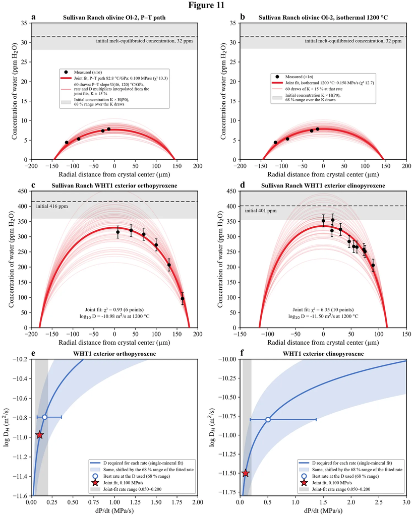

Figure 1.1: One continuous ascent at 0.100 MPa/s fits olivine and both pyroxenes together once the pyroxene diffusivities are slow. (a) Water in the host-scoria olivine Ol-2 with the joint fit on the magma P–T path (82.8 °C/GPa; red) and draws over the P–T slope (46–120 °C/GPa), partition coefficient and diffusivities (thin lines); (b) the same at a constant 1200 °C (0.158 MPa/s). (c, d) The WHT1 exterior opx and cpx with the joint fit (log10 D at 1200 °C −10.98 and −11.50 m²/s). (e, f) The pyroxene diffusivity each rate requires when the pyroxene is fitted alone (line and band), the best single-mineral rate (circle) and the joint fit (star); grey, the joint-fit rate range over the P–T slopes. MiMiC start; SIMS water with 1σ bars (Section 8.3, Section 17.7).

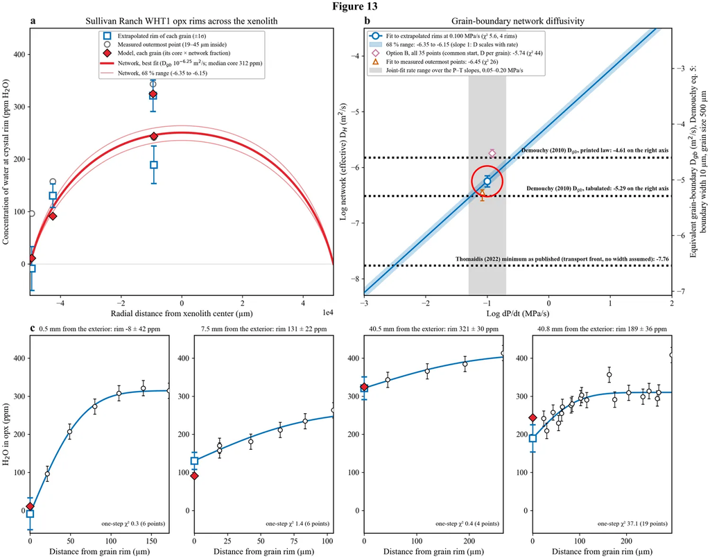

Figure 1.3: The melt’s water drop reached the WHT1 interior through a grain-boundary network with log10 D of about −6.25 to −5.75 m²/s at 0.100 MPa/s (work in progress). (a) Rim water across the xenolith: each opx grain’s extrapolated rim (squares, ±1σ), the measured outermost points (circles, 19–45 µm inside the grains) and the network fitted to the extrapolated rims at the end of ascent, scaled to the median opx core; diamonds are each grain’s prediction. (b) Network diffusivity against decompression rate (a fit at one rate lies on a slope-1 line) for the two standard fits, the extrapolated rims (circle and band) and option B, one common start with an opx diffusivity per grain (diamond), with the 2023-style fit to the measured outermost points (triangle), Demouchy et al. (2010) grain-boundary values and the Thomaidis (2022) minimum. (c) Each opx grain’s profile with its one-step fit and extrapolated rim. MiMiC start, P–T path 82.8 °C/GPa (Section 8.7, Section 17.9).

## 1.3 Extended abstract

What are all the conclusions and major results? They are grouped by the stages of the thesis, from the last event (Stage III) back to the source (Stage 0).

### 1.3.1 Stage III: after eruption (Chapter 7)

Cooling of bomb-sized xenoliths after eruption does not change the NAM water.

- Core concentrations are flat across intact xenoliths of different sizes, and the host’s olivine phenocryst profile survives, which limits any post-eruptive hold at high temperature to well under about 3.6 minutes.
- Olivine cores in the xenolith (SIMS dataset, Supplement Table S2: interior 6.89, exterior 5.95 ppm) match phenocryst cores (6.77 ppm), the thesis evidence that the host reset them. The thesis text read about 1.3× higher than the data; the data are unchanged.

### 1.3.3 Stage I: ascent in water-undersaturated magma (Chapter 9)

- Intact interior opx cores (about 411 ppm) are in equilibrium with 3.48–3.49 wt% melt H2O, close to the MiMiC start (3.549 wt%) and the CO2/Nb start (3.59 wt%). The opx traverses sit at two levels: two grains plateau near 300–320 ppm and only the deepest points reach 409–413 ppm. The rate model fits with the MiMiC start (joint χ² 20.6 on the path; it was 41 for the 2.72 wt% mixture start with the CO2/Nb-start fit (the mixture start shares the CO2 of the CO2/Nb start)); the offset is stated as uncertainty in the opx partition coefficient or in the starting H2O.
- Fe–Mg diffusion gives Ol-2 a residence time of 18.4 days (15.7–21.3) at 1250 °C in the final melt, and xenocrysts 0.15–3.0 days. The two localities (pit and roadside) were probably two magma pulses.
- Cpx cores hold 1.2–2.6× the H2O that recalibrated experiments predict. Wetter magmas carry wetter xenolith NAMs (SR, Vulcan’s Throne), drier magmas drier ones (Cima).

### 1.3.4 Stage 0 and implications (Chapter 10)

- No vestige of mantle water is demonstrated in these xenoliths: the interior cores record the host melt, as the thesis concluded. The cpx partitioning misfit is an open caveat.
- Published xenolith-NAM ascent rates assume a fixed zero boundary from entrainment, so they are upper bounds and not like-for-like with melt-based rates.
- The thesis’s accelerating-ascent picture (0.002 MPa/s deep, 0.2 MPa/s shallow) now reads 0.1 MPa/s in the upper crust; the deep rate is not recomputed.

### 1.3.5 Inputs and data quality (Chapter 4, Chapter 5, Chapter 6)

- The SR melt inclusions record primary melt batches (H2O follows Cl); their CO2 was largely lost before trapping (retained 9–54 % at CO2/Nb 239). Inclusion saturation pressures are 129–574 MPa, shallower than pickup at about 1.15 GPa.
- A total 1σ replaces the deposited combined uncertainty, which was about 0.58× the 1σ; six analyses fall below the detection limit.
- Two thesis table errors are corrected: GC2_ol4 carried GC2_ol3’s volatiles, and the Fig. 11 caption printed 0.009 ± 0.003 for the olivine partition coefficient 0.0009 ± 0.0003.

## 1.4 Chapter guide

- Chapter 2: the ranked list of changes, the problems with the 2023 methods and their fixes.
- Chapter 3: the fidelity question, the four stages on the P–T path, why SR.
- Chapter 4: localities, samples, SIMS and models in paper form.
- Chapter 5: results for water in olivine, cpx and opx.
- Chapter 6: melt-inclusion results and the starting melt.
- Chapter 7: Stage III, after eruption.
- Chapter 8: Stage II, the rate and how the signal entered the xenolith.
- Chapter 9: Stage I, reset of the NAMs, residence times, cpx partitioning.
- Chapter 10: Stage 0 and implications.
- Chapter 11: open questions for co-authors.
- Appendices: Chapter 12 (diffusion fits), Chapter 13 (melt-inclusion methods), Chapter 14 (degassing models), Chapter 15 (data quality), Chapter 16 (decisions, crosswalk, reproducibility).

Sources: `docs/ASCENT_RATE_SUMMARY_2026-10-22.md`, `docs/supplement/SUMMARY_WRITEUP_NOTES.md`, `data/supplement/summary_csv/`, `report/appendices/c-ch3-crosswalk.md`.

# 2 What changed since the thesis

Which differences between the 2023 chapter and the present analyses change the findings, and by how much? Table 2.1 lists the twelve largest, ordered by consequence for the conclusions. The sections after it explain the problems with the 2023 methods and how each was fixed, then list the new analyses and the new direction.

Table 2.1: The twelve largest changes since the thesis, most consequential first. Changes 1–5 alter the ascent rate or its interpretation; 6–7 bear on Stage 0; 8–12 are corrections.

| Rank | Change | Thesis (2023) | Now (2026) | Effect on the findings | Where |
| --- | --- | --- | --- | --- | --- |
| 1 | Temperature along the ascent | Isothermal, about 1200 °C | Straight P–T path from 1330 °C at 2.26 GPa; joint rate 0.100 MPa/s (0.050–0.200) | Every rate falls by 0.63–0.69× | Chapter 8 |
| 2 | Where the melt degasses | No water lost until below 150 MPa | Saturation 682 MPa (MiMiC start); half the H2O lost below about 55 MPa | H loss happens at 1110–1180 °C, not 1200 °C | Chapter 8 |
| 3 | Starting melt | GCB lava, 3.36 wt% H2O, 8,476 ppm CO2 | Published MiMiC melt, 3.549 wt% H2O, 8,529 ppm CO2 (CO2/Nb start, 3.59 wt%, 14,100 ppm, is the second scenario) | Rates about 10 % lower than with the CO2/Nb start; no stall needed at the central slope | Chapter 6 |
| 4 | Pyroxene diffusivities | A bracket “at the low end”; rates 0.69 (opx), 0.68 (cpx) MPa/s | Free D; log10 D −10.98 (opx), −11.50 (cpx); rates 0.161, 0.504 on the path | One ascent history fits all three minerals | Chapter 8 |
| 5 | Transport into the xenolith | Boundary log D −6 to −5.5; rims at the boundary value | That test fails (χ² 42 for 5 rims); network log D −6.25 to −5.75 (two standard fits) with lag | A fast pathway is required, not assumed | Chapter 8 |
| 6 | Cpx partitioning | Cores match experiments, D about 0.005–0.02 | Cores hold 1.2–2.6× the H2O the recalibrated fit predicts | Stage 0 check is open | Chapter 9 |
| 7 | Anchoring the start | Host magma 2.6 ± 0.5 wt% H2O | Interior opx cores imply 3.48–3.49 wt%; two core levels, 300–320 and 409–413 ppm | MiMiC start kept; K or start-H2O uncertainty stated | Chapter 9 |
| 8 | Uncertainty model | Combined uncertainty; olivine K prior SD 6× too narrow | Total 1σ; K ± 0.0003; detection limits per session | Rates less tightly constrained | Chapter 15 |
| 9 | Residence time | Stage I at least 100 min to about 6 days | Ol-2 18.4 d (15.7–21.3) in the final melt; xenocrysts 0.15–3.0 d | Two pulses at two localities | Chapter 9 |
| 10 | Literature comparison | Similar to Seguam 1977 (1.5×) and Cerro Negro | 1.0× Seguam; 3.4–11× Cerro Negro; each on its own model temperature | SR fast for a cinder cone, not exceptional | Chapter 8 |
| 11 | Olivine values and calibration | Cores 6–12 ppm (mean 9) | Cores 5.95–6.89 ppm on the revised calibration | Text values about 1.3× high; data unchanged | Chapter 5 |
| 12 | Table corrections | GC2_ol4 volatiles; Fig. 11 caption K | GC2_ol4 has none; caption reads 0.0009 ± 0.0003 | Inclusion set is 12 SR inclusions, not 13 | Chapter 15 |

The full 41-row comparison with the deposited chapter is in Chapter 16.

## 2.1 Problems with the 2023 methods and the fixes

What was wrong with the original analysis, and what replaced it? Seven problems matter.

**The pyroxene diffusivity bracket.** The 2023 fits bracketed the pyroxene diffusivity with laws at T ± 20 K. The upper cpx value in that bracket was extrapolated from Ferriss et al. (2016) to the tetrahedral Al of the WHT1 cpx; they publish laws for Kunlun diopside but no equation for the Al dependence. The cpx interior profiles were fit with the opx bracket, and the opx interior profile of GCB duplicated the WHT1 exterior profile. These diffusivities are faster than the fits now need, which made the pyroxene rates (0.69 and 0.68 MPa/s) disagree with olivine. Leaving D free gives opx −10.98 and cpx −11.50 in log10 m²/s at 1200 °C, matching slow natural-pyroxene values, and a joint χ² of 20.6 for 20 points.

**Isothermal 1200 °C.** The thesis modeled the whole ascent at 1200 °C. Along the P–T path the melt is at 1110–1180 °C where most H2O leaves, so the isothermal diffusivity is too high. The path rate equals an isothermal fit at about 1150 °C, the mean entrapment temperature of the SR inclusions.

**The degassing path start.** The 2023 path began from the GCB lava and implied no water loss until 150 MPa. The MiMiC start saturates at 682 MPa and loses half of its H2O only below about 55 MPa (CO2/Nb start: 922 and 63 MPa). It still holds 90 % of its H2O at 248 MPa (CO2/Nb start: 340 MPa). The 2023 path is reproduced exactly with its own inputs, so the difference is the start, not the code.

**SIMS combined uncertainty.** The deposited combined uncertainty (about 0.58× the 1σ) understated the error on each H2O value. A total 1σ combining calibration, counting and background replaces it, with detection limits and quantification limits per session. One cpx value (T1-216) was re-reduced on the opx line (129.70 against 131.26 ppm).

**The olivine partition coefficient prior.** The MATLAB prior was N(9, 0.5) × 10⁻⁴, with an SD 6× narrower than the ±0.0003 in the source paper. The mean is unchanged, and the wider range lets K move the rate as it should (K = 6 raises it 2.29×; K = 12 lowers it 0.58×).

**GC2_ol4 volatiles.** The 2023 inclusion table gave GC2_ol4 the volatiles of GC2_ol3 (H2O 2.39, CO2 3,136 ppm before correction). GC2_ol4 has no measured volatiles and is now excluded from the inclusion tables.

**The Fig. 11 caption.** The caption printed the olivine/melt partition coefficient as 0.009 ± 0.003, ten times the 0.0009 ± 0.0003 the scripts and text use.

## 2.2 New analyses

Which analyses did the thesis not have? The list below names them; each is developed in the chapter shown.

- A temperature path from the mantle start to the surface, with the rate warped onto it (Chapter 8, Chapter 12).
- A joint fit of olivine, opx and cpx with free pyroxene diffusivity, and a stall test (Chapter 8).
- Fe–Mg residence times with FORSTER for Ol-2 and the xenocrysts (Chapter 9).
- Coupled and nested grain-boundary fits, with buffering of exterior grains (Chapter 8).
- Original and modified MiMiC runs and the CO2/Nb estimate of undegassed CO2 (Chapter 6, Chapter 13).
- Alternative olivine laws, edge treatments and solubility models (Chapter 12, Chapter 14).
- A like-for-like comparison with published rates on each study’s own model temperature (Chapter 8).
- Detection limits and the total uncertainty for every H2O value (Chapter 15).

## 2.3 New direction

Where does the work go from here? The working hypothesis is that the host magma resets the NAMs, so the xenoliths record the ascent and not the mantle. The interior opx cores equal the MiMiC melt within about 2 %, and the data constrain how fast the host’s falling water activity is transmitted inward. Three consequences follow. Temperature along the path is part of the rate, not a footnote. The fits are joint, so one ascent must explain olivine, opx and cpx at once. The next tests are the partitioning of cpx, the CO2/Nb scenario and the starting level of the opx (Chapter 11).

Sources: `report/appendices/c-ch3-crosswalk.md`, `docs/ASCENT_RATE_SUMMARY_2026-10-22.md`, `docs/MODEL_CHOICES_2026-10-21.md`, `docs/supplement/SUMMARY_WRITEUP_NOTES.md`.

# 3 Introduction

Do hydrogen concentrations in xenolith minerals record the mantle, or the magma that carried them up? Peridotite xenoliths are used to estimate water in the lithospheric mantle, which matters for viscosity, melting and electrical conductivity. Laboratory work shows that H+ diffuses fast in olivine, cpx and opx, so a mineral can equilibrate with its carrier melt in hours. The thesis chapter asked whether that happens in nature, and tested it against the carrier magma’s own pressure, temperature, water content and degassing path. This report keeps that question and updates the answer.

## 3.1 The four stages on the 2026 path

How does the ascent divide into stages for H? The thesis used four, and Table 3.1 places them on the present P–T path. The magma leaves the last mantle equilibration at 1330 °C and 2.26 GPa (Plank and Forsyth 2016), picks up the xenolith at about 1.15 GPa, saturates at 682 MPa (MiMiC start; 922 MPa for the CO2/Nb start), and loses half of its H2O only below about 55 MPa (63 MPa) (Figure 3.1).

Table 3.1: The four stages on the 2026 P–T path. Stage I covers the whole ascent before water loss; the melt keeps at least 90 % of its H2O to 340 MPa. Quench temperatures are from inclusion olivine–glass pairs.

[output not shown]

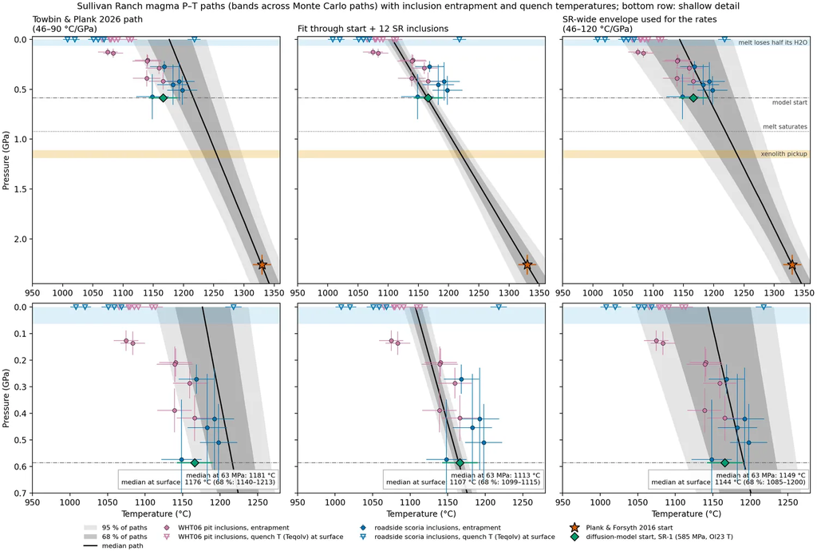

The stages differ in what they let a xenolith record. In Stage I the melt is undersaturated, nothing leaves it, and the NAMs track its H2O. In Stage II water leaves the melt and the boundary value drops, so the outer parts of the crystals lose H. The profile length scale gives the time, and so the rate. The next section explains why Sullivan Ranch can test this.

## 3.2 Why Sullivan Ranch can test it

What makes this cone a good test? The cone in the Uinkaret field north of the Grand Canyon supplies every part of the system at one eruption.

- **Xenoliths of different sizes:** bombs GCB1, WHT01 and WHT06 give olivine, cpx and opx, and WHT1 has grains at 0.5, 7.5 and 40 mm from the xenolith exterior.
- **Melt inclusions:** 12 SR inclusions give the melt’s H2O, CO2, trapping pressure and temperature.
- **A phenocryst, Ol-2:** a scoria olivine profiled along [100] gives the rate without a xenolith.

The samples come from two localities, a pit (WHT06, AZ18-06 inclusions) and a roadside (GCB1, WHT01, GC2 inclusions), probably two magma pulses. The path is kept SR-wide. Vulcan’s Throne and Cima, separate volcanoes with drier melts, are used only to test the cpx partitioning, never for the rate.

## 3.3 What each later chapter answers

How does the report move through the evidence? Chapter 4 describes the samples and models, and Chapter 5 and Chapter 6 give the NAM and melt-inclusion results. The discussion then follows the thesis order. Chapter 7 asks whether post-eruptive cooling matters. Chapter 8 gives the rate, the one history that fits three minerals, and how the signal entered the xenolith. Chapter 9 asks whether the minerals reset to the host and for how long. Chapter 10 asks what survives of the mantle water, and Chapter 11 lists what is not determined. The next chapter, Chapter 4, sets out how the data were measured.

Sources: `docs/plans/2026-10-29-report-review.md`, `report/appendices/c-ch3-crosswalk.md`, `data/supplement/summary_csv/`.

# 4 Samples and methods

Which samples were measured, how were water and major elements quantified, and which models turn the profiles into a rate? This chapter gives the samples (Table 4.1), the SIMS and EMPA methods (Table 4.2), the melt-inclusion treatment, and one paragraph on each model. Detail sits in the appendices: diffusion in Chapter 12, melt inclusions in Chapter 13, degassing in Chapter 14, and data quality in Chapter 15.

## 4.1 Localities and samples

The xenoliths and scoria come from three alkali-basalt cinder cones in the Uinkaret and Cima volcanic fields: Sullivan Ranch (SR), Vulcan’s Throne and Cima vent 16. SR is a cone south of Mt. Trumbull, sampled at two sites that probably record different magma pulses. The pit on the cone flank gave WHT06 and its scoria in place, and the roadside gave the weathered-out bombs WHT01 (also written WHT1) and GCB1. The roadside scoria holds Ol-2, the olivine whose profile sets the ascent rate. Vulcan’s Throne and Cima serve only as comparison volcanoes. All SR ascent-rate work uses SR alone. The SIMS dataset (Supplement Table S2) has 284 analyses, of which 270 are accepted.

Table 4.1: Two SR sites supply different parts of the story; Cima and Vulcan’s Throne are comparison volcanoes. Accepted analyses of 270 in the SIMS dataset, summed by locality; roadside scoria olivine and the melt-inclusion host scoria AZ09-GCB are listed in the text.

| Locality | Sample | Material | Phases | Accepted analyses |
| --- | --- | --- | --- | --- |
| SR pit (in place) | WHT06 (AZ18-06) | 3 cm xenolith bomb, its scoria, olivine-hosted inclusions | Cpx, opx; inclusions | 28 |
| SR roadside | GCB1 | Xenolith bomb sectioned along its shortest axis (about 2 cm transect) and its scoria | Olivine, opx, cpx | 90 |
| SR roadside | WHT01 | Xenolith bomb, about 10 × 21 cm; exterior and interior grains | Opx, cpx | 81 |
| Cima vent 16 | cip98 series, CA18-05x, lava-flow xenolith, MO10-16 scoria | Crushed clusters and bombs; scoria and inclusions | Olivine, opx, cpx | 51 |
| Vulcan’s Throne | VT85 series, scoria | Crushed clusters; scoria | Cpx | 20 |

The roadside scoria AZ09-GCB supplies the GC2 inclusions and a whole rock that is somewhat altered; the AZ09-UK01 lava is the Fe/Mg reference and the starting composition for the degassing paths. Bombs were chosen because they cool faster than xenoliths in lava; one lava-flow xenolith (CA18-Lavablock) tests the cooling rate. SR xenoliths were sectioned and polished as thick sections; Cima and Vulcan’s Throne xenoliths were crushed and clusters hand-picked, so their position in the xenolith is unknown. Samples were cleaned in acetone, toluene, distilled water and isopropanol baths, with only acetone-soluble plastics in preparation. The Sullivan Ranch material is the same cone that earlier work called Trumbull, GC2 and GCB; this report uses the name Sullivan Ranch.

## 4.2 Water by SIMS and NanoSIMS

**Calibration.** Each session has one line per phase from standards run in the same session: H2O (ppm) = slope × (16O1H/30Si × SiO2 wt%) + intercept, fitted by orthogonal-distance regression with bootstrapped uncertainties. The opx line uses the revised KBH-1 value of 202 ppm (±15; 217 before), which scales earlier opx concentrations by 0.93. Olivine is reduced on the opx line in all sessions. That puts the olivine data within about 12 % of the Withers (2012) olivine line, and the olivine/melt partition coefficient K = 9 ppm per wt% (Towbin et al. 2023) was built on the same scale, so data and K share one calibration. Placing olivine exactly on the Withers line would be equivalent to K of about 10.1 and would lower the isothermal Ol-2 rate from 0.155 to about 0.125 MPa/s. One NanoSIMS opx (T1-216, in Cima) was re-reduced on the opx line, giving 129.70 ppm against 131.26 ppm as deposited.

**Uncertainty.** Each analysis carries a total 1 sigma, the square root of the summed squares of the calibration term (the larger side of the 5–95 % calibration interval divided by 1.645), the counting error and the blank scatter beyond counting. It replaces the deposited combined uncertainty, which understated the calibration term. The median total 1 sigma is 0.34 ppm for olivine (SR olivine at most 0.59 ppm; the four Cima olivine about 2.9 ppm), 11 ppm for opx and 22 ppm for cpx. The four Ol-2 spots carry 0.31–0.43 ppm.

**Detection limits.** For each line, L_C (decision limit) and L_D (detection limit) follow Currie (1968) from the scatter of Suprasil blanks beyond counting statistics, and LoQ is the concentration at 20 % relative uncertainty (Table 4.2). Six accepted values lie below L_D (four Cima olivine and two Cima cpx from CA18-05x) and two lie between L_D and LoQ (SR scoria cpx xenocrysts). Every SR olivine value (2.2–8.7 ppm) is above the 2018 LoQ of 1.44 ppm.

Table 4.2: The 2018 detection limit is ten times lower than in 2013, so every SR olivine value is quantified. Calibration slopes and limits for the six lines applied to the SIMS dataset.

| Session | Line (applied to) | Slope (ppm per unit) | L_C (ppm) | L_D (ppm) | LoQ (ppm) |
| --- | --- | --- | --- | --- | --- |
| 6f 2013 | Opx (opx, Cima olivine) | 57 | 4.9 | 9.8 | 15.0 |
| 6f 2013 | Cpx | 78 | 6.7 | 13.3 | 20.4 |
| 6f 2018 | Opx (opx, all SR olivine) | 53 | 0.49 | 0.99 | 1.44 |
| 6f 2018 | Cpx | 74 | 0.68 | 1.38 | 2.54 |
| NanoSIMS 2020 | Opx | 126 | 7.6 | 17.1 | 21.8 |
| NanoSIMS 2020 | Cpx | 128 | 7.5 | 17.4 | 37.3 |

## 4.3 Electron microprobe

Major elements were measured on the Cameca SX100 at the American Museum of Natural History in 2018 (GCB1) and on the Cameca Tactis over several sessions from 2020 to early 2022. EMPA supplies the SiO2 used in the SIMS reduction, the Mg# and tetrahedral Al of the pyroxenes (used in the cpx partitioning test), and the olivine Fo profiles. Phases were assigned by composition (cpx CaO of at least 15 wt%; opx CaO below 3 wt% and MgO 28–37 wt%). Mg# is molar with all Fe as FeO. No usable EMPA exists for several Cima and Vulcan’s Throne grains and for the WHT06_2 xenolith, so those cpx have no tetrahedral-Al value.

## 4.4 Melt inclusions

**MiMiC.** MiMiC (Rasmussen et al. 2020) adds or removes host olivine until each inclusion is in Fe–Mg equilibrium with its host (Kd from Toplis 2005; Fe3+/FeT fixed at 0.2 for SR), then adds back the CO2 that the vapor bubble holds with a bubble-growth model. The published code takes the bubble CO2 volume from a Redlich–Kwong pure-CO2 fluid scaled by the CO2 mole fraction; two errors in it partly cancel. The production run replaces this volume with the Duan and Zhang (2006) H2O–CO2 mixture at MiMiC’s own vapor composition. For the SR inclusions the change adds 0 to 15 % to bubble CO2 and raises the saturation pressure with bubble CO2 (Pvbg) by 0 to 7.6 %, and it leaves every inclusion H2O unchanged. The inclusion tables use the production run. The P–T path keeps the base (published) MiMiC, because the two give the same path: a slope through the inclusions of 98.5 °C/GPa (68 % range 89.1–108.5) with the base run and 98.3 with the Duan and Zhang run, and entrapment temperatures differ by at most 1.2 °C. Other options, including a Fe-loss correction and other solubility models, are in Chapter 13.

## 4.5 Models

**Degassing path.** The path of melt H2O against pressure is a closed-system MagmaSat path at 1200 °C on the AZ09-UK01 lava composition (Fe3+/FeT 0.167). The primary start is the published MiMiC melt, 3.549 wt% H2O with 8,529 ppm CO2, which saturates at 682 MPa (Chapter 6). On this path the melt loses half its H2O only below about 55 MPa. The second scenario, SR-1 (the CO2/Nb start), is 3.59 wt% H2O with 14,100 ppm CO2; it saturates at 922 MPa and loses half its H2O below 63 MPa. Iacono-Marziano is the alternative solubility model and gives a lower saturation pressure (Chapter 14).

**P–T path.** Temperature falls along a straight line from 1330 °C at 2.26 GPa (Plank and Forsyth 2016) to the surface, with a slope drawn from U(46, 120) °C/GPa. This is equivalent to an isothermal fit at about 1150 °C, the mean SR entrapment temperature. The isothermal 1200 °C fit is kept as the simple case.

**Diffusion fits.** Pressure falls linearly in a one-dimensional slab whose rim holds the equilibrium H2O of the degassing melt (Chapter 12). The Bayesian fit returns a posterior median and 68 % range for the rate. Olivine uses the Ferriss et al. (2018) [100] law, D = 10^-5.4 exp(−130 kJ/RT) m²/s, with K = 9 ppm per wt%. Pyroxene K is anchored on opx: Novella et al. (2014) multiplied by 0.93 gives 117.7 ppm per wt%, and cpx K follows the measured cpx/opx core ratio. A temperature that falls along the path enters through a warped pressure, the integral of D(T)/D_ref over pressure, so the constant-D solver gives the variable-temperature result exactly and reproduces the isothermal fits when the ratio is 1.

**Joint fit.** One continuous ascent is fitted to Ol-2 and to the WHT1 exterior opx and cpx together, with the pyroxene diffusivities free. Stalls are tested against it.

**Xenolith exchange.** A nested model lets each WHT1 pyroxene exchange with a grain-boundary network of diffusivity D_gb whose water activity follows the melt at the xenolith exterior, with a boundary-drop factor g for each position. It is fitted to all five WHT1 traverses, with the D_gb activation energy set to 34 kJ/mol (Demouchy 2010).

The next chapter turns to what the SIMS data show in each mineral.

Sources: `data/supplement/summary_csv/` (Samples, Calibrations, EMPA, Melt_Inclusions); `docs/supplement/SUMMARY_WRITEUP_NOTES.md`; the deposited Chapter 3 Methods.

# 5 Results: water in olivine, cpx and opx

What do the SIMS data say about water in the xenolith minerals, mineral by mineral and volcano by volcano? Only accepted analyses are used (270 of 284; the 14 flagged or excluded rows are listed in the data workbook). Table 5.1 gives the ranges, and the sections below follow the thesis order: olivine, cpx, opx, then the contrast between volcanoes.

Table 5.1: Olivine holds a few ppm, pyroxene hundreds, and pyroxene rims are lower than cores. Accepted SIMS analyses by phase and setting. Cima olivine (four analyses, 1.4–6.5 ppm) and Cima opx (four, 35–130 ppm) are not shown; all four Cima olivine are below the detection limit.

| Phase | Volcano and setting | Analyses | Range (ppm) | Mean (ppm) | Core and rim |
| --- | --- | --- | --- | --- | --- |
| Olivine | SR, GCB1 xenolith | 33 | 2.2–8.7 | 5.8 | cores 6.4, rims 4.6 |
| Olivine | SR, scoria phenocrysts | 14 | 2.5–7.9 | 5.9 | cores 6.8, rims 3.6 |
| Opx | SR, xenoliths | 61 | 96–507 | 292 | rims 142–286, cores 290–359 |
| Cpx | SR, xenoliths | 75 | 206–488 | 349 | WHT1 exterior: rims 251, cores 318 |
| Cpx | Vulcan’s Throne, xenoliths | 15 | 264–594 | 421 | position not recorded |
| Cpx | Cima, xenoliths | 29 | 64–198 | 113 | position not recorded |

## 5.1 Olivine

Olivine holds 2.2–8.7 ppm in SR, almost all of it measured in 2018 on GCB1 and its scoria. The cores in the GCB1 xenolith interior hold 4.3–8.7 ppm (mean 6.9, n = 8) and the cores at the exterior 4.8–7.7 ppm (mean 6.0, n = 9). The scoria phenocryst cores hold 5.9–7.9 ppm (mean 6.8, n = 5). The interior and exterior cores overlap within their scatter, and both overlap the phenocrysts, so the cores across the xenolith and in the host magma have equilibrated to the same water content (Figure 5.1).

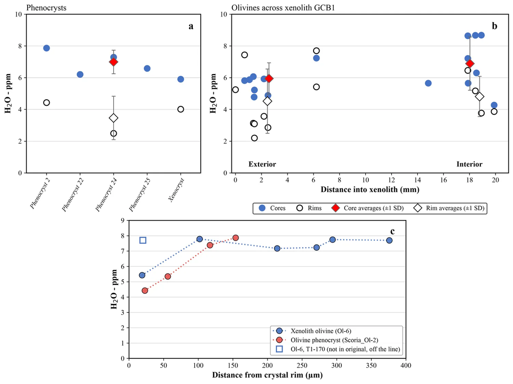

Figure 5.1: Olivine cores across GCB1 equal the host-scoria phenocryst cores, and rims are lower. (a) Phenocryst cores and rims; (b) xenolith olivine against distance into the xenolith, with means and 1 SD; (c) profiles of phenocryst Ol-2 and xenolith olivine Ol-6 from the rim inward.

Every olivine is zoned, with lower water in the rim. Xenolith rims average 4.6 ppm (n = 13) and phenocryst rims 3.6 ppm (n = 3), and the lowest rims, at the xenolith exterior and in phenocrysts, hold 2.2–3.6 ppm. Rims sit 1.8 ppm below cores in the xenolith and 3.2 ppm below in the phenocrysts, so the zoning is stronger in the phenocrysts, where the rim is closer to the melt. The two populations still share their core concentrations and the same zoning length scale of about 100 µm.

Ol-2 is the phenocryst whose profile sets the ascent rate (Chapter 8). Its four spots along [100] rise from 4.43 ppm at 23 µm from the rim to 5.34 at 56 µm, 7.38 at 117 µm and 7.87 at 154 µm, each with a total 1 sigma of 0.31–0.43 ppm. The profile drops by about 44 % over 150 µm, which is the signal that the diffusion fits explain. Ol-6, a xenolith olivine, drops from about 7.7 ppm in its interior to 5.4 ppm at 19 µm (Figure 5.1 c).

## 5.2 Clinopyroxene

The pit and roadside cpx overlap: the WHT06 cpx are not zoned at the resolution measured (cores 346 ppm, rims 368 ppm, two analyses each), while the roadside xenoliths differ in how much water their cpx hold, GCB1 being the wettest.

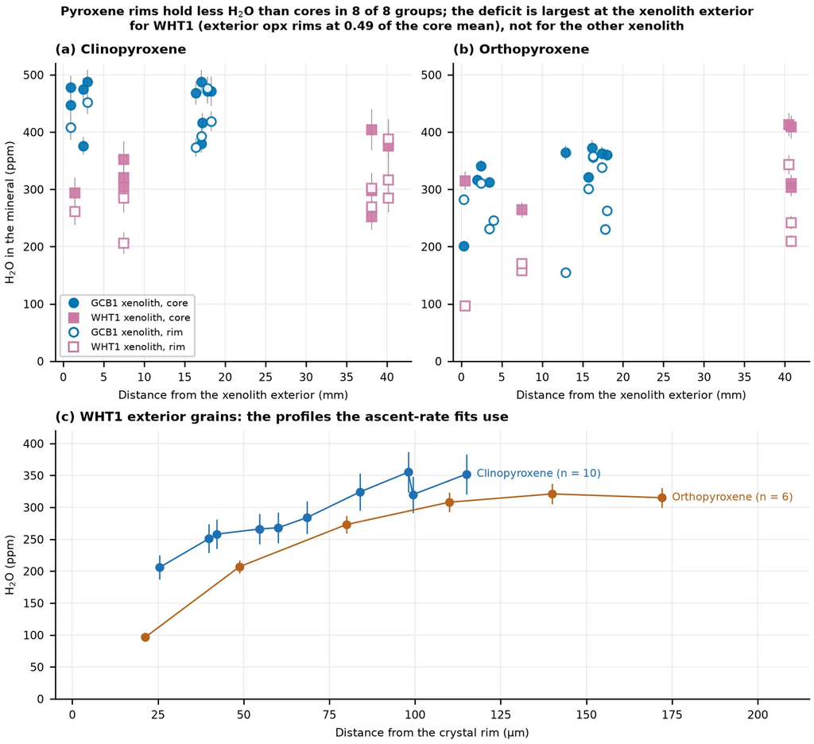

Figure 5.2: Pyroxene rims hold less water than cores in every group, and the deficit is largest at the WHT1 exterior (opx rims at 0.49 of the core mean). (a, b) Cpx and opx cores (filled) and rims (open) against distance from the xenolith exterior, GCB1 and WHT1. (c) The two WHT1 exterior profiles the rate fits use, against distance from the crystal rim.

## 5.3 Orthopyroxene

Opx water is similar to cpx water at the same xenolith, with most SR opx cores between 290 and 360 ppm. The pit xenolith WHT06_2 holds the highest value, 507 ppm, from a single analysis in one grain, so it is not treated as a typical core.

SR xenolith opx hold 96–507 ppm. In both xenoliths with opx traverses, the cores at the xenolith exterior hold less than those in the interior: 292 against 356 ppm in GCB1 and 290 against 359 ppm in WHT1. The two large interior WHT1 opx, about 40 mm from the exterior, reach 413 and 409 ppm at their deepest points. These values anchor the wet starting melt, but the other points of these grains sit lower, near 300–320 ppm (Chapter 9).

Zoning is stronger in opx than in cpx and spreads farther into the grain. The WHT1 exterior opx at 0.5 mm from the xenolith edge rises from 96 ppm at 21 µm from the rim to 315 ppm at 172 µm. The exterior opx at 7.5 mm rises from 158 ppm at 19 µm to 264 ppm at 105 µm. Exterior rims average 142 ppm in WHT1 against interior rims at 265 ppm. Water loss in opx therefore reaches about 100–170 µm into the grain, deeper than the 100 µm in cpx, and it is clearest at the xenolith exterior. Not every GCB1 opx shows it: the exterior opx rims there (268 ppm) sit only 24 ppm below the cores (292 ppm).

Opx and cpx in the same xenolith track each other. The cpx/opx core ratio is 1.38 in GCB1 and 0.97 in WHT1, so the two pyroxenes appear to share one reservoir. The olivine/opx core ratio in GCB1 is 0.018, so olivine holds far less water relative to pyroxene than the experiments would give at equilibrium, which fits olivine re-equilibrating with the melt after the pyroxenes (Chapter 8).

## 5.4 Between volcanoes

The three volcanoes differ in xenolith water. SR cpx (mean 349 ppm, 206–488) are about three times wetter than Cima cpx (mean 113, 64–198), and SR opx (292 ppm) are about 3.6 times wetter than the four Cima opx (81 ppm). The melts differ in the same direction: the best melt H2O is 3.55 wt% for SR (3.59 wt% with the H2O lost to the bubble) and 1.29 wt% for Cima (Chapter 6). Cima olivine is below the detection limit, so no olivine ratio is given.

Vulcan’s Throne breaks the simple pattern. Its xenolith cpx (264–594 ppm, mean 421) are wetter than SR’s and overlap GCB1, although its best melt, 2.29 wt%, is drier than SR’s. The cpx therefore do not scale with melt H2O across all three volcanoes: the cores hold 1.2 to 2.6 times the water the recalibrated experiments predict, with Cima closest to prediction and Vulcan’s Throne farthest. Wetter magmas still carry wetter xenolith NAMs between SR and Cima, and drier magmas drier ones; the Vulcan’s Throne excess is tested in Chapter 9. Scoria cpx phenocrysts are far drier than xenolith cpx at each volcano (Vulcan’s Throne 35–65 ppm; SR phenocryst cores 74 ppm), as expected for crystals grown from the degassed melt.

Analyses flagged as bad were not used (14 rows: 6 SR olivine, 4 SR opx, 3 SR cpx and 1 Cima cpx).

The profiles above say how water left the grains; the next two chapters give the melt it left for, starting with what the inclusions record (Chapter 6) and then the ascent that the olivine profile measures (Chapter 8).

Sources: `data/supplement/summary_csv/` (NAM_Volatiles, NAM_Summary, Magma_Models); the deposited Chapter 3 Results.

# 6 Results: melt inclusions and the starting melt

What do the melt inclusions record, and which melt should the ascent models start from? Twelve SR inclusions are used: five from the pit scoria (AZ18-06 Ol19, Ol21, Ol23, Ol35, Olxx), the Ol36 pair from the pit, and five from the roadside scoria AZ09-GCB (GC2_ol3, ol5, ol7, ol8, ol11). The sections below show what the inclusions record, how much CO2 the melt had already lost, how the two sites differ, and the starting melts built from them (Table 6.2).

## 6.1 What the inclusions record

The spread in inclusion H2O is a property of the trapped melts, not the result of H loss. H2O in the measured glass rises with Cl (r = +0.90) and S (+0.86) across the 12 inclusions and is not ordered by entrapment pressure (+0.29, p = 0.37; Figure 6.1). Degassing removes S before H2O and H2O before Cl, and Cl is so soluble in mafic melt that it seldom leaves until very low pressure, so a tight H2O–Cl correlation cannot come from degassing or from diffusive H loss. The simplest reading is batches: a wet, Cl- and S-rich, low-SiO2 melt and a drier, more siliceous one, either mixed or trapped separately. With ten main-group inclusions this is a lean, not a proof. A size test agrees: Ol21 should re-equilibrate 3.3 times faster than Ol23 if H were being lost through the olivine, yet their H2O (3.47 and 3.55 wt%) agree within 2 %.

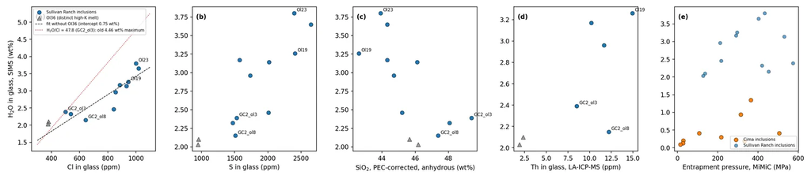

Figure 6.1: SR inclusion H2O rises with Cl and S and is not ordered by entrapment pressure, so its spread belongs to the trapped melts, not to H loss. H2O against Cl, S, SiO2 and Th for SR inclusions (grey triangles: the evolved Ol36 melt), and against entrapment pressure for Cima and SR.

Plotted together, the three volcanoes keep their separate fields (Figure 6.2). SR inclusions are wetter than Vulcan’s Throne’s, which are wetter than Cima’s. The Duan and Zhang bubble correction shifts bubble-corrected CO2 by only −2.8 to +14.8 % across 39 inclusions, so the pattern does not depend on the equation of state.

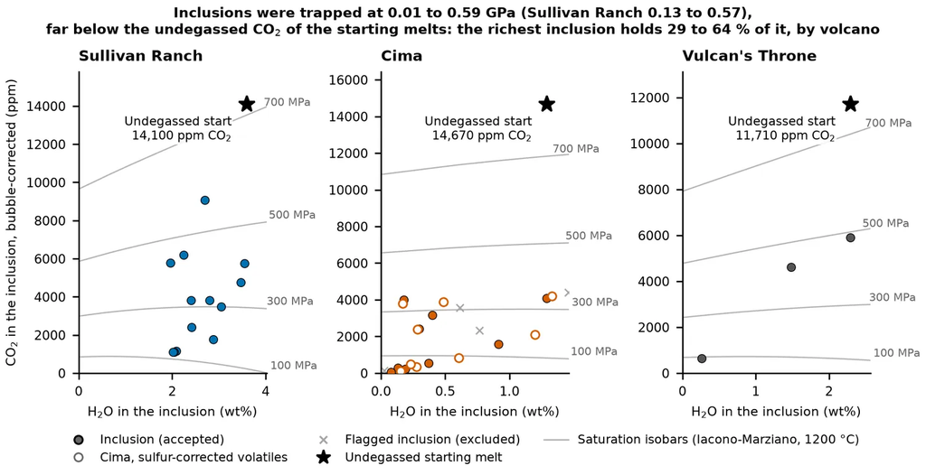

Figure 6.2: The inclusions were trapped at 0.01–0.59 GPa (Sullivan Ranch 0.13–0.57 GPa), far below the undegassed CO2 of the starting melts (stars): the richest inclusion holds 29–64 % of it. Bubble-corrected CO2 against H2O per volcano, production MiMiC, with Iacono-Marziano isobars; flagged Cima inclusions as crosses.

## 6.2 CO2 lost before trapping

Whether the CO2/Nb correction is worth making is a question for co-authors (Chapter 11). It moves the rate by about 10 %, because CO2 sets only where degassing starts, and the H loss that the profiles record happens below about 60 MPa. It matters for depth: the CO2/Nb 239 start saturates at 922 MPa, close to pickup, and the 505 start at 1,438 MPa, deeper than pickup.

## 6.3 The two localities

The roadside GC2 inclusions are drier than the pit inclusions at the same host Fo, lower in Cl and S, and trapped deeper (Table 6.1). H loss could lower H2O, but it cannot lower Cl and S, so the roadside inclusions are a different batch. Ol36 is a distinct evolved melt: its Fo 79 hosts, shallow pressures (129–138 MPa) and low Cl mark a degassed melt in the pit pulse. No inclusion samples the final roadside melt that the roadside olivine rims need (Fo 80.7–83), and Ol36 is more evolved than it.

Table 6.1: At the same host Fo the roadside inclusions are drier and lower in Cl and S than the pit’s, yet trapped deeper. H2O is corrected for crystallization (PEC); Cl and S are measured; Pvbg is the production saturation pressure with bubble CO2.

| Group | Host Fo | H2O (wt%) | Cl (ppm) | S (ppm) | Pvbg (MPa) |
| --- | --- | --- | --- | --- | --- |
| Pit: Ol19, 21, 23, 35, xx | 84.2–86.1 | 2.41–3.55 | 842–1018 | 1733–2647 | 212–433 |
| Pit: Ol36 (two inclusions) | 79.3–79.7 | 2.02–2.09 | 376–379 | 949–955 | 129–138 |
| Roadside: GC2 ol3, 5, 7, 8, 11 | 84.7–86.2 | 1.96–2.80 | 500–932 | 1471–2018 | 291–574 |

GC2_ol4 has no measured volatiles; the 2023 table carried GC2_ol3’s values for it, so it is left out. Cima inclusions 06b_a and 12_a stay in the workbook as flagged rows: 06b_a is too magnesian for its host, and 12_a has no host Fo.

## 6.4 The starting melt

The ascent models need the melt before it degassed, in the state the inclusions sample (Fo 84–87). Table 6.2 lists the candidates. The primary start is the published MiMiC melt as trapped; the CO2/Nb corrections follow as the second scenario. The caveat is that the MiMiC melt has already lost CO2 before trapping (46–91 % per inclusion), so the MiMiC path starts partly degassed (saturation 682 MPa, shallower than pickup at about 1.15 GPa); the CO2/Nb start is the case for an undegassed melt.

Table 6.2: The two CO2 starts differ by 8 % in the Ol-2 rate (about 10 % in the joint fit); the mixture is 12 % above the CO2/Nb start. Isothermal 1200 °C rates with MagmaSat saturation pressures; on the P–T path the MiMiC start gives 0.093, the CO2/Nb start 0.101 and the mixture 0.113 MPa/s (the mixture shares the CO2 of the CO2/Nb start, so it is compared with that start).

| Start | H2O (wt%) | CO2 (ppm) | What it assumes | MagmaSat saturation (MPa) | Ol-2 rate, isothermal (MPa/s) |
| --- | --- | --- | --- | --- | --- |
| Published MiMiC, as trapped (primary, used) | 3.549 | 8,529 | Ol23 H2O (PEC only) with the CO2 of GC2_ol7 (Rasmussen et al. 2020, base run); CO2 already partly degassed | 682 | 0.143 (0.92× the CO2/Nb start) |
| CO2/Nb 239 (SR-1, second scenario) | 3.59 | 14,100 | Ol23 H2O plus the H2O lost to its bubble; CO2 = 239 × Nb 59 ppm | 922 | 0.155 |
| Production MiMiC (SR-3) | 3.55 | 9,080 | As the published run with the production inclusion values | 708 | 0.144 |
| CO2/Nb 505 (SR-2) | 3.59 | 29,800 | As SR-1 with the ocean-island ratio; deeper than pickup | 1,438 | not run |
| Erupted-bulk mixture (SR-6) | 2.72 | 14,100 | H2O from the H2O–SiO2 relation at the lava SiO2 and from H2O/Ce | 921 | 0.174 |

**CO2/Nb (second scenario).** SR-1 adds the back-calculated bubble H2O (0.04 wt%) to Ol23 and takes CO2 from CO2/Nb 239, giving 3.59 wt% (3.37–3.76) and 14,100 ppm. The wet end falls to 3.34 wt% if a Fe-loss correction is applied. The MiMiC start was refit and gives 0.093 MPa/s on the P–T path against 0.101 for the CO2/Nb start.

**Mixture.** The erupted-bulk mixture of 2.72 wt% (2.63–2.80) is the main sensitivity case, close to the wettest roadside inclusion (GC2_ol5, 2.80 wt%). A dry batch (GC2_ol3, ol8, ol11) holds 2.20 wt% (1.96–2.40).

The MiMiC start is supported by more than the inclusions. If the host magma reset the xenolith pyroxenes, the intact WHT1 opx cores (about 411 ppm) record the melt they equilibrated with, and the opx-anchored K (117.7 ppm per wt%) gives 3.48 wt%, within 2 % of the MiMiC start (3.549), within 3 % of the CO2/Nb start and well above 2.72. The joint rate fit with the MiMiC start has a chi-square of 20.6 on the path, against 41 for the mixture with the CO2/Nb-start fit. The opx plateaus near 300–320 ppm complicate this, because they equal the mixture with the same K (Chapter 9).

Where the inclusion values come from matters less than it may seem. The production and the published MiMiC change every rate by 1.4 % or less, because the saturation pressures differ by a few percent and H loss happens at low pressure. The 2026 input changes (revised pit SIMS and a corrected Ol36_2 CO2) move the pyroxene rates by up to 4.4 %, more than the code does (Chapter 13). The choice between the two CO2 starts moves the rate by about 10 % and the mixture by up to 21 %, more than either.

The melt that the models start from is now fixed, and the next chapters use it: Chapter 7 covers the eruption and Chapter 8 the ascent in degassing magma.

Sources: `data/supplement/summary_csv/` (Melt_Inclusions, Magma_Models, Trace_Elements); `docs/supplement/SUMMARY_WRITEUP_NOTES.md`; `data/original_volatiles_2026/`; `results/decompression/mimic_compare/`.

# Discussion: the stages of ascent

# 7 Stage III: after eruption

Could a hold at the surface, or the cooling of a bomb, have made the water profiles we use for the ascent rate? The answer is no for the rate, and probably no for the xenolith water contents. Stage III is placed first because it is the last process that could have changed the minerals, and it has to be excluded before the earlier stages are read from them.

## 7.2 How long a hold would the profiles allow

A hold or a cooling ramp acts as extra time at the eruption temperature. For cooling at a constant rate $c$ from 1200 °C, the time-equivalent hold at 1200 °C is $R T^2/(E_a c)$, with $R$ the gas constant, $T$ the starting temperature in kelvin and $E_a$ the activation energy of the diffusivity. Table 7.1 gives the result for the three minerals. Even at 1 K/s the equivalent hold is 2 to 3 minutes, and at 10 K/s it is 11 to 18 seconds.

Table 7.1: Cooling at 10 K/s or faster is equivalent to a hold of under 20 s at 1200 °C, far below the 3.6-minute olivine reset time. Time-equivalent hold at 1200 °C for each mineral, for constant cooling from 1200 °C; activation energies are the ones in the column heads.

[output not shown]

The direction of the error matters as well as its size. A post-eruptive hold lowers every apparent rate relative to the true one, because the profile has had extra time to diffuse. It cannot make the ascent look faster, and it cannot explain why the pyroxenes gave faster rates than olivine when published diffusivities were used. The joint fit in Section 8.3 resolves that disagreement through the pyroxene diffusivities, so no hold is needed.

With the surface excluded as the source of the profiles, the next question is what the profiles say about the final ascent in the degassing magma (Chapter 8).

Sources: `docs/ASCENT_RATE_SUMMARY_2026-10-22.md` (post-eruptive cooling table), `report/chapters/06-ascent-rates.md` (reset times), the thesis Discussion (bomb size and cooling).

# 8 Stage II: final ascent in degassing magma

What does the water zoning in the olivine phenocryst and in the xenolith pyroxenes say about the last stretch of the ascent, and how did that signal get into the xenolith? This chapter answers it in seven steps. We first find where the melt loses its water, then fit the decompression rate to the olivine phenocryst Ol-2 with temperature falling along the magma P–T path. We then show that one ascent history fits olivine, orthopyroxene (opx) and clinopyroxene (cpx) together, rank the choices that move the rate, test the constant-rate and starting-CO2 assumptions, place Sullivan Ranch (SR) among published eruptions, and finally ask how the degassing signal travelled into the xenolith. Stage II is the part of the ascent where the host melt exsolves most of its water and the mineral rims lose water in response.

## 8.1 Where the melt loses its water

Over what pressure range does the SR melt actually lose its H2O, and so over what range can the mineral rims record it? The answer fixes which part of the ascent the profiles can resolve.

The starting melt is the published MiMiC melt (Rasmussen et al. 2020, base run: 3.549 wt% H2O from inclusion Ol23, 8,529 ppm CO2 from GC2_ol7; Chapter 6). MagmaSat in a closed system saturates this melt at 682 MPa. The melt then loses little water for a long way: it still holds 90 % of its H2O at about 248 MPa, 1.86 wt% at 60 MPa and half of it (1.77 wt%) at 55 MPa. Three quarters is gone by about 16 MPa, and at 10 MPa only 0.70 wt% remains, 20 % of the start. Most of the water therefore leaves in the last 55 MPa. At the joint-fit rate of 0.100 MPa/s (below), those 55 MPa take about 9 minutes, against about 3.2 hours for the whole interval from the 1.15 GPa pickup pressure to the surface at the same constant rate. The caveat is that this CO2 is the melt as trapped: the inclusions had already lost 46–91 % of their CO2, so the MiMiC path starts partly degassed, shallower than xenolith pickup. The second scenario, the CO2/Nb start (3.59 wt% H2O, 14,100 ppm CO2, CO2/Nb 239 × Nb 59 ppm), saturates at 922 MPa and loses half its H2O below 63 MPa; it is the case for an undegassed melt and is developed below as an option.

The shape of the path depends on the solubility model more than on the start. At 10 MPa, MagmaSat gives 0.67 wt% and Iacono-Marziano 0.92 wt% for the CO2/Nb start (SR-1), and the olivine rate on the Iacono-Marziano path is 0.086 MPa/s, 0.55 times the MagmaSat rate (both isothermal at 1200 °C, CO2/Nb start); the MiMiC start would scale both by about the same factor. We use MagmaSat as the primary model and treat Iacono-Marziano as a sensitivity case, because only the isothermal olivine fit has been run on it. The other degassing choices move the shallow path little. Open-system instead of closed-system degassing leaves the melt 0.05 to 0.07 wt% wetter at 10 MPa. Starts from 2.2 to 3.6 wt% H2O differ by 0.04 to 0.08 wt% there. Evaluating solubility at the path temperature changes every rate by 3 % or less (Chapter 14).

Figure 8.1 shows where along this path the melt-equilibrium value of each pyroxene falls below the measured rims. Ten of the twelve exterior rims cross it below 126 MPa, and the WHT1 rims between 13 and 116 MPa; the outermost WHT1 opx rim (96 ppm) is reached only at 13 MPa. The two GCB1 cpx rims sit above the starting level and never cross. The rims therefore record the shallow part of the path, below about 125 MPa, where the melt loses most of its water.

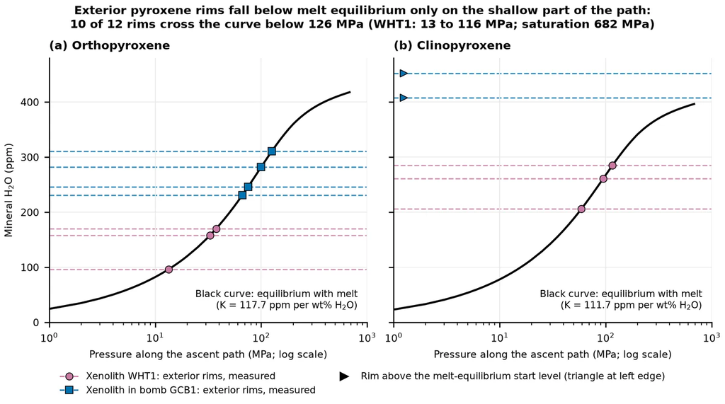

Temperature enters because the path from the 1330 °C, 2.26 GPa mantle start (Plank & Forsyth 2016) cools as the magma rises. With the median slope of 82.8 °C/GPa the path is at 1147 °C where the melt has lost half its H2O (55 MPa) and 1142 °C at the surface. Both are well below the 1200 °C used in earlier isothermal fits. The next section shows what that does to the rate.

## 8.2 The decompression rate from Ol-2 on the P–T path

What decompression rate does the olivine phenocryst Ol-2 give once temperature follows the magma P–T path instead of staying at 1200 °C? Ol-2 is the one profile that sits fully in the melt, so it sets the absolute rate.

Ol-2 comes from the GCB1 roadside scoria and is normally zoned from a Fo 88 core plateau to Fo 84 at the rim. Its H2O profile of four points (4.4 to 7.9 ppm, outermost point 23 µm from the edge) runs along [100], the same line as its electron-microprobe traverse. We fit it with the Ferriss et al. (2018) [100] diffusivity, $D = 10^{-5.4}\exp(-130\ \mathrm{kJ}/RT)$ m²/s ($10^{-10.0}$ m²/s at 1200 °C), and the Towbin et al. (2023) olivine/melt partition coefficient K = 9 ppm per wt%. The boundary follows the closed MagmaSat path from the MiMiC start, and the fit uses the Bayesian grid posterior of the earlier work (Chapter 12).

Variable temperature adds no new solver. For continuous ascent the profile depends on time only through $\int D\,dt = (D_{ref}/v)\int r\,dP$, where $r = D(T)/D(1200\ °\mathrm{C})$. A constant-diffusivity fit run on the warped pressure $P_w = \int_0^P r\,dP'$ therefore gives the variable-temperature solution, and its rate is the true ascent rate. With $r = 1$ the fits reproduce the isothermal ones exactly, and a direct implicit solver agrees with the warped model to 0.02 wt%, the same difference the two solvers show at 1200 °C. The path is a straight line from the mantle start with a slope drawn uniformly from 46 to 120 °C/GPa. That envelope spans the Towbin & Plank (2026) range and a Monte Carlo line through the start and the 12 SR melt inclusions (98 °C/GPa, 68 % range 89 to 109).

The result is 0.093 MPa/s (68 % range 0.055 to 0.154), or about 3.4 m/s at 2,800 kg/m³. That is 0.65 times the isothermal 1200 °C fit (0.143 MPa/s, 0.108 to 0.193), and 0.62 times the 2023 thesis fit (0.151 MPa/s), which is itself within 6 % of the new isothermal value. With the CO2/Nb start the same fit gives 0.101 MPa/s (0.060 to 0.167), 0.65 times its isothermal 0.155. Figure 8.2 shows how the rate depends on the path slope, and Table 8.1 gives the simple and best rates for all three profiles.

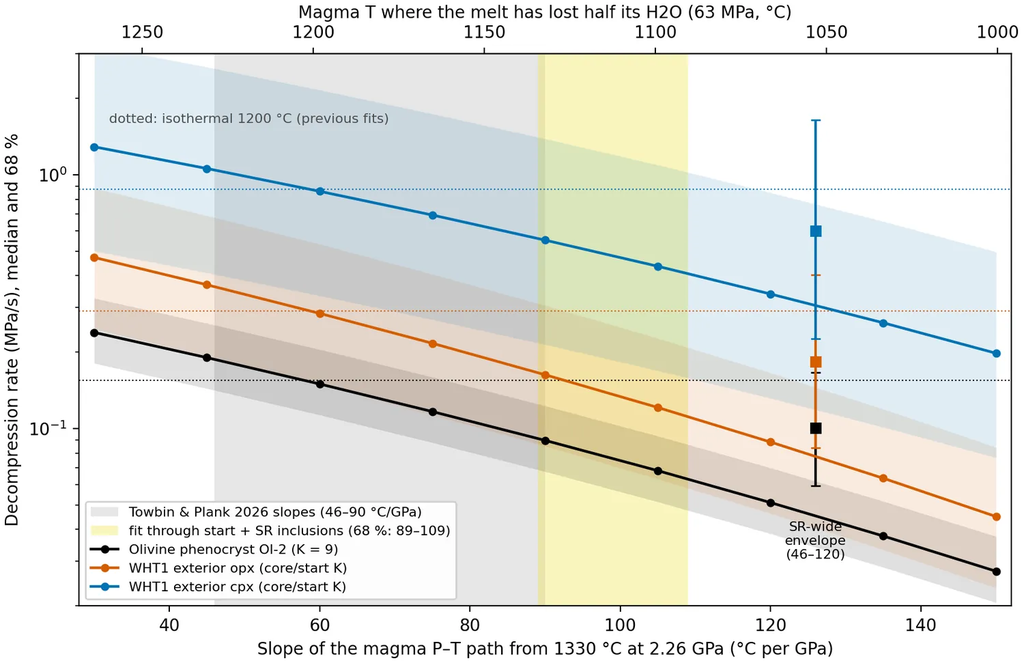

Figure 8.2: The P–T path lowers every rate by nearly the same factor, so it moves the absolute rate but not the disagreement between minerals. Decompression rate (median, 68 % band) against the slope of the magma P–T path for Ol-2 and the WHT1 exterior opx and cpx. Dotted: isothermal fits. Squares: the 46 to 120 °C/GPa envelope.

Table 8.1: The P–T path slows the olivine rate to 0.65 times and the pyroxene rates to 0.63 to 0.69 times the isothermal fit. Rate in MPa/s, median (68 % range), MiMiC start (CO2/Nb start: 0.101, 0.179, 0.562 on the path); pyroxenes use published diffusivities and the opx-anchored K.

| Profile | 2023 thesis fit | Simple: isothermal 1200 °C | Best: P–T path | Best ÷ simple |
| --- | --- | --- | --- | --- |
| Olivine Ol-2 (host scoria, 4 points) | 0.151 | 0.143 (0.108–0.193) | **0.093 (0.055–0.154)** | 0.65 |
| Opx WHT1 exterior (6 points) | 0.690 | 0.256 (0.128–0.508) | 0.161 (0.071–0.363) | 0.63 |
| Cpx WHT1 exterior (10 points) | 0.678 | 0.728 (0.278–1.86) | 0.504 (0.184–1.37) | 0.69 |

The cooling path is the largest single shift in the rate, and it lowers it. The reason is that the melt loses most of its water below about 60 MPa, where the path is at 1100 to 1180 °C and the isothermal fit overstated the diffusivity. A path through the SR inclusions (98 °C/GPa, the coolest family) gives 0.070 MPa/s (0.050 to 0.099), 0.49 times the isothermal rate, and the Towbin & Plank (2026) slopes (46 to 90 °C/GPa) give 0.120 (0.082 to 0.176), 0.84 times. The SR-wide envelope between them gives the 0.65 headline factor. The path rate equals an isothermal fit at about 1150 °C, which is also the mean entrapment temperature of the SR melt inclusions.

Every mineral slows by almost the same factor because their activation energies are similar (olivine 130, opx 144 and cpx 115 kJ/mol). The path therefore does not change the disagreement between minerals. With published pyroxene diffusivities the opx rate is 1.7 times and the cpx rate 5.4 times the olivine rate on the path. The change from the 2023 values for the pyroxenes (opx 0.690 to 0.256, cpx 0.678 to 0.728 isothermal) comes mostly from the 2026 degassing path, which keeps more water late, and from the opx-anchored K (117.7 ppm per wt%, against the 2023 prior of 90): with the 2023 diffusivity brackets these alone moved the opx rate about 2× down and the cpx rate about 1.4× up. The pyroxene disagreement is resolved in the next section through the diffusivities, not through the history.

Two checks on the olivine edge treatment leave the rate where it is. Widening the prior on the final pressure from 0–5 to 0–200 bar moves the isothermal rate only within 0.143 to 0.152 MPa/s (run on the CO2/Nb start, 0.155 to 0.164 MPa/s, and scaled by 0.92). A two-population model, with mobile and trapped H as in Barth-type edge locking, fits Ol-2 only if the trapped H exchanges within about 10 s, and it then reduces to an effective diffusivity; slow edge locking cannot remove the roughly 75 % of its H that Ol-2 lost. With the absolute rate set by olivine, the pyroxenes can be added to the same history.

## 8.3 One ascent history fits olivine, opx and cpx

Can a single continuous ascent explain the water profiles of olivine, opx and cpx together, once the pyroxene diffusivities are allowed to differ from the 2023 values? It can, and the diffusivities it needs are those of slow natural pyroxenes.

The joint fit uses Ol-2 (4 points), the WHT1 exterior opx (6) and the WHT1 exterior cpx (10), 20 points in all. The olivine diffusivity is fixed at the Ferriss [100] law, and the opx and cpx diffusivities are free. The history is either continuous ascent or a fast ascent to a stall, a hold of 0 to 10 minutes, and a final ascent. We also ran the 2023 method on the pyroxenes: each profile gives the pyroxene diffusivity it needs for the olivine rate, with a wide flat prior, and the joint fit agrees with it (Chapter 12).

With the 2023 pyroxene diffusivities held fixed the best joint χ² was 150 to 500 for 20 points, and the cpx carried most of the misfit. With the diffusivities free, the continuous isothermal ascent gives χ² 20.0 and the headline fit on the P–T path gives 20.6 (Table 8.2). That path fit puts the joint rate at **0.100 MPa/s**, with a range of 0.050 to 0.200 over the slope envelope of 120 to 46 °C/GPa. It is 1.1 times the olivine-only value (0.093 MPa/s) and 0.63 times the isothermal joint rate (0.158 MPa/s), so adding the pyroxenes changes the olivine answer by about a tenth. Olivine carries 13.3 of the 20.6 χ² units, cpx 6.3 and opx 0.9. The olivine profile alone, with its four points, reaches χ² 6.0 in its best isothermal fit on its own (CO2/Nb start), so the joint fit costs olivine some fit quality to match the pyroxenes.

Table 8.2: One continuous ascent fits all three minerals in every temperature scenario, with unchanged pyroxene diffusivities. Joint fit, MiMiC start (CO2/Nb start at 82.8 °C/GPa: 0.112 MPa/s, χ² 19.5), D in m²/s; a positive last column means the best stall fits worse.

| Temperature | Final rate (MPa/s) | χ², 20 points | log10 D opx at 1200 °C | log10 D cpx at 1200 °C | Best stall minus continuous (Δχ²) |
| --- | --- | --- | --- | --- | --- |
| Isothermal 1200 °C | 0.158 | 20.0 | −10.96 | −11.45 | +0.15 |
| P–T path, 46 °C/GPa | 0.200 | 22.0 | −10.96 | −11.43 | −1.63 |
| **P–T path, 82.8 °C/GPa (median)** | **0.100** | **20.6** | −10.98 | −11.50 | +0.15 |
| P–T path, 120 °C/GPa | 0.050 | 20.4 | −10.95 | −11.54 | +3.57 |

The pyroxene diffusivities at 1200 °C stay at $10^{-11.0}$ m²/s for opx and $10^{-11.5}$ m²/s for cpx whichever temperature treatment is used, because the published laws shift with temperature by the same factor as the fit. Figure 8.3 compares them with published laws. The opx value (−10.98) is within 0.12 log units of the Carpenter (2003) [100] law for San Carlos enstatite (−11.10). The cpx value (−11.50) lies at the slow end of the published cpx laws, between the natural Cr-diopside laws and the slowest Kunlun diopside laws of Ferriss et al. (2016): the nearest faster law is their 3540 cm⁻¹ band (−11.31, 0.19 log units faster), then the slow natural Cr-diopside laws (Ingrin et al. 1995, −11.12; Hercule & Ingrin 1999 uptake, −11.17), about 0.35 log units faster. It is about 7 times faster than the Ferriss et al. (2016) bulk-H law for Kunlun diopside. That suits the SR pyroxenes, which carry 3.3 to 3.9 wt% Al2O3 and Cr-bearing diopside. The faster laws for Al-poor enstatite (Demers-Roberge et al. 2021, −10.21 to −9.75) would need an olivine rate 7 to 20 times faster.

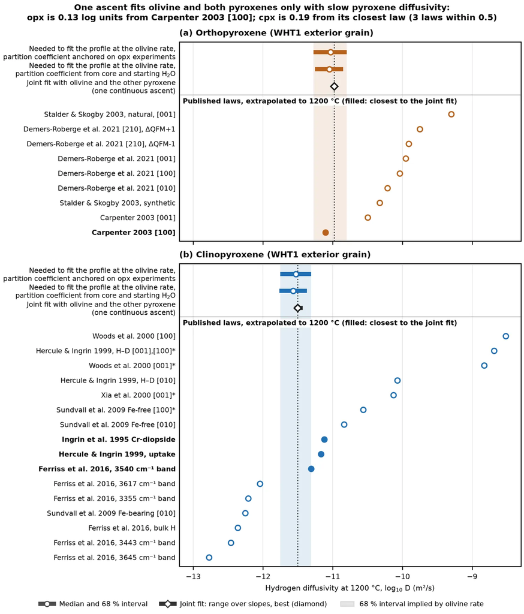

Figure 8.3: Only slow laws for natural, Al- and Cr-bearing pyroxene match the diffusivities that the olivine rate and the joint fit require. Implied log10 D at 1200 °C of opx and cpx from the olivine rate (circles: median; bars: 68 % and 95 %) and from the joint fit (diamond), against published laws evaluated at 1200 °C.

The 2023 cpx bracket is faster than these fits need. Its upper bound, $10^{-6.71}\exp(-100\ \mathrm{kJ}/RT)$, was the thesis estimate for a cpx with 0.07 tetrahedral Al, extrapolated from Ferriss et al. (2016). They publish laws for Kunlun diopside but no equation for the dependence on Al; the estimate’s prefactor matches their 3540 cm⁻¹ band law (log D0 −6.7) and its activation energy their bulk-H law (100.4 kJ/mol).

The exterior opx and cpx are not a like-for-like pair, and this pushes the cpx rate up. The modeled opx sits 0.5 mm from the xenolith exterior, the modeled cpx 7.5 mm (±2 mm) in. The opx rims across WHT1 show that the melt’s water drop reached that depth only in part. Rim/core is 0.31 at 0.5 mm and 0.60 at 7.5 mm, where an opx shares the cpx’s position, and 0.51 to 0.83 at 40 mm. The exchange fit puts the boundary drop at 7.5 mm at 71 to 83 % of the melt’s by the end of ascent (Section 8.7).

A boundary that drops less than the melt leaves the grain wetter than a melt boundary predicts. A cpx fit with the melt as its boundary therefore needs less time and returns a faster rate, so position pushes the cpx in the observed direction. The size is modest. On the grain-boundary boundary the implied cpx diffusivity moves by 0.03 to 0.06 log units, about 1.1 times on the rate. At the strongest buffering the cpx profile allows it moves by 0.35 log units, 2.2 times. That covers part of the 5.4-fold gap between the cpx-only and olivine rates, and the rest still needs the slow cpx diffusivity. Position is also not the only control on cpx loss. The second exterior cpx, 1.45 mm from the exterior, has no rim gradient: it is flat at 260 to 310 ppm, 0.67 to 0.80 of the intact cores, across its whole 130 µm traverse. It either lost water throughout or started lower. The exterior opx is effectively unbuffered. Buffering makes a pyroxene-only rate too fast, so the implied diffusivities are, if anything, lower bounds.

## 8.4 What moves the rate

Which modeling choices change the olivine rate, and by how much? The answer ranks the uncertainties that could change the headline rate and shows which of them we have excluded.

Table 8.3 lists the choices, sorted from the largest increase to the largest decrease. The factors are relative to the isothermal CO2/Nb-start rate of 0.155 MPa/s (the MiMiC start gives 0.143, a factor of 0.92), and the path rows apply to the best fit. The two rows from Section 8.5 are relative to the CO2/Nb path rate (0.101 MPa/s). The factors were computed on the CO2/Nb start; because every rate scales by about the same 0.92 with the MiMiC start, the factors carry over. Three groups stand out.

- **Choices that lower the rate:** the diffusion temperature (0.49 to 0.84 times) and the solubility model (Iacono-Marziano, 0.55 times).
- **Choices that can raise it by factors of 2 to 4:** the olivine diffusivity law and the olivine partition coefficient K. The wrong crystal axis would lower it by factors of 16 to 32.
- **Choices that move it little:** the starting H2O, the solubility temperature and the melt-inclusion software version (12 % or less). A higher starting CO2 raises the rate by up to a third.

If the ascent accelerated toward the surface, the rate the profile records over the last 60 MPa falls by up to 0.6 times.

Table 8.3: Diffusion temperature, olivine law and K, and the solubility model move the Ol-2 rate most; the starting melt (about 8 %) and software version move it little. Factors relative to the isothermal CO2/Nb-start fit (0.155 MPa/s); CO2 and acceleration rows relative to the CO2/Nb path fit (0.101 MPa/s).

| Choice | Change | Factor on the Ol-2 rate | Fit | Status |
| --- | --- | --- | --- | --- |
| Barth et al. (2023) Fo 90 law, start of run | Ferriss [100] to Barth start-of-run | 4.14 | isothermal | sensitivity |
| Barth et al. (2019) Fo 80 law | Ferriss [100] to Barth Fo 80 | 3.78 | isothermal | sensitivity |
| Olivine/melt K = 6 | K = 9 to 6 | 2.29 | isothermal | sensitivity |
| Higher starting CO2, 2.98–3.60 wt% | 1.41 wt% to 2.98 or 3.60 wt% CO2 | 1.23–1.33 | path | sensitivity |
| Starting melt, MiMiC (primary) | SR-1 (CO2/Nb) to published MiMiC | 0.92 | isothermal and path | adopted |
| Mixture start, 2.72 wt% H2O | SR-1 to SR-6 | 1.12 | isothermal | sensitivity |
| Solubility at path T, or published MiMiC | MagmaSat 1200 °C to along T(P); production to published MiMiC | 0.97–1.01 | path, isothermal | sensitivity |
| Short stall (1–3 min) | continuous ascent to stall | 0.65–1.15 | isothermal | sensitivity |
| Ascent accelerating 2–5× below 60–200 MPa | constant to accelerating ascent | 0.60–0.96 (last 60 MPa); 0.21–0.56 (deep) | path | sensitivity |
| P–T path, Towbin & Plank (2026) slopes | isothermal to 46–90 °C/GPa | 0.84 | path | sensitivity |
| **P–T path, SR-wide 46–120 °C/GPa** | isothermal to median 82.8 °C/GPa | **0.65** | path | adopted |
| Olivine/melt K = 12 | K = 9 to 12 | 0.58 | isothermal | sensitivity |
| Iacono-Marziano solubility | MagmaSat to Iacono-Marziano | 0.55 | isothermal | sensitivity |
| P–T path through the SR inclusions | isothermal to 98 °C/GPa | 0.49 | path | sensitivity |
| Ferriss law along [010] or [001] | measured [100] axis to a different axis | 0.03–0.06 | isothermal | ruled out |

Some candidate explanations of a fast rate are excluded. The profiles run along [100], so crystal orientation cannot supply the 16-to-32-fold change the other axes would imply. Deep stalls of 10 minutes or more make the pyroxenes look slower than olivine. The cooling path slows the rate rather than speeding it. The Barth et al. laws describe dehydration of Fo 90 and Fo 80 olivine (their start-of-run and end-of-run versions differ by a factor of 5), and we keep them as sensitivity cases. On profile uncertainty, we keep the fixed 2023 uncertainties; a data-estimated uncertainty, with the calibration error carried in K, moves every rate by 8 % or less. The spot-to-spot uncertainty is rejected for both pyroxenes because they scatter two to four times more than it implies.

Two choices deserve a plain statement. First, the olivine K of Towbin et al. (2023) was built on the same SIMS calibration as the SR olivine data, so the central rate is on a consistent scale. The remaining calibration uncertainty is the 12 % offset of that calibration from the Withers et al. (2012) olivine line, which corresponds to a factor of 0.79 on the rate (0.125 against 0.155 MPa/s isothermal for the CO2/Nb start; about 0.113 for the MiMiC start). Second, the wet start rests on the intact interior opx cores of WHT1. Their deepest points reach 409 to 413 ppm, in equilibrium with 3.48 wt% melt H2O (opx-anchored K 117.7 ppm per wt%), within 2 % of the MiMiC start (3.549 wt%) and 3 % of the CO2/Nb start. The drier mixture start (SR-6, 2.72 wt% H2O) gives an olivine rate 12 % higher than the CO2/Nb start but a much worse joint fit (χ² 41, against 20 to 21 for the MiMiC and CO2/Nb starts, computed with the CO2 of the CO2/Nb start). Two grains plateau near 300 to 320 ppm instead, which we carry as an uncertainty in K or in the starting H2O (Chapter 9). Two further assumptions, a constant rate and the starting CO2, are tested in the next section.

## 8.5 Path shape and starting CO2

Does the rate depend on assuming a constant decompression rate, or on the starting CO2? Both are open questions. Bernard & Costa (2024) found that a constant-rate fit to a hot mafic magma that accelerated toward the surface overestimates its mean ascent rate at least twofold. Olivine-hosted inclusions in continental basanites carry 1.6 to 4.8 wt% CO2 (Buso et al. 2025) and up to 3.2 wt% (Hennig et al. 2026), well above our 1.41 wt% start.

Acceleration enters through the same warp as temperature. If the rate is $v(P) = v_0\,a(P)$, the profile depends on time only through $(D_{ref}/v_0)\int r/a\,dP$. A fit on $P_w = \int r/a\,dP$ therefore returns the deep rate $v_0$ exactly. We let the rate ramp linearly from $v_0$ at 60 or 200 MPa to 2, 5 or 10 times $v_0$ at the surface. The profile fixes the near-surface rate, not the deep one (Table 8.4, Figure 8.4 a).

- **With 2 to 5 times acceleration:** the mean rate over the last 60 MPa stays at 0.06 to 0.10 MPa/s and the surface rate at 0.10 to 0.12. The deep rate falls about in proportion, to 0.02 to 0.06 MPa/s.
- **With 10 times acceleration:** the deep rate is bounded only from above at most path slopes, because a slow deep ascent keeps the olivine near equilibrium until the last stage.

Table 8.4: Acceleration lowers the implied deep rate about in proportion while the near-surface rate holds at 0.06 to 0.12 MPa/s. Ol-2 (K = 9) on the CO2/Nb-start (SR-1) MagmaSat path over the SR-wide P–T family; with the MiMiC start every rate is about 0.92 times these; MPa/s, median (68 % range) for the deep rate.

| Ascent shape | Deep rate | Mean over the last 60 MPa | Rate at the surface |
| --- | --- | --- | --- |
| Constant | 0.101 (0.059–0.168) | 0.101 | 0.101 |
| 2× faster below 60 MPa | 0.057 (0.033–0.097) | 0.083 | 0.114 |
| 5× faster below 60 MPa | 0.025 (0.014–0.042) | 0.061 | 0.124 |
| 2× faster below 200 MPa | 0.053 (0.030–0.087) | 0.097 | 0.105 |
| 5× faster below 200 MPa | 0.021 (0.012–0.036) | 0.094 | 0.107 |

Four analyses cannot resolve the shape of the path, so constant ascent remains the simplest fit. The headline rate is best read as the rate over the last ~60 MPa, where Ol-2 lost most of its water. If the magma accelerated, the mean rate from xenolith pickup could be 2 to 5 times lower. The same caveat holds for every published rate from a constant-rate fit, so the comparison in the next section stays on equal terms.

A higher starting CO2 makes the rate faster, not slower (Figure 8.4 b). The MiMiC start (8,529 ppm) gives rates about 10 % below the CO2/Nb start (14,100 ppm), the same direction. We ran two further MagmaSat paths from the CO2/Nb start (SR-1): 29,800 ppm (the ocean-island CO2/Nb of 505 times the lava Nb) and 36,000 ppm (the Buso et al. 2025 mean).

The CO2-rich vapor strips H2O deeper, spreading the loss over a longer interval, so the same profile needs a faster ascent. All of these sit inside the 68 % ranges. The MiMiC start holds only the CO2 reconstructed from the richest inclusion, and the CO2/Nb start is the smallest CO2 that lies above every reconstructed inclusion, so the headline rate is, if anything, slightly low on this point (about 10 % for the CO2/Nb start). A melt with that much CO2 would already have been vapor-saturated at the 1.15 GPa pickup, and the equilibrium assumed there would need re-checking (Chapter 9). With the rate and its main assumptions in place, the next section sets it beside published ones.

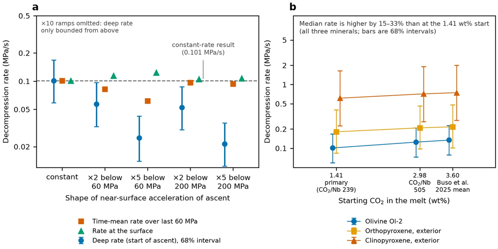

Figure 8.4: The olivine profile fixes the near-surface rate, and more CO2 makes the rates faster. (a) Ol-2 refit with ascent 2 or 5 times faster below 60 or 200 MPa: deep rate (68 %), mean over the last 60 MPa, and surface rate. (b) Rates against starting CO2 for Ol-2 and the WHT1 exterior opx and cpx. SR-wide P–T family.

## 8.6 SR among published eruptions

How fast is the SR ascent compared with eruptions studied with the same kind of model? The comparison uses only H2O diffusion with a degassing boundary (olivine phenocrysts, melt embayments and melt inclusions).

Figure 8.5 places the SR olivine rate among the published ones, and Table 8.5 gives the ratios. We compare each published rate with the olivine-only SR path rate of 0.093 MPa/s, not with the joint rate, because the published studies fit olivine alone. SR equals Seguam 1977 (ratio 0.93, 0.100 MPa/s; Newcombe et al. 2020). It is about one quarter of Fuego 1974 (0.23) and one fifth of Etna 3930 BP (0.20), which is the closest analog: primitive, Fo 90 olivine with CO2-rich inclusions. It is 1.9 times the published Kilauea Iki rate, and 3.1 to 10 times the Cerro Negro olivine rates (3.1 for 1995, 10 for 1992) of Newcombe et al. (2020) and 13 to 66 times the melt-inclusion rates of Barth et al. (2019).

| Study (eruption) | Model temperature | Published rate (MPa/s) | SR path ÷ study | SR isothermal ÷ study |
| --- | --- | --- | --- | --- |
| Fuego 1974 (Newcombe et al. 2020) | 1030 °C | 0.410 | 0.227 | 0.349 |
| Etna 3930 BP (Barth et al. 2024) | not stated | 0.470 | 0.198 | 0.304 |
| Seguam 1977 (Newcombe et al. 2020) | 1070 °C | 0.100 | 0.93 | 1.43 |
| Kilauea Iki 1959 (Newcombe et al. 2020) | 1200 °C | 0.050 | 1.86 | 2.86 |
| Cerro Negro 1995 / 1992 (Newcombe et al. 2020) | 1100 °C | 0.030 / 0.009 | 3.10 / 10.3 | 4.77 / 15.9 |
| Cerro Negro 1992 / 1995 (Barth et al. 2019) | 1100 °C | 0.0073 / 0.0014 | 12.7 / 66.4 | 19.6 / 102 |

The comparison puts SR on a fairer footing than before, though not an identical one. Every published rate in the set was modeled isothermally at the temperature of the study’s own inclusions or eruption (1030 to 1200 °C where stated). The SR path rate equals an isothermal fit at about 1150 °C, so the ratios compare SR’s best-temperature rate with each study’s single-temperature rate. The earlier isothermal SR rate, at 1200 °C, was hotter than every comparison except Kilauea Iki, and moving to the path lowers every ratio by about a third. A path treatment of the other studies would move their rates in the same direction: Chen et al. (2013) found that 50 K of extra cooling lowered their Vulcano rates from 0.003 to 0.021 to 0.002 to 0.015 MPa/s. Seguam 1977 from melt embayments (Mutch et al. 2024, 0.07 to 0.36 MPa/s) gives a ratio of 0.58 on the path (0.093 ÷ 0.16).

SR is a cinder cone, and it sits at the fast end of the cinder-cone and Strombolian range, with only Seguam 1977 matching it. Two readings fit this and the comparison alone cannot separate them. The SR magma may have risen faster than a typical cinder-cone magma: it is rich in CO2 and carried dense mantle xenoliths. Or the rate is biased high. The candidate biases have been narrowed. The olivine K and the SR data share one calibration, the pyroxenes fit the same history once their diffusivities are free, and the cooling path has already lowered the rate by about a third. The olivine K within its published range (factor 0.58 to 2.3) and the solubility model (0.55) remain the main levers, and neither brings SR down to the Cerro Negro range. CO2 content alone does not order the published rates either: CO2-rich Etna 3930 BP is fast like SR, while the CO2-rich Fogo and La Palma 2021 eruptions are slow by other methods and CO2-poor Fuego is fast. Eruption intensity tracks the rate better, as in Barth et al. (2019).

Published rates from H loss in mantle-xenolith olivine are not like-for-like. They fix the boundary at zero from the moment of entrainment, which makes them upper bounds on the equivalent rate; we return to them in Chapter 10. Having placed the rate among the other eruptions, the last question is how the degassing signal entered the xenolith at all.

## 8.7 How the degassing signal entered the xenolith

> **Work in progress.** The grain-boundary modeling in this section is still being revised. The current standard fits are the network fitted to each grain’s extrapolated rim ($10^{-6.25}$ m²/s) and option B, one common start with a diffusivity per grain ($10^{-5.75}$ m²/s); see the end of this section and appendix F (Section 17.9). Outstanding: measured grain sizes and traverse geometry for every traverse (half or full widths, crossing traverses, elongate grains), a path-length factor for the distance to the xenolith exterior, the two interior grains at 40.5 and 40.8 mm, and the cpx coupling to the network.

How did a drop in melt water at the exterior of the xenolith reach its interior, and what does that say about the pathway? The opx grains across WHT1 act as sensors, as in the grain-boundary experiments of Demouchy et al. (2010).

The measured pattern is a gradient in how much water the opx rims have lost. The outermost spot of the exterior grain (0.5 mm from the xenolith exterior) holds 96 ppm, about 30 % of its 315 ppm core, while the rims of the interior grains (40.5 and 40.8 mm) approach their cores. If every grain sat directly in the degassing melt, all would show the same loss. They do not, so the boundary of each grain lags the melt, and the lag measures the transport through the xenolith.

We fit the WHT1 opx traverses (35 points) with each grain a slab with its own half-width and core, sitting in a 50 mm grain-boundary network whose diffusivity carries the melt’s fractional H2O drop inward; all grains share one opx diffusivity. The network uses an activation energy of 34 kJ/mol (Demouchy 2010) and opx 144 kJ/mol. We reran the fits at each joint-fit scenario, each at its own joint rate. Table 8.6 gives the result.

Table 8.6: Network diffusivity is 10^−5.4 to 10^−6.0 m²/s in every scenario; the exterior grain sees the whole drop, interior grains about half. Nested fit, MiMiC start; ranges within Δχ² = 2.3.

| Scenario (joint rate, MPa/s) | 2023-style test, χ² (5 rims) | Nested network log10 D (m²/s) | Nested opx log10 D (m²/s) | Nested χ² (35 points) | Boundary drop g, exterior / interior |
| --- | --- | --- | --- | --- | --- |
| Isothermal 1200 °C (0.158) | 42.1 | −5.6 (−5.6 to −5.4) | −11.5 (−11.6 to −11.5) | 62.8 | 0.98 / 0.47 |
| P–T 46 °C/GPa (0.200) | 42.0 | −5.4 (−5.6 to −5.2) | −11.6 (−11.6 to −11.5) | 63.3 | 0.98 / 0.54 |
| **P–T 82.8 °C/GPa (0.100)** | 42.0 | −5.6 (−5.8 to −5.6) | −11.6 (−11.6 to −11.5) | 63.3 | 0.98 / 0.55 |
| P–T 120 °C/GPa (0.050) | 41.9 | −6.0 (−6.0 to −5.8) | −11.5 (−11.6 to −11.5) | 63.7 | 0.98 / 0.46 |

Four things follow. First, the scenario barely matters: the network diffusivity is $10^{-5.4}$ to $10^{-6.0}$ m²/s in every fit and is lowest only at 120 °C/GPa, where the slow rate gives the network more time. Second, the exterior grain is effectively unbuffered (g = 0.98), and the interior grains saw about half the melt’s drop (g 0.45 to 0.55) by the end of the ascent. Third, the 2023-style test, which treats each measured rim as the grain-boundary value, fails in every scenario (χ² 42 for 5 rims); the rims sit 19 to 45 µm inside each grain, so they lag the boundary. Fourth, the opx diffusivity of the nested fit ($10^{-11.5}$ to $10^{-11.6}$ m²/s) is lower than the joint-fit value for the exterior opx (−10.98); a coupled fit that lets the grains feed H back into the network gives −10.9 to −11.0, so the exchange data prefer a somewhat lower opx diffusivity than the exterior profile alone. The set-ups differ: the joint fit gives the exterior grain the melt as its boundary and a 423 ppm start, while the nested fit puts every grain behind the grain-boundary network and fits one opx diffusivity to all five traverses, including the heterogeneous interior grains (Chapter 9). We take the spread, about 0.6 log units, as the uncertainty of the opx diffusivity from these data.

A second way to read the same data avoids the lag inside the grains. Each grain’s own profile is extrapolated to its edge (a one-step diffusion profile with the core fixed), and the network is fitted to those four edge values. This gives $10^{-6.25}$ m²/s (68 %: −6.35 to −6.15) at 0.100 MPa/s, with χ² 5.6 for 4 rims, and it is the fit shown in the Chapter 3 Figure 13 replica (Section 17.9). The 0.5 mm grain extrapolates to about zero (−8 ± 42 ppm), so an edge that follows the melt fits it without buffering. A one-step profile treats the falling edge as constant, which biases this value low; the nested fit models the falling edge but places the 0.5 mm grain’s outermost point too high.

The nested set-up above starts each grain at its own measured core, which builds in an unchanged core and a different partition coefficient for each grain. The standard nested fit (option B) instead starts every grain at one common value with one opx partition coefficient and gives each grain its own opx diffusivity, for crystal anisotropy (`scripts/decompression/gb_aniso_halfwidth.py`). It fits all 35 points better (χ² 43.8 against 63.3) with a common start of 388 ppm (384–400; 411 ppm gives χ² 45.8) and a network diffusivity of $10^{-5.75}$ m²/s (68 %: −5.81 to −5.68). The two exterior grains then agree with each other and with the joint fit (opx log D −11.1 and −11.0, against −10.98), and their plateaus below the start become core loss. The interior pair needs −11.8 and −10.4, a spread twice the largest published opx anisotropy (0.6 log units), so something local, most plausibly a melt vein near the 40.8 mm grain, acts there as well. Freeing each grain’s half-width (±25 % prior) changes χ² by less than 2. The two standard fits, extrapolated rims and option B, bracket the network diffusivity at $10^{-6.25}$ to $10^{-5.75}$ m²/s at the headline rate. The scenario table above uses the earlier measured-core set-up.

### 8.7.1 Which pathway carries the signal

Which physical pathway can carry a drop in water activity centimeters into a xenolith within about an hour? We compare four. The comparison separates two questions: how fast the signal travels, and how fast the water itself moves. Towbin & Plank (2026) give the physical constraints: 8 to 10 % interconnected vein and film melt in 2-D (about 20 vol% in 3-D), grain-boundary glass films extending 100 to 200 µm from the veins, vugs at 1 to 4 % of the rock, and host-like chemistry reaching only the outer centimeter.

Melt diffusion in the vein network (about 5 × 10⁻¹¹ to 2 × 10⁻¹⁰ m²/s) reaches only 0.4 to 0.9 mm in an hour, far short. Dry nanometer grain boundaries, weighted by how much water the grains hold, have an effective diffusivity of 10⁻¹³ to 2 × 10⁻¹² m²/s and reach 0.02 to 0.08 mm. Vapor in vugs and cracks (3 × 10⁻⁸ to 7 × 10⁻⁷ m²/s) reaches 11 to 51 mm. Only the intrinsic grain-boundary value of Demouchy et al. (2010) and the fitted network value ($2$ to $4 \times 10^{-6}$ m²/s) reach about 100 to 140 mm. The lengths come from the earlier mixture-start run over about an hour and scale as the square root of time; at the joint rate the interval is about 1.5 h, which lengthens them by about 20 %.

The profiles record signal relay, not mass transport. If the boundary network holds little water of its own, a drop in water activity travels at about the intrinsic grain-boundary diffusivity, and that is what the opx profiles show. Moving the water itself is a different matter. The vein melt holds 80 to 88 % of the xenolith’s H2O and the grains about 3 %. Transporting that mass centimeters along dry boundaries would need the storage-weighted value, which is 10⁻¹² m²/s or lower and far too slow. A closed-system mass balance suggests the vein melt is dry (about 0.09 wt% H2O, from a bulk-rock value of about 80 ppm and a bulk partition coefficient of 0.0034), a low-activity sink rather than a reservoir, though H2O in the vein glass has never been measured. The lag also argues against efficient in-place degassing of a water-rich vein melt, which would lower the activity everywhere at once with no lag from the exterior.

Figure 8.6 sets three candidate mechanisms against the measured rim-to-core ratios of the WHT1 opx grains. Melt-network diffusion alone, or melt pockets that keep their water, stop the signal within 1 to 3 mm and predict no depletion beyond the exterior grain. Grain-boundary transport at 2 to 5 × 10⁻⁶ m²/s matches three of the five traverses and under-predicts the exterior grain (0.5 mm) and the long interior traverse, whose cores are heterogeneous (310 to 409 ppm within one grain). The curves are on the CO2/Nb (wet) start with a constant 1200 °C: the melt and vapor diffusivity laws they need were not rerun on the path (they require temperature laws for melt and vapor diffusion), and the network diffusivity moves by 0.5 log units at most across the temperature scenarios, far less than the orders of magnitude that separate the mechanisms.

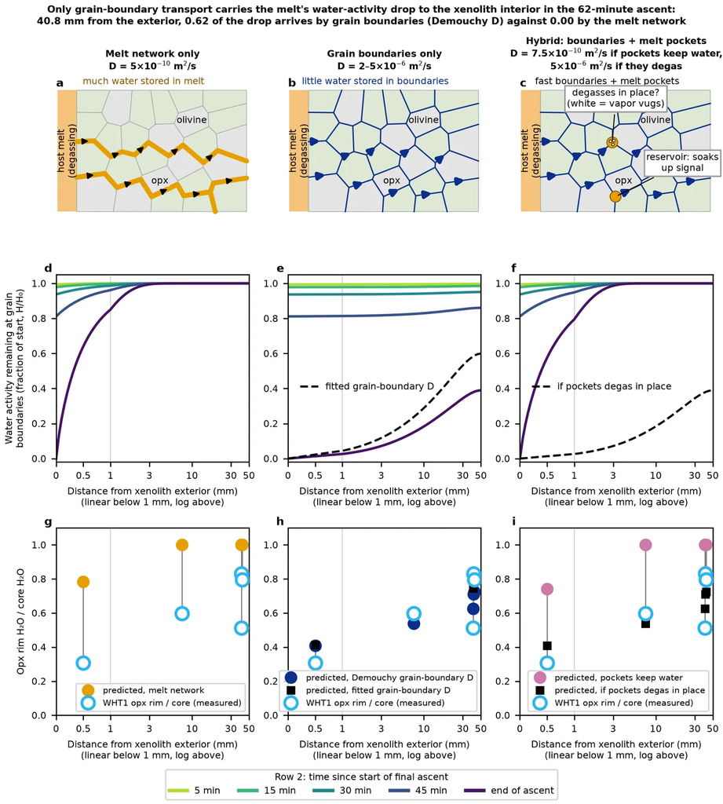

Figure 8.6: Only grain-boundary transport carries the melt’s water-activity drop to the xenolith interior: at 40.8 mm about 0.6 of the drop arrives by grain boundaries, none by the melt network. Columns: melt network, grain boundaries, hybrid. Rows: cartoon, water activity with distance, predicted against measured opx rim/core. CO2/Nb (wet) start, isothermal 1200 °C, 0.178 MPa/s (melt and vapor D have no temperature laws).

Demouchy et al. (2010) argued from Harrison’s regimes that hydrogen diffusion in grain boundaries cannot compete with lattice diffusion in coarse-grained rocks. Over the hour of H loss, the check gives a more qualified answer. Olivine (diffusion length 0.60 mm) is in the regime where its grains engage fully with the boundaries, and opx ($10^{-11.2}$ m²/s, 0.15 mm) is in the regime where only its outer rim exchanges. During degassing the grains are sources, not sinks, but the released water still resists the fall in boundary activity. With dry nanometer boundaries holding melt-like water, the coupled fit would need a boundary diffusivity about 100 times Demouchy’s value, so the boundary phase decides: dry boundaries have the speed but not the storage, and micrometer melt films have the storage but not the speed. Fluid-wetted boundaries and cracks give both. Towbin & Plank (2026) report olivine pitting by fluid more than 150 µm from the veins, which supports that pathway. The conclusion is that a grain-boundary-type network, most plausibly fluid-wetted boundaries and cracks, carried the signal in WHT1, at a diffusivity consistent with the intrinsic value of Demouchy et al. (2010). Path-controlled transport predicts depletion set by each grain’s distance to a connected crack or vein, not to the exterior; mapping the vein and crack positions around the analyzed grains would test it.

All of these processes ran in the last tens of MPa of the ascent. The xenolith minerals must first have been in equilibrium with the host melt for the profiles to start from the right value, which is the subject of the next chapter (Chapter 9).

Sources: `data/supplement/summary_csv/Ascent_Rates.csv`, `Other_Timescales.csv`, `Literature_Rates.csv`, `Model_Inputs.csv`; `docs/UNCERTAINTY_SCENARIOS_2026-10-22.md` (sections 10, 10c, 10e–10g); `docs/ASCENT_RATE_SUMMARY_2026-10-22.md`; `report/chapters/04-degassing.md`, `06-ascent-rates.md`, `07-xenolith-exchange.md`, `08-literature.md`; the thesis Discussion.

# 9 Stage I: ascent in water-undersaturated magma

Stage I runs from xenolith pickup at about 1.15 GPa to the depth where the melt starts to lose water. The magma is H2O-undersaturated throughout (the MiMiC model melt saturates at 682 MPa and still holds 99 % of its H2O at 585 MPa), so H+ can move freely between melt and mineral. This chapter asks whether the xenolith minerals used that time to equilibrate with the host. Three tests bear on it: the olivine cores and the time the crystals spent in the melt, the starting levels of the intact orthopyroxene (opx) interiors, and the clinopyroxene (cpx) core water against the water in each magma.

## 9.1 Do the olivine cores equal the phenocrysts, and was there time?

**Cores.** The xenolith olivine cores in the GCB1 interior hold 4.3–8.7 ppm H2O (mean 6.89, n = 8) and those at the exterior 4.8–7.7 ppm (mean 5.95, n = 9). The scoria phenocryst cores hold 5.9–7.9 ppm (mean 6.77, n = 5). Interior and exterior xenolith groups do not differ statistically (Welch t = 1.38). Olivine inside the xenolith therefore carries the same water as olivine that grew in the host magma, which is what full equilibration with the host predicts. The check has limited power: n is small and the olivine cores have also lost water during Stage II (Chapter 8), so it shows that the cores share a history with the phenocrysts, not what that history was before degassing.

**Time.** Several clocks say there was ample time before the magma began to degas. Conduction heats a 65 mm radius xenolith in about 2 h. Hydrogen in the slowest phase, a 0.5 mm cpx, needs about 7 h at 1200 °C to reach a flat profile. The Fe–Mg profiles of olivine give residence times in the carrier of hours to weeks (Table 9.1), against a final ascent recorded by H of about 1.6 h from 585 MPa at 0.100 MPa/s.

Table 9.1: Every grain sat in the melt far longer than the 1.6 h of final ascent. Fe–Mg interdiffusion along [100] at 1250 °C and 500 MPa; Ol-2’s edge is held at the Fo of its BSE profile; xenocryst fits use the stored modeling setup. At 1200 °C every time is 2.1× longer.

| Olivine grain | Locality | Fe–Mg time (days) | 1σ range (days) | Starting profile |
| --- | --- | --- | --- | --- |
| Ol-2 (phenocryst) | Roadside | 18.4 | 15.7–21.3 | Two steps (rim, shoulder); edge held at Fo 79.7 |
| ol6, profile 1 (xenocryst) | Roadside | 0.15 | 0.10–0.21 | Archived setup |
| ol6, profile 2 (xenocryst) | Roadside | 0.21 | 0.18–0.23 | Archived setup |
| ol23 (xenocryst) | Roadside | 0.37 | 0.32–0.42 | Archived setup |
| ol43 (xenocryst) | Pit | 1.9 | 1.5–2.4 | Archived setup |
| ol48 (xenocryst) | Pit | 3.0 | 2.8–3.3 | Archived setup |

Table 9.1 shows that even the shortest record, 0.15 d (3.6 h), exceeds the 1.6 h of H-recorded ascent by 2.2×. Ol-2 spent 18.4 d in the carrier, with its edge held at Fo 79.7, the rim value of its backscattered-electron (BSE) gray profile scaled to the EMPA Fo; the three starting profiles tested span 14–33 d (Section 12.10). These are residence times in the carrier melt, so they bound the time available for exchange but not the length of Stage I itself.

**Two pulses.** The Fo data (Figure 9.1) show that the crystals in the scoria did not all come from one melt. The pit phenocryst rims reach Fo 83.3–85.8 (median 84.5), in equilibrium with the host lava (Fo 83.6–85.7). The roadside rims end 1–4 Fo units lower (Ol-2 at 80.7, ol6 at 81.5–82.6, ol23 at 83.0) and need a melt with 6.6–8.6 wt% MgO. Residence times differ in the same direction: 0.15–0.37 d for the roadside xenocrysts, 1.9–3.0 d for the pit xenocrysts. The roadside inclusions are also drier (1.96–2.80 against 2.41–3.55 wt% H2O) and lower in Cl/K2O. Two pulses of magma probably fed the two sampling sites. No measured inclusion records the final roadside melt, so the starting H of Ol-2 is not directly known (Chapter 11).

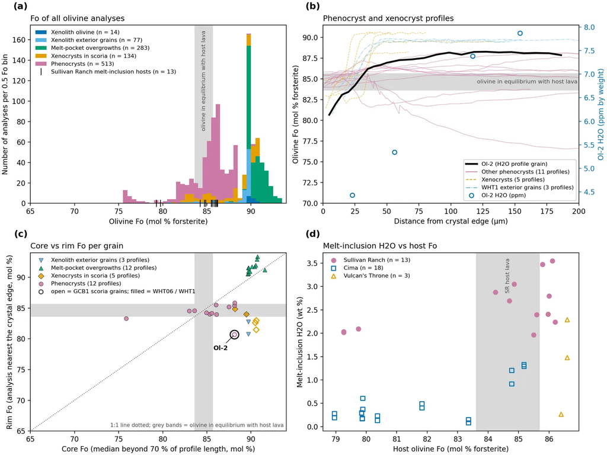

Figure 9.1: Ol-2 grew from a more primitive melt than the host lava, and the roadside rims end 1–4 Fo units below the pit rims. (a) Fo of all olivine analyses by population. (b) Fo profiles. (c) Core against rim Fo per grain. (d) Inclusion H2O against host Fo. Grey: equilibrium with the host lava.

The olivine says the minerals had time and the same history as the host. Whether they ended at the host’s water level depends on what the opx interiors hold.

## 9.2 What do the opx interiors say about the starting water?

The ascent-rate fits need a starting level for the grains before water loss began. The best anchor is the interior of the large WHT1 opx, which sat 40 mm inside the xenolith, far from the degassing exterior.

The picture is less tidy than “intact cores at 411 ppm” (Figure 9.2). Two of the five traverses, the exterior opx at 0.5 mm and the interior opx-2 at 40.8 mm, flatten near 300–320 ppm. Only the two deepest single points reach 409–413 ppm. The interior opx-1 rises steadily to 413 ppm with no plateau. For the exterior grain, a flat 315–321 ppm center is no evidence of the start: the joint fit reproduces it as loss from a 423 ppm start that reached the middle of this small grain (χ² 0.9). The interior opx-2 grain is different. A 300 ppm shelf with a 409 ppm point behind it cannot come from one starting value diffusing inward, so this grain was probably zoned before the final water loss.

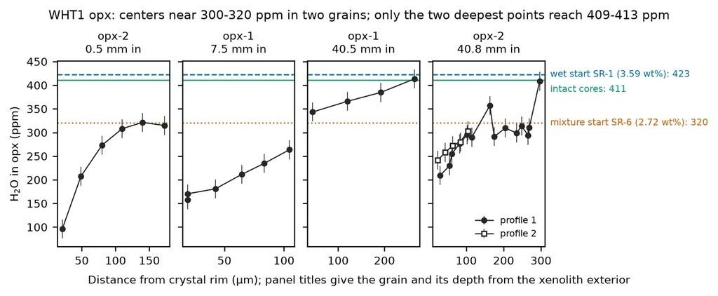

Figure 9.2: Two WHT1 opx grains flatten near 300–320 ppm, and only the two deepest points reach 409–413 ppm. H2O in opx against distance from the rim for the five traverses, by grain and depth in the xenolith. Lines: opx-anchored K times melt H2O for the wet CO2/Nb start (423 ppm; 418 ppm for the MiMiC start), the mixture start (320 ppm) and the two intact cores (411 ppm).

Two fits disagree about which level to use. The rate model, fitted to the exterior opx and cpx, fits with the MiMiC melt (3.549 wt% H2O): joint χ² 20.0 isothermal, against 41.5 for the mixture start (SR-6, 2.72 wt% H2O; computed with the CO2/Nb start). The exchange model, fitted to all five WHT1 traverses with one common start, prefers the lower level: χ² 104 at 321 ppm against 154 at 411 ppm. Nearly all of that difference is one traverse, interior opx-2 profile 1 (χ² 64 against 106). When each traverse may choose its own start, the values scatter from 215 ppm to the 600 ppm bound, so no single common start fits every interior grain.

The two levels can be read in two ways, and the data do not choose between them.

- **K uncertainty.** A 300–320 ppm start in the MiMiC melt (3.549 wt%) needs K of 85–90 ppm per wt% (84–89 for the CO2/Nb start, 3.59 wt%), an opx/melt D of about 0.009 and 25 % below the Novella-anchored value (117.7). The experimental range is 0.009 to about 0.019 (K about 90–190), so both levels lie inside it.
- **Starting-H2O uncertainty.** With K = 117.7 ppm per wt%, the plateaus equal the mixture batch (2.72 wt%) and the deepest points the wet batch (3.49 wt%, against 3.549 wt% in the MiMiC melt and 3.59 wt% in the CO2/Nb start). Both are measured Sullivan Ranch melts.

We keep the MiMiC start for the rate because the exterior grains that record the rate fit it best. The interior grains started heterogeneous, which fits grains that last equilibrated with different batches. Either reading removes a single clean “intact core” anchor.

The opx cores thus point to a melt of 2.7–3.5 wt% H2O, in the range of the Sullivan Ranch inclusions. The cpx cores add a test across volcanoes.

## 9.3 Do cpx cores track the water in their magmas?

Cpx is the slowest phase, so it is the strictest test. We compared the cpx core water with that of the melt at each volcano, using the cpx/melt partition coefficient D from the experiments of O’Leary et al. (2010). Equation 10 of that paper was refit to 28 experiments recalibrated onto the SIMS scale of Towbin et al. (2023), with tetrahedral Al excluding the Cr-Tschermak component (residual σ 0.21 in ln D).

**Wetter magmas carry wetter xenolith NAMs, with one outlier.** Cima, the driest magma (1.29 wt% H2O), holds the driest cpx (113 ppm). The Sullivan Ranch cores (341–451 ppm) sit in the wettest magma. Vulcan’s Throne cores (421 ppm) are as wet as Sullivan Ranch’s in a drier magma (2.29 wt%), so the ordering holds only partly (Figure 9.3).

**The cores hold 1.2–2.6× what the experiments predict** (Table 9.2). Against the maximum melt H2O of each volcano, Cima and WHT1 sit within 1σ, WHT06_1 is 1.7σ off, GCB1 2.5σ and Vulcan’s Throne 2.7σ. The cpx diffusion fits agree independently: started from the experiment-based K, they pull K up by 1.6–1.9×, which means a cpx/melt D of about 0.011–0.016. The opx row differs because its K is anchored to the opx cores, so a ratio near 1 is by construction.

Table 9.2: Cpx cores hold 1.2–2.6× the water the recalibrated experiments predict; the opx, anchored to its own cores, does not. Observed D is the core mean divided by the best melt H2O; the last column gives the melt H2O the core needs, with the measured range in parentheses.

| Phase and group | Core H2O (ppm) | Observed D | Predicted D | Observed ÷ predicted | Melt H2O needed (measured), wt% |
| --- | --- | --- | --- | --- | --- |
| Cpx, Sullivan Ranch GCB1 | 451 | 0.0126 | 0.0068 | 1.84 | 6.6 (3.34–3.76) |
| Cpx, Sullivan Ranch WHT1 | 341 | 0.0095 | 0.0073 | 1.29 | 4.6 (3.34–3.76) |
| Cpx, Sullivan Ranch WHT06_1 | 346 | 0.0096 | 0.0063 | 1.54 | 5.5 (3.34–3.76) |
| Cpx, Vulcan’s Throne | 421 | 0.0183 | 0.0070 | 2.61 | 6.0 (2.13–3.23) |
| Cpx, Cima | 113 | 0.0088 | 0.0074 | 1.20 | 1.5 (1.21–1.94) |
| Opx, WHT1 (anchor) | 411 | 0.0114 | 0.0118 | 0.97 | 3.49 (3.34–3.76) |

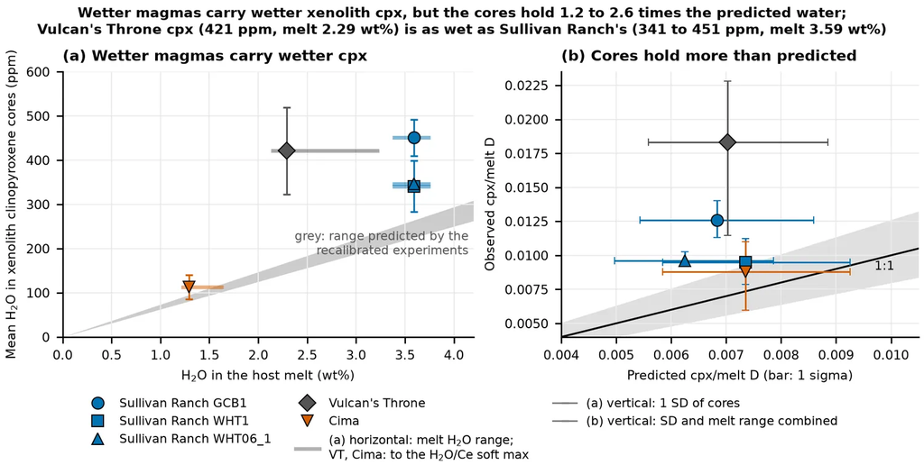

Figure 9.3: Wetter magmas carry wetter xenolith cpx, but the cores hold 1.2–2.6× the water the recalibrated experiments predict, and Vulcan’s Throne cpx are as wet as Sullivan Ranch’s in a drier melt. (a) Mean cpx core H2O against host-melt H2O (horizontal bars: best-estimate melt H2O range; vertical: 1 SD of the cores), grey band the experimental prediction. For Vulcan’s Throne and Cima the horizontal bar runs up to the soft maximum from literature H2O/Ce (265) times Ce: 3.23 and 1.64 wt%. The nearly undegassed Sullivan Ranch inclusions (H2O/Ce 149–416) cover that literature range. A single ratio times whole-rock Ce does not predict Sullivan Ranch itself (2.25 against 3.55 wt%), because its H2O varies with Cl, not Ce. (b) Observed against predicted cpx/melt D (1 sigma), with the 1:1 line.

Four readings could explain the excess, and none has been tested. The cores may have kept some pre-entrainment water, though the clocks above argue against it. The melt may have held more water than the inclusions record. The cpx/melt D may be higher at these conditions, for example rising as melt H2O falls, as for olivine. Or the recalibration of the experiments may be off (the Cr-rich Hauri set has no recalibrated values, and Aubaud 2004 sits 1.5× above the others). The Cr-Tschermak argument does not rescue the match: removing the Cr-Tschermak Al shifts D by 3–7 %, and explaining Vulcan’s Throne against Cima would need a Cr coefficient of −42 per apfu, outside what the experiments allow.

This revises a conclusion of the earlier chapter, which called the agreement quantitative. That comparison set recalibrated xenolith D against uncorrected experimental D. On a common scale the qualitative result stands (drier magma, drier cpx) and the quantitative one weakens. The pyroxene diffusion fits already use the opx-anchored cpx K, which agrees with what the cpx data choose, so the rate does not depend on the experimental D. Cpx cores therefore track the water of their host magma in order and within a factor of 1.2–2.6 in amount.

Together the three tests say that the minerals had time, and that their water follows the host melt. What that leaves of the mantle’s water is the question of the next chapter.

Sources: Fe–Mg residence and Fo populations (`results/olivine_femg_ol2/`, `data/olivine_fo_populations/grains.csv`); opx start levels (`figures/opx_start_levels.csv`, summary workbook sheets Other_Timescales and Magma_Models); cpx partitioning (summary workbook sheet Magma_Models, block C).

# 10 Stage 0 and implications

Stage 0 is the lithospheric source: the water the xenolith minerals held in the mantle before the host magma picked them up. This chapter asks what of it survives in the Sullivan Ranch (SR) xenoliths, what that means for xenolith water studies elsewhere, and what the xenoliths are still good for.

## 10.1 What survives of the mantle water?

Nothing measurable in these xenoliths. The chain of evidence has three links, each from the preceding chapters.

1. **Time was ample.** The crystals sat in the carrier melt for at least 3.6 h (shortest Fe–Mg record, 0.15 d) and up to 18 d (Ol-2), against about 7 h for a 0.5 mm cpx to reach a flat profile at 1200 °C and about 1.6 h for the final ascent recorded by H (Table 9.1).
2. **The minerals track the host.** Olivine cores in the xenolith match the phenocrysts (6.89 and 5.95 ppm against 6.77 ppm). The opx interiors sit at 300–413 ppm, in equilibrium with a melt of 2.7–3.5 wt% H2O when the opx-anchored K is used, which is the range of the SR inclusions (Section 9.2). The cpx are wetter in wetter magma and hold 1.2–2.6× what the recalibrated experiments predict (Section 9.3).
3. **The signal that did enter is the host’s.** Every grain lost water at its rim during final ascent (Chapter 8), and the interior grains see the drop with a lag that a fast transport network explains (Chapter 8).

Two limits apply. The cpx excess shows that partitioning is not settled, so the agreement is not quantitative. A cpx that retained mantle water would look the same as one that equilibrated with a wetter melt than the inclusions record, and no test here separates the two. We cannot exclude, but find no evidence for, a surviving mantle component in the cpx cores. The conclusion that nothing survives therefore rests mainly on the timescale argument, with the partitioning as a consistency check that is weaker than first reported.

The conclusion holds for hot alkali basalt carried in a cinder cone: a magma near 1200 °C with weeks between pickup and eruption. It says nothing about cooler or faster carriers.

Stage 0 leaves nothing to read, so the useful question becomes what this means for other studies.

## 10.2 What does this mean for xenolith water studies?

**Hot alkali basalts of cinder cones are the worst case for fidelity.** Diffusion of H+ through crystals, grain boundaries and melt is fast near 1200 °C, and the ascent from the mantle takes days to weeks. The minerals are reset. A study of xenoliths from such a host needs a measured host-magma water content, a P–T path and a degassing path before its mineral water can be read as mantle water. Cooler and faster hosts such as kimberlites, nephelinites and melilitites may preserve mantle water, but that needs constraints on their ascent rates, temperatures and water contents.

**Published xenolith-NAM rates are upper bounds and not like-for-like.** Several studies convert H loss from xenolith olivine into an ascent velocity. They fit a fixed boundary: zero H outside the crystal from entrainment onward, or a constant rim. They divide the full source depth (35–70 km) by the H-loss time. Our model, like those of Newcombe et al. (2020) and Barth et al. (2019), uses a boundary that follows the degassing melt, so H loss is confined to the shallow part of the path. When most of the loss is shallow, a velocity computed over the whole depth overstates the true constant velocity. Peslier et al. (2015) show the sensitivity inside one study: its rates rise 1.8× when the assumed start of loss moves from 1 to 1.8 GPa. The published rates also scale linearly with the diffusivity assumed, and Peslier & Luhr (2006) use a value that is the mean of two experimental values a factor of 10 apart.

Table 10.1: Published xenolith-olivine rates span 100× or more and rest on a fixed zero boundary, so they are upper bounds. Ratio: SR olivine on the P–T path (MiMiC start, 0.093 MPa/s) divided by the published center, or the geometric mean of the range.

| Locality (study) | Published rate, center (low–high), MPa/s | Model T (°C) | Kind of value | SR path ÷ study |
| --- | --- | --- | --- | --- |
| Pali-Aike (Demouchy et al. 2006) | 0.165 (0.0824–0.247) | 1245 | central estimate | 0.563 |
| Meerfelder Maar (Denis et al. 2013) | 0.100 (0.0879–0.343) | 1176 | central estimate | 0.92 |
| Dreiser Weiher (Denis et al. 2013) | 0.0275–0.110 | 1200 | central estimate | 1.69 |
| Salt Lake Crater, Oahu (Peslier et al. 2015) | 0.00549–0.695 | 925 | central estimate | 1.50 |
| Mt. Vulture (Berbineau et al. 2026) | 0.137 | not stated | upper bound | 0.675 |
| Kaapvaal kimberlites (Peslier et al. 2008, via Kilgore et al. 2020) | 0.137–1.02 | not stated | central estimate | 0.248 |
| Simcoe and Mexico (Peslier & Luhr 2006) | 0.00549–0.0137 | not stated | central estimate | 10.7 |
| Lac de Gras kimberlite (Kilgore et al. 2020) | 0.000916–0.00183 | 782 | lower bound | 71.5 |

These rates are upper bounds because of their boundary condition, not by each study’s own label: most report central estimates, and one (Kilgore et al. 2020) a lower bound. The table shows the eight olivine H-loss rows of the thirteen published xenolith constraints; the Fe–Mg, Ar and settling constraints are omitted.

A consequence for earlier work is specific. Demouchy et al. (2006) derived ascent from 60–70 km in hours from Pali-Aike olivine. If the Pali-Aike host carried water comparable to SR, the H-loss time would belong to the final 6 km and the implied velocity would fall by an order of magnitude. The water content of that host is unknown, so this remains a hypothesis to test, but it shows why the host water and degassing path are the first things to measure.

Reset xenolith water is a loss for mantle studies. It is a gain for a different question, treated next.

## 10.3 What are xenoliths good for instead?

They are timekeepers of the final ascent. The same grains that lost their mantle water recorded the speed of the magma that carried them. On the P–T path the joint fit of olivine Ol-2 and the WHT1 exterior opx and cpx gives 0.100 MPa/s (0.050–0.200 over the slope envelope of 46–120 °C/GPa), 0.63× the isothermal 1200 °C joint rate of 0.158. At 0.10 MPa/s the magma rises about 3.6 m/s, and the stretch where the melt loses half its H2O (below about 55 MPa) takes minutes. The CO2/Nb start, the second scenario, gives 0.112 MPa/s.

Two clocks together give the whole path. Fe–Mg profiles in olivine give weeks of residence in the carrier, and the H profiles give a final ascent of about an hour and a half from 585 MPa. The thesis chapter described the contrast as acceleration from about 0.002 MPa/s through most of the path to about 0.2 MPa/s in the upper crust. The updated rate is 0.100 MPa/s on the cooling path, so the contrast is about 50× rather than 100×. The deep rate is the thesis estimate (at least a week from 1.15 GPa) and was not remeasured; the Fe–Mg times are residence times in the carrier, not ascent times.

The xenolith also records how the signal moved. The exterior grain saw the melt boundary directly (g 0.98), and the interior grains saw about half the drop. The effective network diffusivity, 10^-6.25 to 10^-5.75 m²/s at the headline rate from the two standard fits, is 3–9× below the olivine grain-boundary value of Demouchy (2010) (5 × 10^-6 m²/s). Xenoliths can thus constrain transport inside a magma body as well as its speed.

The SR rate sits with Seguam 1977 (0.93×) and at about 0.2× Fuego 1974 and Etna 3930 BP. It is 3.1–10× faster than Cerro Negro. These comparisons use the olivine-only path rate of 0.093 MPa/s against each study’s rate at its own temperature, not refits of the published studies (Chapter 8).

Sources: summary workbook sheets Literature_Rates (block B), Other_Timescales and Magma_Models; Towbin et al. thesis chapter (Stage 0 and implications); `docs/LITERATURE_ASCENT_RATES_2026-10-21.md` for the boundary-condition argument.

# 11 Open questions for co-authors

Which choices could still change a finding, and which of them need an expert call rather than more analysis? The list below is short on purpose: it names only the items that could move a conclusion.

## 11.1 Questions for Terry

**CO2/Nb as the second scenario for the starting melt.** The primary start is the published MiMiC melt (3.549 wt% H2O, 8,529 ppm CO2, saturation 682 MPa). The inclusions lost CO2 before trapping, so that path starts partly degassed: bubble-reconstructed CO2 reaches only 9,079 ppm, and the inclusions saturate at 129–574 MPa, far shallower than xenolith pickup (1.15 GPa). The second scenario adds CO2 back as CO2/Nb times the Nb of the lava (59 ppm). With the depleted-mantle ratio of 239 (Saal et al. 2002) the start has 14,100 ppm CO2 and saturates at 922 MPa, close to pickup. With the ocean-island ratio of 505 ± 168 (Rosenthal et al. 2015) it has 29,800 ppm and saturates at 1,438 MPa, deeper than pickup. The rate depends on the choice by about 10 % (joint fit 0.100 MPa/s for the MiMiC start against 0.112 for CO2/Nb; Ol-2 isothermal 0.143 against 0.155), but the depth story does not survive without it. Terry is asked to judge whether the CO2/Nb scenario should stay as a second scenario or be dropped.

- **Which ratio?** Is 239 or 505 the better reference for an enriched alkaline basalt?
- **Which Nb?** Should each inclusion use its own LA-ICP-MS Nb instead of the lava value? With each inclusion’s Nb and a ratio of 239, undegassed CO2 is 11,400–20,500 ppm and saturation 670–900 MPa (Iacono-Marziano), against 190–450 MPa as measured.
- **Whether to correct at all.** Is the correction worth making for a summary of this kind? CO2/Ba gave 3–7× more CO2 and was rejected, because the SR Ba/Nb (11.5–16.5) lies far above that of the reference pairs.

## 11.2 Model questions

**Cpx partitioning.** The cores hold 1.2–2.6× the water that the recalibrated experiments predict (Table 9.2). Is the cause pre-entrainment water, a wetter melt than the inclusions record, a higher D at these conditions, or the recalibration of the experiments? No test separates them yet.

**Opx starting levels.** The opx plateaus at 300–320 ppm and the deepest points at 409–413 ppm can be read as K uncertainty (K of 84–89 against the anchored 117.7 ppm per wt%) or as different starting H2O (the mixture and the wetter batch). The rate model fits with the MiMiC (or CO2/Nb) start and the exchange model prefers the lower one (Section 9.2). Is there independent evidence to choose a K?

**Transport laws on the P–T path.** The two tables on transport mechanisms (mechanism curves and transport estimates) still run on the earlier mixture path. They need temperature laws for melt and vapor transport before they can be moved to the P–T path, and the grain-boundary activation energy (34 kJ/mol) is taken from one experimental study. Should they then use the single median slope (82.8 °C/GPa) or the full slope family?

**Path shape.** The olivine profile fixes the rate over the last ~60 MPa but not the deep rate (Section 8.5). - **Constraint:** a magma that accelerated 2 to 5 times toward the surface would have a mean ascent rate from pickup 2 to 5 times below the headline. - **Test:** only a phase that loses water deeper could tell, such as the cpx rims, which form deeper than the opx and olivine rims, or an inclusion record of the CO2 loss. Is any such test worth making?

## 11.3 Data questions still open

- **Matched exterior pyroxenes.** The modeled exterior opx (0.5 mm) and cpx (7.5 mm) come from different exteriors of WHT1, so their rates are not a like-for-like pair (Section 8.3). Should the pyroxene fits be repeated with a matched pair: Exterior-2 opx-1 and cpx-1 (both 7.5 mm), or Exterior-1 opx-2 and cpx-2 (0.5 and 1.45 mm)?
- **Cpx calibration standard.** A NanoSIMS standard row named “opx_ignore” sits in the cpx fit. If it is not intended, every cpx concentration changes slightly, and so does the partitioning test.
- **Experimental scale factor.** The thesis workbook’s “Kd-corr” is exactly 0.75 times the published-scale D. Does that come from the SIMS-scale factor of the cpx experiments (mean 0.769)?
- **Roadside final melt.** No inclusion or matrix glass samples the melt that set the roadside rims, so the starting H of Ol-2 is unmeasured. A drier carrier would make the rate faster (the 2.72 wt% start gives 1.12×).
- **Rounded cpx line and scaling.** Fifteen cpx analyses were typed with a rounded calibration line (0.2–1.4 ppm low), and two (T1-218 and T1-219) were rescaled for SiO2. Small, but should they stay as in the SIMS dataset (Supplement Table S2)?

Sources: summary workbook sheets Magma_Models and Other_Timescales; the working list of supplement questions; the older uncertainty chapter.

# 12 Diffusion model and fits

This appendix holds the method detail behind the decompression rates: the diffusion model and its Bayesian fit, the data and priors, the choice of a fixed uncertainty per profile, the warped-pressure treatment of a falling temperature, the diffusivity laws and partition coefficients, the edge and stall tests, and the supporting tables for the Fe–Mg residence of Ol-2 and for the xenolith exchange fits. The rates themselves are in Chapter 8. The primary start for every fit is the published MiMiC melt (3.549 wt% H2O, 8,529 ppm CO2; saturation 682 MPa); the CO2/Nb start (SR-1, 3.59 wt% H2O, 14,100 ppm CO2) is the second scenario. Tables below that were computed before the change of primary start are marked as CO2/Nb-start tables.

## 12.1 The decompression model

The model is the one used in the 2023 MATLAB fits, ported to Python (`~/Projects/H2O_Diffusion_NAM/decompression/`) and reproduced to ≤ 1e-14 relative. Pressure falls linearly, $P(t) = P_0 - v t$, over a total time $t_\mathrm{tot} = (P_0 - P_f)/v$. The crystal is a one-dimensional slab of half-width L with a no-flux center and a rim held in equilibrium with the degassing melt:

$$\frac{\partial C}{\partial t} = D\,\frac{\partial^2 C}{\partial x^2},\qquad
\left.\frac{\partial C}{\partial x}\right|_{x=0} = 0,\qquad
C(L,t) = K\,H\big(P(t)\big),\qquad
C(x,0) = K\,H(P_0)
\tag{12.1}$$

C is H2O in the crystal (ppm), H(P) the melt H2O along the degassing path (wt%, Chapter 14) and K the mineral/melt partition coefficient in ppm per wt% (10⁴ times the dimensionless D of Chapter 14). The crystal starts in equilibrium with the melt at P0. That start is justified by the P–T history: from xenolith pickup (about 1.15 GPa) to saturation (923 MPa) the melt H2O is constant, and between saturation and P0 (about 585 MPa) the SR-1 melt loses only 4 % of its H2O, so H in the xenolith minerals and in the phenocryst is free to equilibrate and nothing is lost before P0. The model is a one-dimensional slab; Mutch et al. (2024) show that 1-D fits can underestimate H loss by about 30 % for 3-D crystals.

**Exact property 1: one dimensionless time.** Rescaling $\xi = x/L$ and $s = t/t_\mathrm{tot}$ turns Equation 12.1 into $\partial C/\partial s = \tau\,\partial^2 C/\partial \xi^2$ with the rim value $K\,H(P_0 - (P_0 - P_f)s)$, where

$$\tau = \frac{D\,t_\mathrm{tot}}{L^2} = \frac{D\,(P_0 - P_f)}{L^2\,v}.
\tag{12.2}$$

The data constrain τ, not D and v separately, so $v = D(T)(P_0 - P_f)/(\tau L^2)$, and a change of diffusion law rescales the fitted rate exactly ($v_\mathrm{new} = v_\mathrm{old}\,D_\mathrm{new}/D_\mathrm{old}$). The discrete scheme is invariant too (≤ 3e-16 relative on all ten 2023 cases). L is not a pure rescaling, because the measured distances are fixed in µm.

**Exact property 2: K only scales the profile.** The problem is linear and homogeneous, and the initial and rim values are proportional to K, so $C(\cdot\,; K) = K\,C(\cdot\,; 1)$. With data $h_i \pm s_i$ and model $K g_i(\tau, P_0, P_f)$, a Gaussian prior $K \sim N(\mu_K, s_K^2)$ integrates out in closed form. With $a = \sum g_i^2/s_i^2 + 1/s_K^2$ and $b = \sum h_i g_i/s_i^2 + \mu_K/s_K^2$,

$$\log p(h \mid \tau, P_0, P_f) = -\tfrac12\Big[\sum_i \frac{h_i^2}{s_i^2} + \frac{\mu_K^2}{s_K^2} - \frac{b^2}{a}\Big]
- \tfrac12\log\!\big(a\,s_K^2\big) - \sum_i \log\!\big(\sqrt{2\pi}\,s_i\big).
\tag{12.3}$$

The closed form matches numerical integration over K to 1e-8. It needs negligible prior mass at K < 0, so K priors wider than about 16 % (1σ) are run as several fits instead.

## 12.2 Grid posterior, data and priors

Because the dimensionless profile $G(\xi; \tau, P_0, P_f)$ does not depend on the data, it is tabulated once per case and degassing path: 400 values of log τ (from the explicit solver’s floor to 2.5), nodes at the ends of the P0 and Pf prior ranges interpolated onto 15 × 6 cells, and a spatial grid twice as fine as the 2023 one. The priors sit on the physical parameters, and the posterior

$$p(\log v, \log D, P_0, P_f \mid h) \propto
\exp \ell\big(\log D + \log(P_0 - P_f) - 2\log L - \log v,\ P_0,\ P_f\big)\; p(\log v)\,p(\log D)\,p(P_0)\,p(P_f)
\tag{12.4}$$

is evaluated on a grid of 350 log v cells (0.02 dex) × 21 log D nodes × the P0 × Pf cells, with the K-marginal log-likelihood ℓ (Equation 12.3) interpolated in log τ. It is exact to grid resolution, with no MCMC noise, and replaces the 2023 Monte Carlo of optimizer solutions, whose spread mixed the D prior, the data noise and optimizer stopping error. Validation: table entries equal direct forward runs; log v quantiles move by less than 0.01 dex when the τ and v grids are doubled; and on synthetic profiles drawn from the priors the 68 % and 95 % intervals contain the truth at their nominal rates. Ascent speed is $u = v/(\rho g)$ with ρ = 2800 kg/m³.

Table 12.1: The three profiles that carry the ascent rate and the priors they are fitted with. The olivine rests on four low-concentration analyses, so its rate is set as much by how far the core sits below K times the starting melt H2O as by the profile shape. The rate prior is flat in log v over 10⁻³–10⁴ MPa/s (the code’s range; it has no effect on the results).

| Parameter | Olivine Ol-2 | WHT1 exterior opx | WHT1 exterior cpx |
| --- | --- | --- | --- |
| Profile points, fixed 1σ | 4 points (4.4–7.9 ppm), 0.25 ppm | 6 points, 20 ppm | 10 points, 20 ppm |
| Half-width L (µm), distance reference | 145, center | 180, center | 115, rim |
| log10 v prior | Flat over 10⁻³–10⁴ MPa/s | same | same |
| log10 D prior | Ferriss [100] at 1200 ± 20 °C | Carpenter [001] at T + 20 K to Carpenter [100] at T − 20 K | 10<sup>−6.71</sup> with Ea 100 kJ at T + 20 K to 130 kJ at T − 20 K |
| K (ppm per wt%) | N(9, 1.35) (6 and 12 as alternatives) | Three strategies (Table 12.5) | Three strategies (Table 12.5) |
| P0 | U(500, 670) MPa | U(600, 670) MPa | U(600, 670) MPa |
| Pf | U(0, 0.5) MPa | U(0, 0.5) MPa | U(0, 0.5) MPa |

The olivine case needs a caveat. Its core holds 7.9 ppm against about 32 ppm for K times the starting melt, so Ol-2 has lost about 75 % of its H, and the fitted rate is set largely by how much core loss K = 9 implies. Scaling the olivine data by a factor s is the same as using K/s, so K and the data must be on the same SIMS calibration. They are: the Towbin et al. (2023) K was built by recalibrating the experiments onto the same revised opx scale as the SIMS dataset (Chapter 15).

## 12.3 Fixed uncertainty per profile

The fits use one fixed 1σ per profile (olivine 0.25 ppm, pyroxene 20 ppm), as in 2023. The alternative is a per-point 1σ. Three variants were fitted on the CO2/Nb-start (SR-1) P–T path with only the likelihood σ changed: the fixed σ; the total 1σ of the SIMS dataset per point (calibration, counting and blank scatter; olivine 0.31–0.43, opx 6–16, cpx 19–32 ppm); and the spot-to-spot σ (counting and blank scatter only, about 4 ppm for pyroxene). The calibration term is shared by all points of a profile, so it acts like a K error rather than scatter. The fixed rows reproduce the primary fits exactly (106 of 106 posterior rows). Table 12.2 gives the rates and Table 12.3 the misfit check.

| Profile and K | Fixed σ (2023, used) | Total 1σ per point | Spot-to-spot σ per point | Data-estimated σ, calibration in K |
| --- | --- | --- | --- | --- |
| Ol-2, K = 9 | 0.101 (0.059–0.168) | 0.102 (0.060–0.171) | 0.102 (0.059–0.170) | 0.105 (0.061–0.176) |
| Opx, core/start 411 ppm | 0.181 (0.084–0.401) | 0.146 (0.069–0.314) | 0.165 (0.078–0.352) | 0.170 (0.081–0.368) |
| Opx, opx-anchored | 0.180 (0.080–0.406) | 0.135 (0.063–0.290) | 0.164 (0.077–0.346) | 0.165 (0.076–0.356) |
| Cpx, core/start 390 ppm | 0.611 (0.225–1.643) | 0.679 (0.247–1.846) | 0.500 (0.187–1.330) | 0.583 (0.216–1.562) |
| Cpx, opx-anchored | 0.569 (0.207–1.548) | 0.671 (0.240–1.863) | 0.487 (0.183–1.289) | 0.526 (0.193–1.421) |

The total 1σ moves the pyroxene rates by −25 % to +18 % because it scales with concentration (5–9 % of the value) and so reweights the low-H rim points against the cores; that reweighting, not a wider or narrower σ, shifts the rates. A misfit check asks which σ the data support.

Table 12.3: The spot-to-spot σ is rejected for both pyroxenes, which scatter 2–4 times more than the analytical error, so the fixed 2023 σ, which is close to the implied scatter for cpx and twice too large for opx, is kept. Minimum χ² over every model shape on the isothermal grid with K free, probability of a χ² at least that large, and the white σ the data imply. The cpx residuals are structured (points 4–6 low by 12–20 ppm, points 8 and 10 high by 17–24 ppm), which suggests real heterogeneity along the profile.

| Profile (points, degrees of freedom) | Fixed σ | Total 1σ | Spot-to-spot σ | σ the data imply |
| --- | --- | --- | --- | --- |
| Ol-2 (4, 2) | χ² 6.0, p = 0.05 | 3.2, p = 0.20 | 4.0, p = 0.13 | 0.43 ppm (fixed 0.25) |
| WHT1 opx (6, 4) | 0.9, p = 0.92 | 2.6, p = 0.63 | 19.4, p = 0.0007 | 9.5 ppm (fixed 20) |
| WHT1 cpx (10, 8) | 5.1, p = 0.74 | 2.8, p = 0.95 | 107.6, p = 1e-19 | 16.0 ppm (fixed 20) |

**Decision: keep the 2023 fixed σ.** It is a user-chosen σ that covers natural data scatter (the precedent is Girona & Costa 2013), and with ten points or fewer a reduced χ² is itself poorly determined (Andrae et al. 2010). The total 1σ passes the misfit test only because its shared calibration term inflates the independent noise, and its rate shifts are not supported.

## 12.4 Variable temperature: the warped pressure

On the P–T path (Chapter 3) the temperature falls, $T(P) = 1330\ \mathrm{°C} - s\,(2.26\ \mathrm{GPa} - P)$, so D falls with pressure: $D(t) = D_\mathrm{ref}\,r(T(P(t)))$ with $r = \exp[-(E_a/R)(1/T - 1/T_\mathrm{ref})]$ and $T_\mathrm{ref}$ = 1200 °C.

**Why it is exact.** With reduced time $\theta = \int_0^t D\,dt'/L^2$ the diffusion equation becomes $\partial C/\partial\theta = \partial^2 C/\partial\xi^2$ again, and only the rim value as a function of θ changes. For continuous ascent, $dP = -v\,dt$, so

$$\int D\,dt = \frac{D_\mathrm{ref}}{v}\int r\big(T(P)\big)\,dP,
\qquad
P_w(P) = \int_0^{P} r\big(T(P')\big)\,dP'.
\tag{12.5}$$

Reduced time is linear in the warped pressure $P_w$ with the constant rate $D_\mathrm{ref}/v$. The constant-D problem with rim value $K\,H(P(P_w))$, run on the warped pressure (with the path and the P0 and Pf priors mapped through $P_w$), is the variable-temperature problem, and its fitted v is the true ascent rate. No new solver or approximation is involved (`scripts/decompression/fit_pt_path.py`).

**Activation energies.** Each phase uses the mean Ea of its two bracket laws: olivine 130 kJ/mol (Ferriss, one law); opx 144 kJ/mol (Carpenter 127 and 161); cpx 115 kJ/mol (the 100 and 130 kJ ends of the 2023 cpx bracket).

**Slopes and families.** Fits are run at slopes of 30–150 °C/GPa in 15 °C/GPa steps. The scatter of the start (N(1330, 15) °C, N(2.26, 0.10) GPa) is carried as an effective slope with the same temperature at 30 MPa. Each family’s rate is a mixture of the per-slope posteriors (lognormal from the median and 68 % range) over that family’s slope distribution.

**Controls.**

All three phases slow by nearly the same factor on the path (0.63–0.69 across the SR-wide envelope), because their Ea (115–144 kJ/mol) are similar. The path changes the rates but not the disagreement between phases.

**Accelerating ascent.** For a rate $v(P) = v_0\,a(P)$, $dt = -dP/(v_0 a)$, so $\int D\,dt = (D_\mathrm{ref}/v_0)\int r/a\,dP$. The same fit on $P_w = \int_0^P r/a\,dP'$ is exact, and its fitted rate is $v_0$, the rate above the ramp. - **Shapes:** $a = 1$ above $P_a$ and $a = F - (F-1)P/P_a$ below it, with F = 2, 5, 10 and $P_a$ = 60, 200 MPa. - **Prior:** the lower edge of the rate prior is moved down by $\log_{10}F$. - **Derived rates:** the mean rate over an interval ($\Delta P / \int dP/(v_0 a)$) and the surface rate ($F v_0$) are fixed multiples of $v_0$, so the slope-family mixture is taken on $v_0$ and scaled. - **Control:** the constant shape reproduces the path fits to 6 × 10⁻¹⁷ MPa/s. - **Scope:** Ol-2 only, K = 9.

**Higher starting CO2.** Closed-system MagmaSat paths from the CO2/Nb start, SR-1 (same melt, H2O, Fe3+/FeT and 1200 °C) at 29,800 and 36,000 ppm CO2. They are fitted for Ol-2 (K = 9) and the WHT1 exterior opx and cpx (all K strategies) over the same slope grid. The 14,100 ppm path reproduces the path fits to 2 × 10⁻¹⁶ MPa/s, and the primary path’s hash is unchanged by the rebuild.

**Code.** `scripts/decompression/fit_path_variants.py {accel|co2}` and `plot_path_variants.py`; outputs in `results/decompression/path_variants/`.

## 12.5 Olivine diffusivity

**Laws** (Table 12.4). 55 olivine H diffusivity laws from 18 sources are transcribed in `data/olivine_h_diffusivity/laws.csv`, and the pyroxene laws in `data/pyroxene_h_diffusivity/laws.csv` and `at_1200C.csv`. Each olivine law is passed through the unchanged Ol-2 posterior (`scripts/decompression/olivine_d_laws.py`; wet-start rates in `results/decompression/olivine_d_laws_wet/`). The rate scales linearly with D (property 1), and the current law reproduces the main fit, which checks the run.

Table 12.4: Along [100] every natural-olivine law is as fast as Ferriss et al. (2018) or faster, so only a different axis or the proton-vacancy mechanism would make SR slow. H diffusivity laws used for the SR profiles, evaluated at 1200 °C, with the Ol-2 decompression rate each olivine law gives on the CO2/Nb-start (SR-1) MagmaSat path at 1200 °C (K = 9); the MiMiC start gives 0.92 times these rates for the primary law.

| Law | Phase, axis | log10 D0 (m²/s) | Ea (kJ/mol) | log10 D at 1200 °C | Role; isothermal rate, CO2/Nb start (MPa/s) |
| --- | --- | --- | --- | --- | --- |
| **Ferriss et al. 2018** | Olivine [100] | −5.4 | 130 | −10.01 | **Primary;** 0.155 (MiMiC start: 0.143) |
| Ferriss et al. 2018 | Olivine [001] / [010] | −6.6 / −6.9 | 130 | −11.21 / −11.51 | Orientation bound; 0.0098 / 0.0049 |
| Barth et al. 2023, end of run (Etna Fo 90) | Olivine [100] | −4.63 | 154 | −10.09 | Closest natural analog; 0.129 |
| Barth et al. 2023, start of run | Olivine [100] | −2.94 | 182 | −9.39 | Mobile-H law of the edge model; 0.64 |
| Barth et al. 2019 / Barth & Plank 2021 (Fo ~80) | Olivine [100] | −5.0 | 125 | −9.43 | For Fo 75–85; 0.59 |
| Jollands et al. 2019, Si-vacancy | Olivine [100] | −4.1 | 145.5 | −9.26 | 0.87 |
| Proton-polaron (Li et al. 2022) | Olivine [100] | −3.5 | 145 | −8.64 | Mechanism bound; 3.6 |
| Proton-vacancy (Li et al. 2022) | Olivine [100] | −1.2 | 279 | −11.09 | Mechanism bound; 0.013 |
| Proton-vacancy (Demouchy & Mackwell 2006) | Olivine [100]/[010] | −4.5 | 204 | −11.73 | Mechanism bound; 0.0029 |
| Carpenter 2003 (San Carlos enstatite) | Opx [100] | −6.6 | 127 | −11.10 | Low end of the 2023 opx bracket; matches the implied opx D |
| Carpenter 2003 | Opx [001] | −4.788 | 161 | −10.49 | High end of the 2023 opx bracket |
| Demers-Roberge et al. 2021 (Al-poor enstatite) | Opx [100] / [010] / [001] | −5.11 / −4.93 / −5.52 | 139 / 149 / 125 | −10.03 / −10.21 / −9.95 | Comparison; 7–20× too fast for one ascent |
| 2023 cpx bracket (“after Ferriss 2016 for 0.07 Al(IV)”) | Cpx | −6.71 | 100–130 | −10.26 (100 kJ) | 2023 prior; extrapolated from Ferriss 2016 (no published Al equation) |
| Ferriss et al. 2016, bulk H (Kunlun diopside) | Cpx | −8.8 | 100.4 | −12.36 | Comparison |
| Ferriss et al. 2016, 3540 cm⁻¹ band | Cpx | −6.7 | 130 | −11.30 | Near the implied cpx D |
| Ingrin et al. 1995 (Cr-diopside) | Cpx | −6.30 | 136 | −11.11 | Near the implied cpx D |
| Hercule & Ingrin 1999, uptake | Cpx | −6.7 | 126 | −11.16 | Near the implied cpx D |

- **Along [100] the Barth and Jollands laws are as fast as Ferriss or faster:** Barth 2023 0.83 times (end of run) to 4.1 times (start of run), Barth 2019 3.8 times (restricted to Fo 75–85 by Barth & Plank 2021), Jollands 2019 5.6 times. Barth 2023 also notes that fixing the edge at zero, as Ferriss did, underestimates the diffusivity, which points the same way.
- **Only orientation or mechanism can make SR slow.** Cinder-cone-like rates (0.005–0.04 MPa/s) would need a profile along [010] or [001] (0.03–0.23 times) or the proton-vacancy mechanism along [100] (0.02–0.08 times). For a magmatic phenocryst like Ol-2, Barth 2023 applies directly, and its [100] laws are the fast ones. Ol-2 is Fo 84–88, where Barth 2023 finds Fo the main control (fastest at Fo 79), so its true [100] D lies, if anything, between Ferriss and Barth 2019, which would make the rate faster.
- **Fe-free forsterite laws** (Jollands 2016, Padrón-Navarta 2014, Demouchy & Mackwell 2003) are kept for context only.

## 12.6 Olivine/melt partitioning

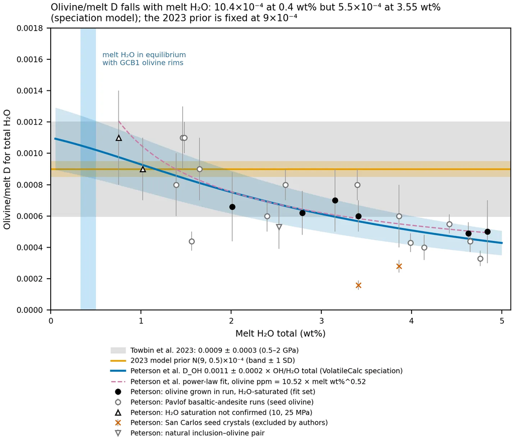

Figure 12.1: Olivine/melt partitioning of total H2O falls as melt H2O rises if olivine H follows melt OH (Peterson et al.), while the Towbin et al. (2023) value is constant; the two agree near 1 wt% melt H2O. Points: Peterson et al. experiments (10–200 MPa, 1000–1220 °C; filled, the six H2O-saturated runs with olivine grown in the run). Blue curve and band: D_OH = 0.0011 ± 0.0002 times the OH fraction from VolatileCalc-basalt speciation. Dashed: Peterson’s power law. Grey band: Towbin et al. (2023), 0.0009 ± 0.0003. Orange: the 2023 model prior. Light-blue column: melt H2O in equilibrium with the GCB1 olivine rims. Coefficients are dimensionless (times 10⁴ for ppm per wt%).

Two published treatments are compared (Figure 12.1, Table 12.5):

- **Towbin et al. (2023): constant K = 9 ppm per wt% (0.0009 ± 0.0003).** It combines earlier experiments recalculated onto the revised opx-standard SIMS calibration (KBH-1 = 202 ppm) with inclusion–olivine pairs, and it resolves no dependence on melt H2O or pressure below 2 GPa. Its ±33 % range is run as three fits (K = 6, 9, 12), each with a 15 % prior. The 2023 MATLAB prior, N(9, 0.5), was six times narrower than the paper; the deposited Fig. 11 caption value of 0.009 is a typo for 0.0009.
- **Peterson et al. (Am Min 111): olivine H follows melt OH,** with D_OH = 0.0011 ± 0.0002 and the OH fraction from VolatileCalc-basalt speciation (`scripts/model_choices/speciation.py`, which reproduces their 25 glasses to ≤ 0.005 wt%). The effective K is then 6.5 at 2.72 wt% melt H2O, 9.5 at 0.9 wt% and about 11 below 0.3 wt%. It enters the fit as an effective path, K0 × OH(H), with K0 = D_OH ~ N(11, 1.8) integrated out as before.

**The Peterson power law is only a sensitivity bound.** Peterson et al. print $C_\mathrm{ol} = 10.52\,C_\mathrm{melt}^{0.52}$ once, “for ease of adaptation of existing code”, fitted to six H2O-saturated grown-olivine runs spanning 2.0–4.8 wt% melt H2O; an unweighted refit of those six gives a coefficient of 10.2 ± 2.3 and an exponent of 0.54 ± 0.17. D_OH and the power law agree above about 1.5 wt% (17.6 against 17.7 ppm at 2.72 wt%) but diverge below it: the power law’s effective K rises without limit as melt H2O approaches zero (19 at 0.3 wt%, 32 at 0.1 wt%), while D_OH levels off near 11. On the wet path the power law gives 0.083 MPa/s extrapolated and 0.104 when K is held constant (12.1) below the lowest experiment (0.75 wt%). About a third of the halving comes from that extrapolation; the rest comes from 0.75–2 wt%, constrained only by two undersaturated runs about 200 °C hotter. The olivine rate is most sensitive to K in the last 1–2 wt% of degassing, where the rim forms and partitioning is least constrained. D_OH is therefore the Peterson case, and the power law is a bound on low-H2O partitioning, not a preferred model.

Table 12.5: The two pyroxene anchorings agree once the intact interior cores are used. Mineral/melt partition coefficients used in the fits, with the rate each gives on the MiMiC MagmaSat path at 1200 °C (olivine Ol-2; WHT1 exterior opx and cpx; CO2/Nb start: 0.155, 0.287, 0.82; the K = 6 value is for the CO2/Nb start).

| Phase | Strategy | K (ppm per wt%) | Prior 1σ | Basis | Wet-start isothermal rate (MPa/s) |
| --- | --- | --- | --- | --- | --- |
| Olivine | **Towbin et al. 2023** | **9** (6, 12 as alternatives) | 15 % | Recalibrated experiments and inclusion pairs | **0.143** (K = 6: 0.355 on the CO2/Nb start) |
| Olivine | Peterson D_OH | 11 × OH/H2O (6.5 at 2.72 wt%, about 11 below 0.3 wt%) | D_OH ~ N(11, 1.8) | Melt OH speciation | 0.146 (0.94×) |
| Olivine | Peterson power law | 10.52 × H<sup>0.52</sup> / H | none | Six-run convenience fit | 0.104 held to calibration; 0.083 extrapolated |
| Opx | Core/start | Intact interior core ÷ H(P0): 411 ppm ÷ 3.48 wt% ≈ 118 | 10 % | Cores equilibrated with the start | 0.29 |
| Opx | Opx-anchored (= experiment) | Novella et al. 2014 × 0.93 at the WHT1 opx Al2O3 = 117.7 | 15 % | Growth experiments on the revised opx scale | 0.256 |
| Cpx | Core/start | Intact interior core (390 ppm) ÷ H(P0) | 10 % | As opx | 0.87 |
| Cpx | Opx-anchored | Opx K × the intact cpx/opx core ratio (390/411) | 15 % | Mineral-pair equilibrium | 0.728 |
| Cpx | Experiment | Recalibrated O’Leary eq. 10 refit (WHT1 0.0073–0.0074, × 10⁴) × {0.61, 1, 1.65} | 15 % each | Growth experiments | Sensitivity only |

## 12.7 Pyroxene diffusivities and partitioning

**K strategies.** The xenolith pyroxenes did not grow from the host melt: H that diffuses into them decorates inherited defects, so experimental K are a prior, not a law. The evidence that they re-equilibrated with the host is that all three phases scale with the magma between volcanoes and that cpx/opx in the same xenolith (0.96–1.38) matches the experimental mineral/mineral ratio (Aubaud et al. 2004: 1.4 ± 0.3). Each pyroxene profile is therefore fitted three ways (Table 12.5): core/start (the boundary starts at the measured core, the 2023 approach), opx-anchored (Novella × 0.93 for opx, the opx value times the cpx/opx core ratio for cpx), and experiment-based. The 0.93 factor puts Novella’s opx on the revised opx SIMS scale of the xenolith data (Towbin et al. 2023). The 2023 priors (opx N(90, 5), cpx N(120, 5)) have no literature source and are not used.

**The intact cores fix the start.** The deepest core points of the interior WHT1 grains (opx 413.5 and 408.5 ppm, mean 411; cpx 375.6 and 404.4, mean 390) are taken as the cores that kept the host-melt value (`scripts/decompression/fit_wet_primary.py`). With them, core/start K for opx is about 118, equal to the opx-anchored 117.7, and the opx core implies 3.48 wt% melt H2O, within 2 % of the MiMiC start (3.549) and 3 % of the CO2/Nb start (3.59). Only the two deepest points reach these levels (409–413 ppm), while two grains flatten near 300–320 ppm; the main text treats that as an uncertainty in K or in the starting H2O (Chapter 9). The exterior opx (0.5 mm from the xenolith exterior) is effectively unbuffered, and the exterior cpx (7.5 mm in) is moderately buffered, which changes its implied D by less than 0.1 log units.

**Pyroxene D from the olivine rate.** The 2023 approach fits olivine first and then asks what pyroxene D its rate implies. Property 1 makes this exact: a pyroxene profile fixes $\tau_\mathrm{px}$, so a known v gives $\log D = \log\tau + 2\log L + \log v - \log(P_0 - P_f)$. Two versions were run (`pyroxene_d_from_olivine.py`, `pyroxene_d_on_path.py`, `joint_d_fit.py`):

- **Method A** combines each pyroxene’s τ posterior (flat log D prior, 10⁻¹⁵ to 10⁻⁸ m²/s) with independent draws of the olivine v posterior. Check: the implied opx-exterior D equals the bracket midpoint × v_ol/v_opx (10<sup>−11.08</sup> against 10<sup>−11.09</sup>).
- **Method B** fits one history to Ol-2, the WHT1 exterior opx and cpx together, with free log D for opx and cpx and olivine fixed at Ferriss [100]. Run on the P–T path with `joint_d_fit.py --slope S`, each phase diffuses on its own warped clock (same Ea as above). The warped-time solver agrees with the warped-pressure model within 0.21–0.55 % of the initial value, the same as at 1200 °C (0.24–0.57 %).

| WHT1 exterior | Isothermal 1200 °C | On the path: D at 1200 °C (SR-wide) | On the path: D at the water-loss temperature (55 MPa) |
| --- | --- | --- | --- |
| Opx, core/start; opx-anchored | −11.06; −11.05 | −11.05 (−11.26 to −10.85); −11.04 | −11.25 (−11.54 to −10.96); −11.24 |
| Cpx, core/start; opx-anchored | −11.54; −11.51 | −11.57 (−11.77 to −11.37); −11.54 | −11.73 (−12.02 to −11.45); −11.70 |
| Joint fit, opx; cpx (82.8 °C/GPa) | −10.98; −11.47 (isothermal joint) | −11.00; −11.53 | not reported |

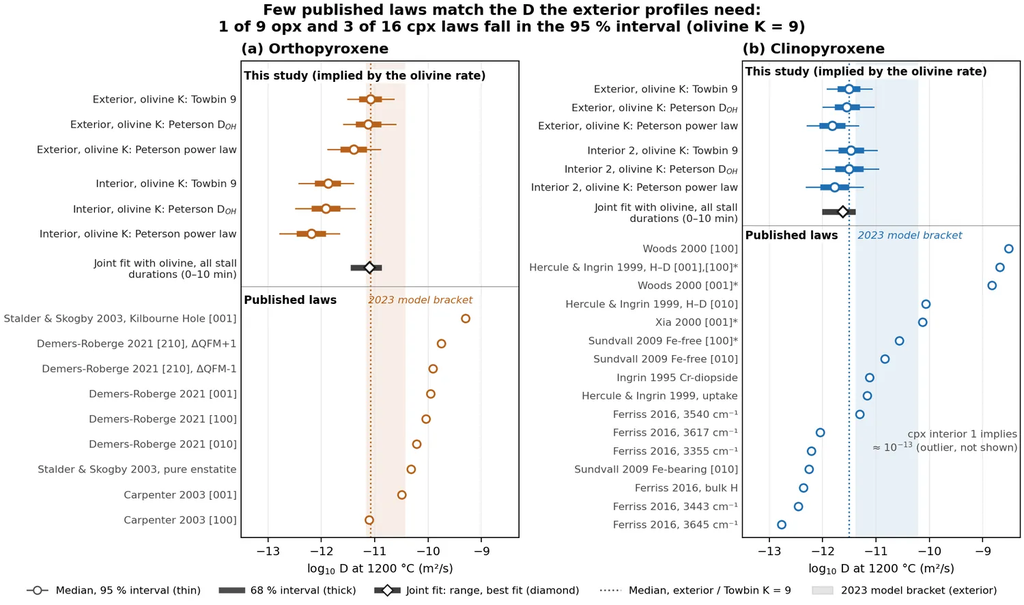

Figure 12.2: Few published pyroxene laws match the H diffusivity that the SR exterior profiles need to agree with the olivine rate: 1 of 9 opx laws (Carpenter 2003 [100]) and 3 of 16 cpx laws fall in the 95 % interval. Implied log10 D at 1200 °C for WHT1 opx (a) and cpx (b) from the olivine posterior (circle, median; thick bar, 68 %; thin bar, 95 %; one row per olivine K option, opx-anchored pyroxene K), and the range of the joint fit across stall durations (diamond), against published laws (open circles). Shaded: the 2023 model bracket. These fits use the mixture start (2.72 wt%) at 1200 °C; the wet start and the P–T path shift the implied D by 0.15 log units or less (Table 12.6).

## 12.8 Olivine edge tests

Measured olivine edges often stay above zero, in natural phenocrysts and in dehydration experiments (Newcombe, Ferriss, Barth), which suggests a diffusion–reaction process near the rim. Two treatments were tested on Ol-2.

**The final-pressure prior** (`scripts/decompression/olivine_pf_sensitivity.py`). In the NAM model the edge value at the end of ascent is K × H(Pf), the treatment of Barth et al. (2024). The 2023 prior capped Pf at 5 bar and the posterior pressed against it (3.3 bar). Widening it to 0–20, 0–50 and 0–200 bar moves the fitted Pf to 10–17 bar (edge boundary 1.8–2.4 ppm) and the rate within 0.155–0.164 MPa/s with K = 9 (0.146–0.160 with Peterson D_OH). Given room, the data prefer a quench pressure of about 1–2 MPa, comparable to the about 2 MPa used by Newcombe’s group. Ol-2 is insensitive because its outermost analysis is 23 µm in (4.4 ppm), so the profile does not sample the true edge.

**A two-population model after Barth et al. (2023)** (`scripts/decompression/olivine_barth_effects.py`). Mobile H diffuses with the Barth start-of-run [100] law (4 × 10⁻¹⁰ m²/s at 1200 °C) and is in equilibrium with the melt at the edge; trapped H is immobile and relaxes toward r × mobile at a rate k; the total equilibrium partitioning is K = 9. In the fast-exchange limit this is one species with $D_m/(1 + r)$; with slow exchange the mobile H drains while the trapped H stays, giving a high edge and an apparent D that falls with time, Barth’s “apparent locking of H+ at the crystal edge”. v is fitted for trapped fractions 0.2–0.67 and k = 10⁻⁵–1 s⁻¹ on the wet path (P0 585 MPa, Pf 1 MPa, σ 0.25 ppm), with Crank–Nicolson for mobile H and an exact exponential exchange step. Controls: with no trapping the model reproduces the single-D fit, and with r = 1 and fast exchange it equals a single species with D/2 to < 0.01 ppm.

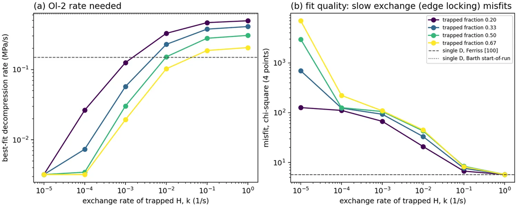

Figure 12.3: Barth-type edge locking cannot fit Ol-2: only fast exchange of trapped H (k ≳ 0.1 s⁻¹) reproduces the profile, and then the model reduces to an effective diffusivity. (a) Best-fit Ol-2 decompression rate and (b) misfit (χ², 4 points) against the exchange rate of trapped H, for trapped fractions 0.2–0.67, in a two-population model whose mobile H diffuses with the Barth et al. (2023) start-of-run [100] law (wet SR-1 MagmaSat path, 1200 °C, K = 9). Dashed: single D, Ferriss [100] (0.150 MPa/s, χ² 5.7). Dotted: single D, Barth start-of-run (0.62 MPa/s). Rates of 0.003 MPa/s at k ≤ 10⁻⁴ s⁻¹ are the bottom of the search grid and belong to rejected fits.

Figure 12.3 shows the result. Fast exchange (k = 1 s⁻¹) fits as well as a single D (χ² 5.7–5.8) at 0.21–0.50 MPa/s; slow exchange (k ≤ 0.01 s⁻¹, which gives Barth-like edges at 11–53 % of the initial) fits badly (χ² 21–7000). Slow edge locking is inconsistent with Ol-2, which kept only about 25 % of its equilibrium start, because an immobile pool of ≥ 20 % cannot leave. Barth’s effects therefore collapse to an effective D, and the bulk laws for natural olivine (Ferriss, Barth end of run) give 0.13–0.15 MPa/s, inside the diffusivity-law range. The test assumes Ol-2 started in equilibrium with the deep melt; its early-grown Fo 88 core supports that. The pyroxenes were not tested, since Barth’s effects are documented for olivine only.

## 12.9 Stall and post-eruptive tests

Could a stall, rather than the pyroxene diffusivities, explain why the three minerals give different single-ascent rates? Two tests were run with the 2023 pyroxene diffusivities fixed and the mixture start (2.72 wt%) at 1200 °C (`scripts/decompression/scenarios.py`, `stall_fit.py`). They are summarized here because the joint fit with free pyroxene D supersedes them: with the 2023 diffusivities a short stall halved the misfit, but the joint fit with free pyroxene D needs no stall.

- **Forward scenarios.** Each phase was modeled with its own radius, D (bracket midpoint) and K under continuous ascent, a stall (ascent to Ps, a closed hold at H(Ps), final ascent) or a post-eruptive hold at the surface value, then refitted with the continuous model with only v free. The Crank–Nicolson solver matches the NAM forward model to 0.5 %. Stalls at 15–30 MPa push the wrong way (the olivine resets during the stall, while the pyroxenes carry it, so the pyroxenes look slower than olivine). Only a hold at the very end (a stall shallower than about 5 MPa, or time at the surface before quench) makes olivine slower than the pyroxenes. History cannot separate opx from cpx, because their bracket-midpoint D are nearly equal. Core reset times ($L^2/D$) are 3.6 min (olivine), 14 min (cpx) and 34 min (opx), so the survival of the Ol-2 profile limits any post-eruptive hold to well under the olivine reset time.
- **Joint stall fit with the 2023 D.** One history was fit to all three phases with the stall pressure set by the flat GCB1 xenolith-olivine plateau (Ol-6, 7.2–7.8 ppm, giving 16.6 MPa). A pause under 2 min after a fast deep ascent halved the misfit on every olivine calibration, stalls of 10 min or more fit worse than none, and even the best fits were poor (χ² 153–317 for 20 points, mostly cpx); the best final ascent stayed at 0.07–0.3 MPa/s.

With the MiMiC start and free pyroxene D a stall is not needed at the central slope (Table 12.7 shows the CO2/Nb-start stall scan). Continuous ascent gives χ² 20.0 isothermally against 20.2 for the best 5-minute stall, and 1–3 min stalls fit worse than continuous ascent. On the P–T path continuous ascent is best at 82.8 °C/GPa (χ² 20.6 against 20.7) and at 120 °C/GPa (20.4 against 24.0); at 46 °C/GPa a 5-minute stall fits better (20.3 against 22.0). The stall-free final ascent is 0.100 MPa/s at 82.8 °C/GPa. With the CO2/Nb start continuous ascent was best at every slope (χ² 19.5–19.9) and gave 0.112 MPa/s. The mild stall preference found with the mixture start (Δχ² 10–14 for 2–3 min) was partly an artifact of that start. A post-eruptive hold would make every apparent rate slower than the true one, so it cannot explain a fast rate.

Table 12.7: With the pyroxene diffusivities free, continuous ascent fits all three minerals as well as any stall. Joint fit of one ascent history to Ol-2 and the WHT1 exterior opx and cpx, CO2/Nb start (SR-1; MiMiC start isothermal: continuous 0.158 MPa/s, χ² 20.0), MagmaSat, isothermal 1200 °C, SIMS-dataset olivine calibration; the stall pressure is set by the xenolith-olivine plateau. Diffusivities (m²/s) are at 1200 °C.

| Stall at 15.4 MPa | Final ascent v₂ (MPa/s) | χ² olivine / opx / cpx | χ² total (20 points) | log10 D opx | log10 D cpx |
| --- | --- | --- | --- | --- | --- |
| none (continuous) | 0.18 | 14.0 / 0.9 / 6.3 | 21.2 | −10.98 | −11.47 |
| 1 min | 0.10 | 15.1 / 7.3 / 14.0 | 36.4 | −10.58 | −11.05 |
| 3 min | 0.18 | 9.7 / 4.5 / 10.3 | 24.5 | −10.64 | −11.11 |
| 5 min | 0.28 | 8.6 / 3.1 / 7.9 | 19.6 | −10.75 | −11.22 |
| 10 min | 0.35 | 12.4 / 3.1 / 6.6 | 22.1 | −10.99 | −11.47 |

## 12.10 Fe–Mg residence of Ol-2

Ol-2’s Fe–Mg profile gives the time it sat in the final carrier melt, which is much longer than the H ascent (about 1.6 h from 585 MPa at 0.1 MPa/s), so its H re-equilibrated before ascent, the equilibrium start assumed at P0. The EMPA traverse runs along the same line as the SIMS H traverse, which is along [100], so the [100] fits are the result and the [001] fits (the fastest Fe–Mg axis) are a lower bound on time (Figure 12.5, Table 12.8).

The headline fit holds the crystal edge at Fo 79.7. A backscattered-electron (BSE) gray profile of Ol-2, taken near the EMPA line, scales linearly to the EMPA Fo (Fo = 98.2 − 0.183 × gray, RMS 0.17 Fo, 24 points) and reaches Fo 79.7 at the outermost clean pixel, 1.6 µm from the edge, 1 Fo below the outermost EMPA point. With the edge held, the two-step start gives 18.4 d (15.7–21.3) and fits the outer 10 µm; the time barely changes from the edge-free fit (18.3 d). The BSE profile also shows the 40–90 µm shoulder that every model misses, so the misfit there is in the grain, not the analyses (Figure 12.4).

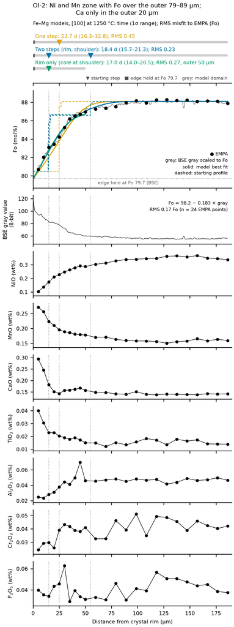

Figure 12.4: Ni and Mn zone with Fo over the outer 80–90 µm of Ol-2; Ca only over the outer 20 µm. EMPA Fo and minor oxides, BSE gray value and Fo scaled from it, against distance from the crystal edge, with three Fe–Mg starting profiles (edge held at Fo 79.7) and their fits; dotted lines mark the starting steps.

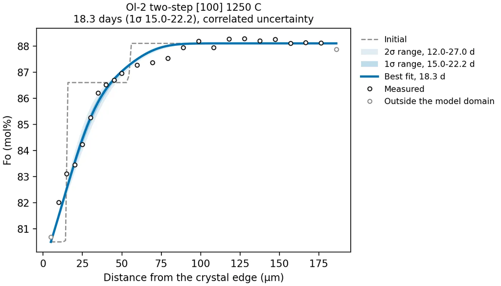

Figure 12.5: Ol-2’s Fo profile is fitted by about 18 days of Fe–Mg diffusion along [100] at 1250 °C from a two-step starting profile. Points: EMPA Fo of Ol-2 (GCB1 roadside scoria) against distance from the crystal edge; grey points lie outside the model domain. Dashed: the fitted two-step starting profile (rim and inner shoulder). Line and bands: best fit (18.3 d) with 1σ (15.0–22.2 d) and 2σ (12.0–27.0 d) ranges. The points at 60–90 µm sit about 0.5 Fo below the model, so the inner shoulder may be partly growth zoning.

Table 12.8: Ol-2 sat in the evolved carrier for weeks, the roadside xenocrysts for hours and the pit xenocrysts for days; the stall-free shape matters little (16 against 18 days). Fe–Mg diffusion times of SR olivines from FORSTER at 1250 °C, 500 MPa, QFM + 0.3 (Dohmen & Chakraborty 2007); at 1200 °C every time is 2.1 times longer.

| Grain (locality) | Starting profile | Fe–Mg time, 1σ | Note |
| --- | --- | --- | --- |
| Ol-2 (roadside), [100] | Two steps (rim, shoulder), edge held at Fo 79.7 | **18 d (16–21)** | Fits the outer 10 µm; misfit 0.23 Fo |
| Ol-2, [100] | Two steps, edge free | 18 d (15–22); 12–29 d with the starting profile free | Correlated misfit 0.0021 Fo, against 0.0016 point scatter |
| Ol-2, [100] | Rim stage only / one step, edge held | 17 d (14–20) / 23 d (16–33) | One step misses the shape |
| Ol-2, [100] | Rim stage only (5–50 µm) | 16 d (13–20); 11–30 d free | Same time as two steps |
| Ol-2, [100] | One step | 18 d (13–27); 50 d with the step free | Misses the shape; the free step runs to the rim |
| Ol-2, [001] | Two steps / rim only | 3.1 d (2.5–3.7) / 2.7 d (2.2–3.3); 2–5 d free | Fastest-axis bound |
| ol6, profiles 1 and 2 (roadside xenocryst) | Database setup | 0.15 d (0.10–0.21), 0.21 d (0.18–0.23) | Thesis: 0.24, 0.23 d |
| ol23 (roadside xenocryst) | Database setup | 0.37 d (0.32–0.42) | Thesis: 0.79 d |
| ol43, ol48 (pit xenocrysts) | Database setup | 1.9 d (1.5–2.4), 3.0 d (2.8–3.3) | Thesis: 2.5, 3.8 d |

## 12.11 Xenolith exchange: supporting tables

Table 12.9: Only the large interior grains keep intact cores (about 410 ppm), so they, not the core/rim ratios of depleted grains, anchor the starting H. Core loss predicted for each WHT1 opx traverse with grain-boundary-type transport, and the initial value it implies from the measured core; distances are from the xenolith exterior. Mixture-start run.

| WHT1 opx traverse | Half-width (µm) | Predicted core / initial | Implied initial (ppm) | Measured core (ppm) |
| --- | --- | --- | --- | --- |
| Exterior-1 opx-2 (0.5 mm) | 173 | 0.91 | 347 | 315 |
| Exterior-2 opx-1 (7.5 mm) | 106 | 0.77–0.79 | 335–343 | 264 |
| Interior opx-1 (40.5 mm) | 266 | 0.98–0.99 | 419–421 | 413 |
| Interior opx-2, long traverse (40.8 mm) | 298 | 0.99 | 412–413 | 409 |
| Interior opx-2, short traverse (40.8 mm) | 106 | 0.82–0.87 | 347–370 | 303 |

Table 12.10: Grain-boundary transport predicts the rim depletion of three of five WHT1 opx traverses; the melt network and a water-keeping melt reservoir predict none beyond the exterior grain. Measured rim/core against the rim/core each mechanism predicts for that grain (uniform start, mixture-start run), and the fractional drop of the grain’s boundary by the end of ascent in the nested fit. The 0.79 value for the 7.5 mm grain is not in the wet-path results [CHECK].

| WHT1 opx traverse (distance from exterior) | Measured rim/core | Predicted, grain boundaries (Demouchy / fitted D) | Predicted, melt network | Predicted, hybrid with water-keeping melt | Boundary drop at end of ascent (nested fit) |
| --- | --- | --- | --- | --- | --- |
| Exterior-1 opx-2 (0.5 mm) | 0.31 | 0.45 / 0.46 | 0.82 | 0.78 | 0.98 |
| Exterior-2 opx-1 (7.5 mm) | 0.60 | 0.58 / 0.63 | 1.00 | 1.00 | 0.79 |
| Interior opx-1 (40.5 mm) | 0.83 | 0.77 / 0.85 | 1.00 | 1.00 | 0.49 |
| Interior opx-2, long traverse (40.8 mm) | 0.51 | 0.69 / 0.80 | 1.00 | 1.00 | 0.49 |
| Interior opx-2, short traverse (40.8 mm) | 0.80 | 0.77 / 0.87 | 1.00 | 1.00 | 0.49 |

## 12.12 Code and checks

The model, the G table and the posterior are `~/Projects/H2O_Diffusion_NAM/decompression/` (`newcombe.py`, `cases.py`, `bayes.py`; derivations and validation in `METHODS.md`). The SR fits are in `scripts/decompression/`: `fit_2026.py` (K strategies and paths), `fit_wet_primary.py` (wet start with the intact cores), `fit_pt_path.py` (warped pressure), `fit_pt_path_pointsigma.py` with `point_sigma.py` (per-point σ), `olivine_d_laws.py`, `pyroxene_d_from_olivine.py`, `pyroxene_d_on_path.py`, `joint_d_fit.py` (with `--slope`), `olivine_pf_sensitivity.py`, `olivine_barth_effects.py`, `scenarios.py`, `stall_fit.py` and `solubility_t.py`. Commands are in Chapter 16. Profiles, σ, L, the D brackets and the P0 and Pf priors are the 2023 case definitions (Table 12.1). The degassing paths are the closed-system MagmaSat and Iacono-Marziano paths of `data/degassing_paths_2026` at 1200 °C, with a final (0 bar, 0 wt%) point appended as in 2023.

Checks: port fidelity to the MATLAB (≤ 1e-14 relative; 1,000 saved fits replayed); the two exact properties and the closed-form K marginal; grid convergence and coverage on synthetic data; the r = 1 control and the direct-solver comparison for the warped pressure; the Ferriss-law control of the law sweep; the no-trap and fast-exchange controls of the edge model; the solver and continuous-history controls of the stall model; and the reproduction of the fixed-σ posteriors by the per-point-σ script (106 of 106 rows).

# 13 Melt-inclusion methods

This appendix holds the melt-inclusion method detail behind Chapter 6 and the starting melt of the ascent models: the three MiMiC versions and their error budget, the bubble equation of state, which MiMiC run sets the P–T path, the LA-ICP-MS and host checks, the olivine-overlap correction, GC2_ol4, and the CO2 basis of the start (CO2/Nb against CO2/Ba).

## 13.1 Three MiMiC versions

MiMiC (Rasmussen et al. 2020) corrects each inclusion for post-entrapment crystallization (PEC) and adds back the CO2 in the vapor bubble with a bubble-growth model. Three versions are compared:

1. **Original (as published), on the 2023 inputs.** The MiMiC run behind the 2023 paper and Table 3 of the deposited chapter. The vendored code reproduces it exactly: a control run of the 2023 input file matches every point value (H2O, CO2, bubble-corrected CO2, entrapment pressure, glass pressure, Fo) to the 2-decimal rounding of the 2023 output (max |difference| 0.005).
2. **Original code on the 2026 inputs** (`data/mimic_2026`). The 2026 input file carries new EMPA compositions and the recalibrated NanoSIMS H2O and CO2 for the pit (AZ18-06) inclusions (for example Ol23 glass H2O 3.8 against 3.6 wt%). The roadside AZ09 inclusions and the Cima and Vulcan’s Throne inputs are unchanged, and so are their results. This is the base run: it sets the inclusion points on the P–T path.
3. **Modified MiMiC, the production version for the inclusion tables** (`data/mimic_2026_dz`). Everything is as in version 2 except the CO2 molar volume at the two bubble sites. The published code uses a Redlich–Kwong volume of pure CO2 multiplied by the vapor CO2 mole fraction; the modified code uses the Duan & Zhang (2006) H2O–CO2 mixture volume at MiMiC’s own vapor composition.

The published construction has two errors that partly cancel. Its Redlich–Kwong CO2 volume is 6–8 % too small (against Span–Wagner), which gives too much CO2. Treating the CO2 mole fraction as a volume fraction ignores the H2O in the vapor, which gives too little CO2 for H2O-rich vapor. For SR (vapor CO2 mole fraction 0.35–0.52 in the key inclusions) the second error is larger, so the modified version adds bubble CO2. Table 13.1 gives the values for the 12 SR inclusions used in the P–T path fits.

Table 13.1: The code change (v2 to v3) moves only bubble CO2 (0 to +15 %), entrapment pressure (0 to +8 %) and entrapment temperature (≤ 1.2 °C across the SR set), while the input change (v1 to v2) moves the pit inclusions’ H2O by +0.1 to +0.2 wt%. v1 is the original MiMiC on the 2023 inputs (deposited Table 3), v2 the original code on the 2026 inputs, v3 the modified MiMiC with the Duan & Zhang (2006) bubble. H2O is identical in v2 and v3. Olxx is not in the deposited Table 3; its v1 values are the control rerun of the 2023 input, identical to v2. Ol36_2 moved because its CO2 input changed from 2608 to 666 ppm. The deposited Table 3 also has a GC2_ol4 row, which carries GC2_ol3’s volatiles (Section 13.10). Data: `data/mimic_2026/summary.csv`, `data/mimic_2026_dz/summary.csv`.

| Inclusion (locality) | H2O, wt% (v1 / v2 = v3) | Bubble-corrected CO2, ppm (v1 / v2 / v3) | Entrapment pressure, MPa (v1 / v2 / v3) | Entrapment T, °C (v1 / v2 / v3) |
| --- | --- | --- | --- | --- |
| Ol23 (pit) | 3.36 / 3.55 | 5518 / 5352 / 5755 | 408 / 418 / 433 | 1168 / 1166 / 1167 |
| Ol21 (pit) | 3.30 / 3.47 | 4533 / 4414 / 4751 | 379 / 389 / 403 | 1141 / 1139 / 1140 |
| Ol19 (pit) | 2.89 / 3.05 | 3344 / 3246 / 3495 | 276 / 286 / 296 | 1161 / 1160 / 1160 |
| Ol35 (pit) | 2.73 / 2.88 | 1724 / 1683 / 1757 | 199 / 208 / 212 | 1142 / 1141 / 1141 |
| Olxx (pit) | 2.41 / 2.41 | 2374 / 2374 / 2417 | 215 / 215 / 218 | 1139 / 1139 / 1140 |
| Ol36_1 (pit) | 1.97 / 2.09 | 1208 / 1132 / 1162 | 137 / 136 / 138 | 1086 / 1084 / 1084 |
| Ol36_2, second EMPA (pit) | 1.97 / 2.04 | 3839 / 1090 / 1110 | 304 / 132 / 134 | 1078 / 1065 / 1066 |
| GC2_ol3 (roadside) | 2.24 / 2.24 | 6185 / 6185 / 6191 | 574 / 574 / 574 | 1148 / 1148 / 1148 |
| GC2_ol5 (roadside) | 2.80 / 2.80 | 3332 / 3332 / 3825 | 271 / 271 / 291 | 1168 / 1168 / 1169 |
| GC2_ol7 (roadside) | 2.70 / 2.70 | 8529 / 8529 / 9079 | 510 / 510 / 531 | 1198 / 1198 / 1199 |
| GC2_ol8 (roadside) | 1.96 / 1.96 | 5779 / 5779 / 5781 | 453 / 453 / 453 | 1183 / 1183 / 1183 |
| Ol11, corrected (roadside) | 2.40 / 2.40 | 3836 / 3836 / 3821 | 420 / 420 / 419 | 1193 / 1193 / 1193 |

Across whole eruptions the median change in bubble-corrected CO2 from v2 to v3 is +3.4 % for SR (13 inclusions with a bubble), −0.9 % for Vulcan’s Throne and −1.1 % for Cima. The maximum-H2O inclusion (Ol23) and the maximum bubble-CO2 inclusion (GC2_ol7) are the same in every version.

The H2O–CO2 pattern of the three volcanoes does not change with the version (Chapter 6). Across 39 inclusions the Duan & Zhang correction changes bubble-corrected CO2 by −2.8 to +14.8 %, and 34 stay within ±5 %.

## 13.2 Monte Carlo uncertainty and error budget

MiMiC reports the unperturbed draw as the value and the standard deviation of the perturbed draws (after a modified-z filter) as 1σ. For the four normal key inclusions the reported value is within 2.4 % (bubble CO2) and 6.3 % (entrapment pressure) of the Monte Carlo median, and the 1σ agrees with the 16–84 % half-width to within 11 %. The distributions are right-skewed: for Ol23 in the original code, entrapment pressure is 418 MPa with a 95 % range of 307–643 MPa, and bubble CO2 is 5352 ppm with a 95 % range of 2795–9633 ppm. In the modified version Ol23 is 5755 ± 2822 ppm and 433 ± 107 MPa; the H2O 1σ (0.36–0.37 wt%) is at least 93 % analytical error.

Table 13.2: Most of the bubble-CO2 uncertainty is MiMiC’s own assumed spread in CO2 closure temperature and MgO diffusivity, and most of the pressure uncertainty is the assumed 5 % major-element error. Percent of the Monte Carlo variance removed when each source is switched off (300 paired draws, original code); shares are not additive, and the host Fo error contributes 0–2 %. Data: `data/mimic_methods_2026/tables/budget_n300.csv`.

| Inclusion | Quantity | 1σ | CO2 closure T spread (±17.5 %) | MgO diffusivity spread (±10 %) | Major-element errors (5 %) | H2O and CO2 errors |
| --- | --- | --- | --- | --- | --- | --- |
| Ol23 | Bubble-corrected CO2 | 2088 ppm | 23 | 23 | 19 | 9 |
| Ol23 | Entrapment pressure | 88 MPa | 17 | 3 | 43 | 27 |
| GC2_ol7 | Bubble-corrected CO2 | 2341 ppm | 24 | 25 | 14 | 11 |
| GC2_ol7 | Entrapment pressure | 135 MPa | 11 | 2 | 60 | 1 |

Table 13.2 shows that the bubble-CO2 1σ (27–39 % of the value) is mostly model spread, not measurement. The pressure 1σ is mostly the 5 % major-element error, which is large for EMPA SiO2; with 1 % errors the Ol23 pressure 1σ falls from 88 to 69 MPa and GC2_ol7’s from 135 to 85 MPa. Real EMPA errors for these glasses are not in the sources [CHECK: EMPA errors of the inclusion glasses].

Other candidate changes were measured but not adopted:

- **Fe-loss correction** (initial FeO blank in every input, so not applied): with each vent’s whole-rock FeO it lowers H2O by 3.0–6.5 % (Ol23 3.55 to 3.34 wt%) and raises bubble CO2 by 4.7–8.8 % and entrapment T by 20–53 °C. The recommended SR initial FeO is 11.6–11.9 wt% from the GC2 olivine control line.
- **Fe–Mg Kd model** (Ford 1983 instead of Toplis 2005): H2O −2.5 % (Ol23) to −4.8 % (GC2_ol7), bubble CO2 up to +14 %.
- **Fe3+/FeT for SR** (blank, so fixed at 0.2): 0.167 changes Ol23 H2O by −1.3 % and bubble CO2 by +2.7 %.
- **Solubility model inside MiMiC:** total CO2 of the key inclusions moves −12 to +17 %, more than the bubble equation of state does.
- **Temperature ±30 °C, cooling rate and inclusion size:** ≤ 3 % on any key value.
- **A pure-CO2 bubble** (an upper bound, not a best estimate) would add +55 % (Ol23) and +42 % (GC2_ol7).

## 13.4 Which MiMiC run sets the P–T path

The P–T path keeps the base MiMiC (version 2, as published); the inclusion tables use the production run (version 3) (Table 13.3, Figure 13.1). The modified run was checked on the path by rerunning the inclusion fit (`scripts/pt_path_inclusions.py`) on both outputs; the base run reproduces `results/pt_path/slopes.csv` byte for byte.

Table 13.3: The MiMiC version does not move the P–T slope, so it moves no path family and no rate. Straight-line fits through the Plank & Forsyth (2016) start and the SR inclusions. The headline envelope U(46, 120) °C/GPa does not use the inclusions.

| Quantity | Base MiMiC (v2) | Modified MiMiC (v3) |
| --- | --- | --- |
| Inclusion pressures (Pvbg) | as published | +0 to +7.6 % (largest GC2_ol5, 271 to 291 MPa; GC2_ol7 +4.2 %; pit +1 to +4 %) |
| Entrapment temperature | as published | up to +1.2 °C |
| Slope through the start and all 12 SR inclusions (°C/GPa) | 98.5 (68 %: 89.1–108.5) | 98.3 (88.9–108.4) |
| Slope, pit inclusions only | 104.6 | 104.1 |
| Slope, roadside inclusions only | 82.2 | 82.1 |

By locality, the fit through the inclusions gives 105 °C/GPa (68 %: 95–115) for the pit and 82 °C/GPa (71–95) for the roadside scoria; without the two Ol36 analyses it gives 88 °C/GPa (79–98). At the same pressure the roadside inclusions are hotter (1148–1198 °C) than the pit inclusions (1139–1166 °C), but the two localities overlap within error.

[figure not shown]

Figure 13.1: The SR melt inclusions sit cooler than the Towbin & Plank (2026) path range but on straight lines from the mantle start; the pit and roadside inclusions overlap within error. Left: MiMiC entrapment temperature and vapor-bubble pressure (1σ) of the 12 SR inclusions (pink, pit; blue, roadside scoria) against the Plank & Forsyth (2016) start (star), the Towbin & Plank (2026) range (grey) and Monte Carlo straight-line fits through the start and the inclusions. Bands mark xenolith pickup (1.15 GPa) and the pressure range where the melt has lost half its H2O (< 55 MPa for the MiMiC start; 63 MPa for the CO2/Nb start). Dotted line: MagmaSat saturation of the CO2/Nb start SR-1 (922 MPa; MiMiC start 682 MPa); dash-dot: the 585 MPa start of the diffusion model. Right: slope distributions for all SR inclusions, each locality, and all SR without the evolved Ol36 pair.

## 13.5 Does the MiMiC version change the rates?

Table 13.4 answers this for the decompression rates. Each row uses the same fitting code and K strategies; only the starting melt of the degassing path changes (MagmaSat, closed system, isothermal 1200 °C).

Table 13.4: The MiMiC code version moves every rate by ≤ 1.4 %, the MiMiC Monte Carlo 1σ by about ±4 % (olivine) to ±9 % (pyroxenes), and the choice of starting melt by 8–32 %. Decompression rate in MPa/s, posterior median (68 % range), isothermal 1200 °C. “Recipe” is the highest inclusion H2O (Ol23) with the highest bubble-corrected CO2 (GC2_ol7), as trapped. Absolute values come from the comparison run and differ by a few percent from the headline fits (cpx 0.792 here against 0.82); only differences between rows are meaningful. Data: `results/decompression/mimic_compare/posteriors.csv`.

| Starting melt of the degassing path (H2O wt% / CO2 ppm) | MiMiC version | Olivine Ol-2, K = 9 | WHT1 exterior opx, opx-anchored K | WHT1 exterior cpx, opx-anchored K |
| --- | --- | --- | --- | --- |
| Each fit’s own 2023 path | Original, 2023 inputs | 0.146 (0.110–0.199) | 0.266 (0.134–0.523) | 0.720 (0.276–1.83) |
| 2023 recipe, 3.36 / 8,529 | Original, 2023 inputs | 0.141 (0.107–0.190) | 0.268 (0.135–0.527) | 0.725 (0.278–1.85) |
| 2026 recipe, 3.549 / 8,529 (primary MiMiC start) | Original, 2026 inputs | 0.143 (0.108–0.193) | 0.256 (0.128–0.508) | 0.703 (0.268–1.80) |
| Same, H2O −1σ / +1σ (3.178 / 3.920) | Original, 2026 inputs | 0.147 / 0.140 | 0.276 / 0.234 | 0.736 / 0.664 |
| Same, CO2 −1σ / +1σ (6,038 / 11,020) | Original, 2026 inputs | 0.137 / 0.148 | 0.241 / 0.271 | 0.661 / 0.746 |
| 2026 recipe, 3.55 / 9,079 | Modified (Duan & Zhang), 2026 inputs | 0.144 (0.109–0.195) | 0.260 (0.130–0.513) | 0.713 (0.272–1.82) |
| CO2/Nb start SR-1 (second scenario), 3.59 / 14,100 | Independent of version | 0.155 (0.117–0.211) | 0.287 (0.144–0.565) | 0.792 (0.302–2.02) |
| Mixture batch, 2.72 / 14,100 | Independent of version | 0.174 (0.129–0.244) | 0.342 (0.177–0.653) | 0.914 (0.353–2.31) |

- **Code version, same inputs (rows 3 and 6):** olivine +0.9 % (0.143 to 0.144), opx +1.4 % (0.256 to 0.260), cpx +1.4 % (0.703 to 0.713). The modified code raises the starting CO2 (8,529 to 9,079 ppm), which shifts the saturation pressure of the recipe start by +3.9 % (6783 to 7049 bar with the 2023 H2O), but this hardly reaches the rate, because H2O loss happens below about 60 MPa.
- **Inputs, same code (rows 2 and 3):** olivine +1.4 %, opx −4.4 % (0.268 to 0.256), cpx −3.1 % (0.725 to 0.703). The recalibrated pit H2O matters more than the bubble equation of state.
- **Monte Carlo 1σ of the original code (rows 4 and 5):** olivine 0.137–0.148, opx 0.234–0.276, cpx 0.661–0.746, several times wider than the version effect.
- **Starting-melt choice (rows 6–8):** moving from the as-trapped recipe to the CO2/Nb start SR-1 raises the olivine rate by 8 % (0.144 to 0.155), and the mixture batch by 21 % (0.174). This choice, not the MiMiC version, is the inclusion input that matters.

**Why the headline rate does not depend on the version.** The primary rate on the P–T path starts from the published MiMiC melt (3.549 wt% H2O, 8,529 ppm CO2), the row “2026 recipe, 3.549 / 8,529” of Table 13.4, so the version question applies to it directly: the modified code changes the rate by 1.4 % or less. The second scenario, SR-1, has H2O (3.59 wt%) equal to Ol23’s H2O (3.55 wt%, identical in the two code versions) plus a 0.04 wt% back-calculated loss to CO2-rich vapor before trapping; its CO2 (14,100 ppm) is CO2/Nb 239 times the lava Nb, not a MiMiC value. The vapor-loss term was computed with the modified bubble CO2 and not rerun with the original code [CHECK: vapor-loss term with the original code].

Three things are robust to the choice: every inclusion H2O value (and so the H2O–Cl batch structure and the maximum-H2O inclusion), the identity of the highest-CO2 inclusion (GC2_ol7) with the conclusion that every inclusion trapped a CO2-degassed melt, and the decompression rates (≤ 1.4 %). The 2026 inputs (recalibrated pit NanoSIMS volatiles, corrected Ol36_2 CO2) differ from the 2023 ones, and those changes move the inclusion values more than the code does.

## 13.6 Starting melt: alternatives

The primary ascent start is the published MiMiC melt as trapped. The second scenario, SR-1, adds two corrections to the measured inclusions: the H2O that a CO2-rich bubble removed before trapping, and the CO2 from CO2/Nb. Table 13.5 gives the starts with and without each correction.

Table 13.5: The MiMiC start gives an Ol-2 rate 8 % below the CO2/Nb start, and dropping the bubble H2O moves it by less than that. Sullivan Ranch starting H2O and CO2 under each correction. On the P–T path the MiMiC start gives 0.093 against 0.101 MPa/s for the CO2/Nb start. The wetter-to-drier mixture batch (SR-6, 2.72 wt%) is the larger sensitivity: 0.174 isothermal, 0.113 on the path (CO2/Nb basis [CHECK: not refit from the MiMiC start]).

| Start | H2O (wt%) | CO2 (ppm) | What it assumes | Ol-2 rate, isothermal (MPa/s) |
| --- | --- | --- | --- | --- |
| **Published MiMiC (used)** | **3.549** | **8,529** | Ol23’s PEC-corrected H2O with the CO2 of GC2_ol7, as trapped, partly degassed | **0.143 (0.108–0.193)** |
| SR-1, CO2/Nb (second scenario) | 3.59 | 14,100 | Ol23’s PEC-corrected H2O plus the H2O lost to its bubble before trapping; CO2 from CO2/Nb 239 times Nb 59 ppm | 0.155 (0.12–0.21) |
| MiMiC without bubble H2O | 3.55 | 14,100 | Ol23 as corrected by MiMiC, no H2O returned from the bubble | below the effect of any other choice (0.04 wt% difference) |
| As trapped, modified MiMiC (SR-3) | 3.55 | 9,079 | Ol23 H2O with the highest bubble-reconstructed CO2 (GC2_ol7) from the modified code | 0.144 |
| 2023 start | 3.36 | 8,529 | Published MiMiC on the 2023 inputs | 0.141 |

The 2023 starting melt was the GC2 lava AZ09-UK01 (Plank & Forsyth 2016, Table S5) at Fe3+/FeT ≈ 0.17, with 3.360 wt% H2O and 8,529 ppm CO2 (the 2023 Ol23 H2O and the GC2_ol7 bubble CO2); MagmaSat reproduces the first rows of both 2023 paths to within 2.3 ppm CO2. The 2026 recalibration, in the same recipe, raises the saturation pressure by only 38 bar (0.6 %), because saturation near 680 MPa is CO2-dominated.

## 13.7 CO2 of the start: CO2/Nb or CO2/Ba

The tables show the published MiMiC CO2 first, as the primary start, and the CO2/Nb correction as the second scenario. Bubble-reconstructed CO2 (modified MiMiC) reaches 9,079 ppm (GC2_ol7), and the SR inclusions saturate at 129–574 MPa (Pvbg), shallower than xenolith pickup (1.15 GPa).

**The CO2/Nb estimate.** Undegassed CO2 is CO2/Nb times Nb. With the depleted-mantle ratio 239 (Saal et al. 2002) and the lava’s Nb (59 ppm), CO2 is 14,100 ppm, the start of the second scenario. The ocean-island-basalt ratio, 505 ± 168 (Rosenthal et al. 2015), doubles it (29,800 ppm). Sources: `data/la_sims_2026/endmember_co2.csv`, `scripts/endmember_co2.py`.

- **Every inclusion sits below the undegassed CO2 at either ratio.** On the basis of each inclusion’s own LA-ICP-MS Nb and CO2/Nb 239, the trapped melts had already lost 46–91 % of their CO2 (retained 9–54 %), but at most 0.21 wt% H2O. On the lava-Nb basis the best inclusion (9,079 ppm) has lost 36 % of 14,100 ppm. This appendix quotes the per-inclusion basis unless it says otherwise.
- With each inclusion’s own Nb and CO2/Nb 239, the undegassed CO2 is 11,400–20,500 ppm and the undegassed saturation pressure (Iacono-Marziano) 670–900 MPa, against 190–450 MPa as measured.
- **CO2/Ba was tried and rejected:** it gives 3–7 times more CO2, because the SR Ba/Nb (11.5–16.5) is far above that of the reference pairs.
- **The rate depends on it by about 10 %.** The as-trapped MiMiC start (8,529 ppm) gives 0.143 against 0.155 MPa/s (isothermal) for CO2/Nb 239, and the joint fit 0.100 against 0.112 on the path, since CO2 sets where degassing starts and the H loss happens below about 60 MPa.
- **It matters for the depth story.** With CO2/Nb 239 the start saturates at 922 MPa (MagmaSat; the MiMiC start 682 MPa), close to xenolith pickup; with 505 it saturates at 1.44 GPa, deeper than pickup.

Open questions for co-authors are whether 239 or 505 is the right reference for an enriched alkaline basalt, whether a per-inclusion Nb is better than the lava Nb, and whether the correction is worth making at all (Chapter 11).

## 13.8 LA-ICP-MS against SIMS

LA-ICP-MS traces exist for 7 SR inclusions (GC2_ol3, ol5, ol8, Ol19, Ol35, Ol36_1, Ol36_2), and none for GC2_ol6, GC2_ol7, Ol11, Ol23, Ol21, Olxx or any Cima or Vulcan’s Throne inclusion. Figure 13.2 summarizes the cross-checks.

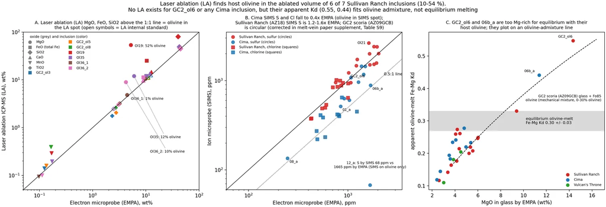

Figure 13.2: Laser ablation finds host olivine in the ablated volume of 6 of the 7 SR inclusions, SIMS S and Cl disagree with EMPA, and the two high-MgO inclusions sit on an olivine-admixture line instead of at Fe–Mg equilibrium. (A) LA-ICP-MS against EMPA content of major oxides for the 7 SR inclusions with LA data (symbol = oxide, color = inclusion; open symbols = the oxide used as the LA internal standard); points above the 1:1 line mean olivine in the LA spot. (B) SIMS against EMPA S and Cl for SR and Cima inclusions (solid line 1:1, dotted 0.5:1). (C) Apparent olivine–melt Fe–Mg Kd against EMPA MgO for all inclusions, with the equilibrium band 0.30 ± 0.03 and the mixing line of GC2 scoria glass plus 0–30 % Fo85 olivine. Data: `data/la_sims_2026/`.

## 13.9 The olivine-overlap correction (GC2 and Vulcan’s Throne)

The SIMS volatiles of the roadside AZ09-GCB inclusions and of Vulcan’s Throne in the deposited tables are not raw. They carry the Plank-lab correction for SIMS overlap with host olivine, which scales each analysis using S, P and Cl; it is not the post-entrapment crystallization correction. Evidence: the 2023 overlap-corrected source table is titled “these have been corrected for overlap with olivine, using S, P and Cl”, with the raw EMPA SO2, P2O5 and Cl beside the corrected SIMS values, and the same values appear in the melt-vein supplement. Two Vulcan’s Throne inclusions marked “hit ol” (no EMPA) are uncorrected, but their Cl is scaled by 1.239 like every row, so Cl was also recalibrated. The MiMiC PEC correction was tested and ruled out (7–16 %, two negative, unrelated). The exact per-inclusion factor could not be reproduced from the EMPA and SIMS ratios (mean, geometric mean, least squares), so the formula is the Plank lab’s [CHECK: ask Terry Plank whether the supplement must state the formula]. No value changed; footnotes mark the affected rows.

## 13.10 GC2_ol4 has no measured volatiles

The 2023 overlap-corrected source table lists EMPA for GC2_ol4 mi 02 but no SIMS volatiles, and Plank & Forsyth (2016) has no row for it. The 2023 MiMiC input gives GC2_ol4 S 1530, Cl 500, H2O 2.39 and CO2 3136, which are GC2_ol3’s values exactly, copied across in 2023. The deposited Table 3 row for GC2_ol4 (H2O 2.16 wt%, CO2 2840 ppm after PEC) is therefore GC2_ol3’s volatiles on GC2_ol4’s composition. The later melt-vein input leaves them blank, correctly. GC2_ol4 stays out of the inclusion tables, and the 2023 edition of the supplement keeps the deposited row with a footnote.

## 13.11 Host candidates and the lava-versus-inclusion liquid line

The degassing paths use the AZ09-UK01 lava as the starting composition. The checks ask whether a better host exists and whether the lava is the parent of the trapped melts (Figure 13.3).

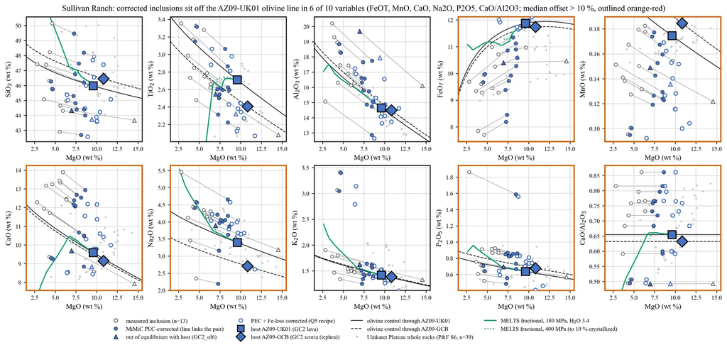

Figure 13.3: The crystallization-corrected SR inclusions sit off the olivine control line through the AZ09-UK01 lava in 6 of 10 variables (FeOT, MnO, CaO, Na2O, P2O5 and CaO/Al2O3; panels outlined), so the lava is not their parent by olivine alone. Oxides and CaO/Al2O3 against MgO (wt%, anhydrous, all Fe as FeOT) for the 13 SR inclusions as measured (open grey circles) and after the MiMiC crystallization correction (filled blue), and after crystallization plus Fe-loss correction (open blue); GC2_ol6 as triangles. Large square: lava AZ09-UK01; large diamond: scoria AZ09-GCB; lines: olivine control lines; green lines: MELTS fractional crystallization of the lava at 180 MPa (3.4 wt% H2O) and 400 MPa; small grey points: Uinkaret Plateau whole rocks (Plank & Forsyth 2016 Table S6, n = 39).

- **AZ09-UK01 is the best SR host candidate.** Among the Plank & Forsyth (2016) magmas it scores best in every variant (combined score 4.97 against 7.02 for the AZ09-GCB scoria; 4.77 against 6.96 with the Fe-loss set). No alternative improves on the 2023 choice.
- **The lava is a liquid but not the parent of the trapped melts.** It is in equilibrium with Fo 85.3, the median GC2 olivine, with no sign of accumulated olivine or mantle debris. No sensible crystallization of up to four phases, and no forward MELTS path, links it to the inclusions within 2σ on every oxide: the inclusions are higher in CaO/Al2O3 and P2O5 (by about 20 %) and lower in TiO2, ratios that olivine cannot change.
- **Fe loss explains most of the apparent gap.** With the recommended initial FeO (11.59–11.73 wt% on the scoria olivine control line; Ol23 11.69, GC2_ol7 11.62), the main inclusion mean comes within 2σ of the lava in 7 of 10 oxides.
- **Effect on the start.** For the 2026 recipe, AZ09-UK01 saturates at 6815–6824 bar; moving it along olivine control to the inclusion mean changes this by −0.4 to +2.2 %, and AZ09-GCB would add 11.6–17.3 %.

## 13.12 Roadside rims and the final melt

The olivine rims differ by locality. The pit phenocryst rims converge on Fo 83.3–85.8 (median 84.5), at equilibrium with the AZ09-UK01 lava whatever their core. The roadside grains end 1–4 Fo lower: Ol-2 at 80.7, ol6 at 81.5–82.6 and ol23 at 83.0. Table 13.6 gives the melts these rims need.

Table 13.6: The roadside rims (Fo 80.7–83) need a melt with 6.6–8.6 wt% MgO, about 6–11 % olivine removed from the AZ09-GCB whole rock, and no measured inclusion samples that melt (the GC2 inclusions record an earlier stage at MgO/FeOT 0.76–0.89, and Ol36 is more evolved at 0.47). Melts in equilibrium with the SR olivine rims from the two whole rocks of Plank & Forsyth (2016), for Fe3+/FeT 0.167–0.20 and Kd(Fe–Mg) 0.30–0.34.

| Whole rock | MgO (wt%) | Equilibrium olivine Fo | Olivine removed to reach rim Fo 83 to 80.7 | Melt MgO (wt%) | Melt MgO/FeOT |
| --- | --- | --- | --- | --- | --- |
| AZ09-UK01 lava | 9.6 | 84.1–85.2 | 2–4 % to 6–8 % | 8.8–6.7 | 0.74–0.58 |
| AZ09-GCB roadside scoria | 10.8 | 85.8–86.8 | 6–8 % to 10–11 % | 8.6–6.6 | 0.74–0.58 |

## 13.13 Methods and code

**MiMiC runs.** MiMiC (Rasmussen et al. 2020), upstream commit 346a3dd, is vendored unchanged in `scripts/mimic/vendor/`. Settings: vb_cor = 1, fe_fixed = 0, fe_cor = 1, kd_model = 0 (Toplis 2005), H2O_diff = 0; 1000 Monte Carlo draws; numpy seed 1. Point values are the unperturbed first draw and do not depend on the seed. The SR Fe3+/FeT is blank in the input, so MiMiC uses a fixed 0.2 without resampling; Cima (0.17) and Vulcan’s Throne (0.23) are given and resampled. Cima and Vulcan’s Throne have no measured uncertainties, so their errors were assumed from the median SR relative errors (`data/mimic_2026/assumed_relative_errors.csv`). A shift of the last error columns in the SR input file was tested by realigning them: point values are identical and 1σ changes by ≤ 12 %.

- **Control.** The 2023 input (42 rows) run through the vendored code with the 2023 settings reproduces the 2023 output and Table 3 to max |difference| 0.005.
- **Speed.** `scripts/mimic/run_mimic.py run --fast --jit --workers 12` is 46 times faster (SR, 1000 draws: 24 s); with the original global seed it is byte-identical to the original code.
- **Modified version.** `scripts/bubble_eos/run_production.py` patches a generated copy of the driver (never the vendored file) at the two bubble CO2 sites. With the patch off, the output is bit-identical to version 2 at 1 and 1000 draws. Each output carries a `.run.json` with the settings, seed, equation of state and file hashes.
- **Error budget.** `scripts/mimic_methods/methods.py` switches off one perturbation source at a time with aligned random streams (300 paired draws).
- **PEC and Fe loss.** MiMiC adds or removes equilibrium olivine until the melt is in Fe–Mg equilibrium with the measured host Fo. The production runs apply no Fe-loss correction. Two code issues were found and left unchanged in the vendored file: the Fe–Mg exchange step uses a factor 2.298 where a 1:1 molar exchange needs 1.7825, and the resampled initial FeO is never used in the Monte Carlo.
- **LA-ICP-MS versus SIMS.** `scripts/la_sims/` reads the melt-vein supplement workbook; olivine in the LA spot is estimated with a two-component mixing model in which the internal-standard oxide sits in the glass only. The test suite has 16 passing tests.
- **Rates by MiMiC version.** `scripts/decompression/fit_mimic_compare.py` reuses the fitting code and K strategies and changes only the degassing path (310 posterior rows).
- **Original volatiles and host checks.** `scripts/original_volatiles/` (VESIcal 1.2.12; MagmaSat in the ENKI ThermoEngine container, with a control reproducing the cached 6814.82 bar), `scripts/starting_melt/` (matching the 2023 path onsets across 399 candidates), `scripts/host_candidates/` and `scripts/lld/` (least-squares mass balance; rhyolite-MELTS 1.2.0 with MnO removed from the bulk, which restores Fe–Mg olivine in this ThermoEngine build). The working logs are indexed in Chapter 16.

# 14 Degassing models

This appendix holds the evidence for the choice of solubility model, the comparison of the four models, the starting-melt paths with their refreshed saturation pressures, the temperature test of the solubility models, and the way the equilibrium boundary meets the measured xenolith rims. The main text uses the result: one closed-system MagmaSat path from the published MiMiC start, with the CO2/Nb start (SR-1) as the second scenario (Chapter 8).

## 14.1 Accuracy on melts like ours

Every degassing path is computed from one starting melt (H2O, CO2, composition, temperature) at its saturation pressure down to 1 bar. Four mixed H2O–CO2 solubility models were compared (Figure 14.1, Table 14.1): MagmaSat, Iacono-Marziano and Dixon (all through VESIcal) and MafiCH (Allison et al. 2022). Shishkina was assessed but not run on the path grid.

Hughes & Saper (2026 preprint) evaluate the VESIcal models on 770 vapor-saturated experimental glasses. Their per-experiment outputs were recomputed for an analog window around the SR melts (volatile-free SiO2 43–49 wt%, Na2O + K2O 3.5–6.8 wt%, T < 1350 °C): 111 experiments on 8 compositions, reaching 620 MPa at most. Recomputing their own Table 2 from these files reproduces the paper (for example MagmaSat −1.6 / 54.7 against their −2 / 55), which checks the scorer.

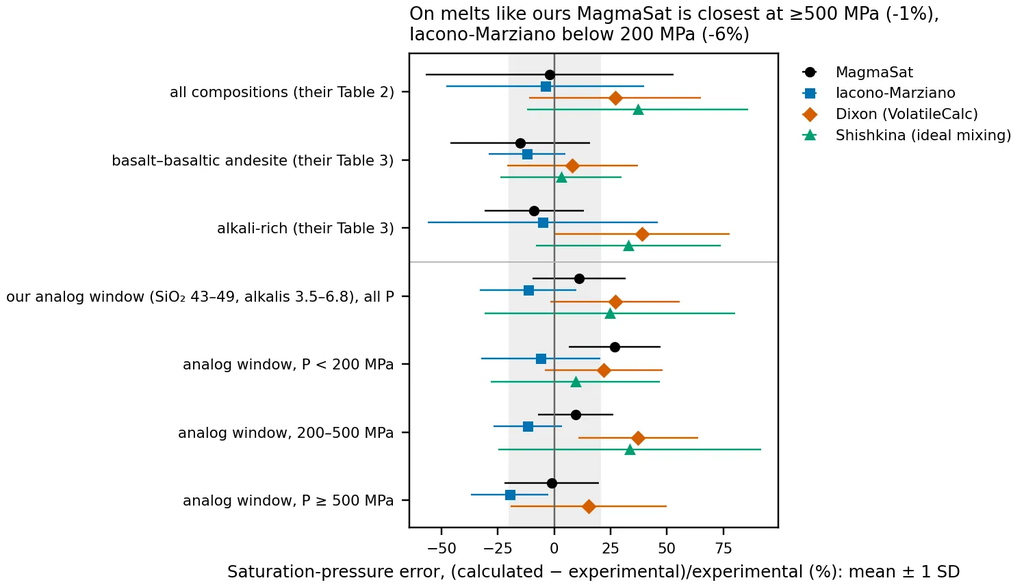

Figure 14.1: On experiments resembling the SR melts, MagmaSat has the smallest saturation-pressure bias at 200–620 MPa and Iacono-Marziano below 200 MPa; Dixon and Shishkina read 15–37 % high in most bins. Points: mean error; bars: ±1 SD of (calculated − experimental)/experimental saturation pressure, independent experiments only. Top three rows: Hughes & Saper (2026 preprint) Tables 2–3 (all compositions; basalt–basaltic andesite; alkali-rich). Lower four rows: this study’s recomputation for the analog window, by pressure bin; bins with fewer than 5 experiments are omitted. Grey band: ±20 %.

Table 14.1: MagmaSat is the most accurate model at depth and Iacono-Marziano below 200 MPa, where the xenolith rims form. Saturation-pressure accuracy / precision (%, with the number of experiments) of four solubility models on independent experiments resembling the SR melts.

| Analog window, pressure bin | MagmaSat | Iacono-Marziano | Dixon | Shishkina |
| --- | --- | --- | --- | --- |
| All pressures | +11 / 21 (62) | −12 / 21 (82) | +27 / 29 (81) | +25 / 56 (39) |
| P < 200 MPa | +27 / 20 (14) | **−6 / 26 (33)** | +22 / 26 (37) | +9 / 38 (10) |
| 200–500 MPa | **+10 / 17 (34)** | −12 / 15 (27) | +37 / 27 (32) | +34 / 58 (28) |
| ≥ 500 MPa (500–620) | **−1 / 21 (14)** | −20 / 17 (22) | +15 / 35 (12) | n = 1 |

A model that overpredicts saturation pressure for a given melt H2O underpredicts H2O solubility at a given pressure. For nearly pure H2O vapor, dissolved H2O goes roughly as the square root of pressure, so MagmaSat’s +27 % bias below 200 MPa corresponds to about −11 % in dissolved H2O. That is the direction and roughly the size of MagmaSat’s low late-stage H2O (0.67 against 0.92 wt% for Iacono-Marziano at 10 MPa on SR-1). Below 200 MPa the analog test therefore favors Iacono-Marziano, but on 14 MagmaSat and 33 Iacono-Marziano experiments only. The saturation-pressure uncertainty to carry is about ±20 % (1σ) for both on analogs, and above about 0.6 GPa no model has been tested on compositions like ours.

## 14.2 Choice of model and comparison

- **MagmaSat is primary.** It is the most accurate model at 200–620 MPa on analogs, Hughes & Saper’s best model for alkali-rich melts (−9 / 22 %), the only model with no pressure ceiling in its calibration (our starts saturate at 0.43–1.7 GPa), it uses Fe3+/FeT, and it reproduces the 2023 path exactly.
- **Iacono-Marziano is a sensitivity case, mainly below about 200 MPa.** It is the most accurate model there on analogs. The two are never blended, because a switch or weighted blend at about 200 MPa would put a kink into dH2O/dP that the diffusion boundary would fit as a change in degassing rate. Only the isothermal olivine rate exists on this path (0.086 MPa/s against 0.155 on MagmaSat, a factor of 0.55); no P–T path or pyroxene fits were run on it [CHECK: run the Iacono-Marziano path through the P–T and joint fits if it is to be called co-primary].
- **Dixon (VolatileCalc) is a sensitivity case.** It reads +27 % high on analogs, it is outside its pressure calibration for every start, and its CO2 solubility depends directly on the SiO2 passed to it.
- **MafiCH is a check.** It is not in VESIcal and was not evaluated by Hughes & Saper. It is calibrated at 1200–1250 °C only, with a composition-independent H2O law (Lesne et al. 2011). Its CO2 calibration includes a basanite and a leucitite, and the SR inclusions sit inside its cation-fraction ranges (Ol23 at the edge in Si). On the 3.55 wt% / 9079 ppm reference start it saturates at 736 MPa and holds 2.07 wt% H2O at 50 MPa and 0.84 at 10 MPa, between MagmaSat and Iacono-Marziano.
- **Shishkina is not recommended** (precision 56 % on analogs, calibrated to 500 MPa only).

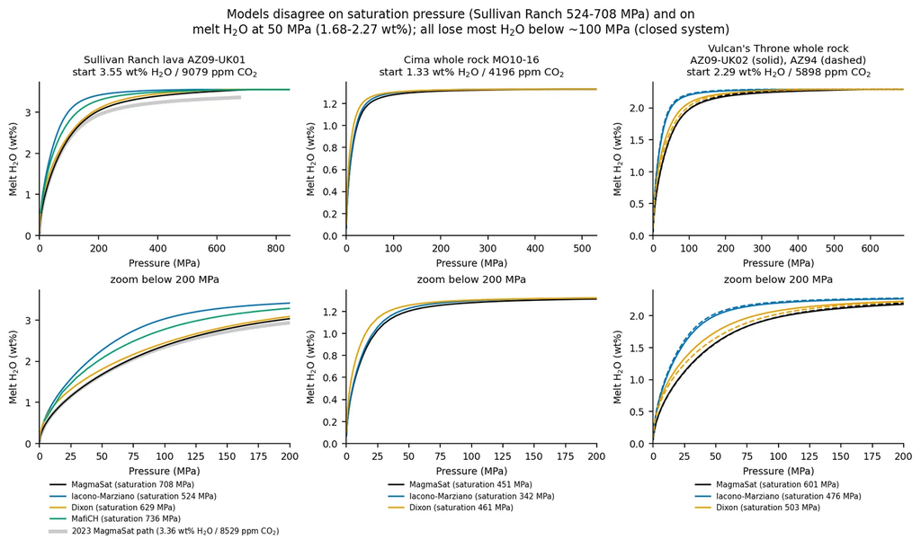

Figure 14.2: The models disagree on saturation pressure and on melt H2O at 50 MPa, but all lose most of the H2O below about 100 MPa. Closed-system paths at 1200 °C from one reference start per volcano. Left column: SR lava AZ09-UK01, 3.55 wt% H2O and 9079 ppm CO2 (saturation 524–736 MPa across the four models; grey: the 2023 MagmaSat path, 3.36 wt% and 8529 ppm). Middle: Cima whole rock MO10-16, 1.33 wt% and 4196 ppm. Right: Vulcan’s Throne whole rocks AZ09-UK02 (solid) and AZ94 (dashed), 2.29 wt% and 5898 ppm. Bottom row: below 200 MPa. MafiCH (SR only) stops where about 10 ppm CO2 remains (about 4 MPa, closed). Each volcano uses only its own composition.

**Open against closed.** Open-system degassing keeps the melt 0.18–0.35 wt% wetter at 50 MPa but only 0.05–0.07 wt% wetter at 10 MPa, so the fits use closed-system paths, which also make the temperature correction simple.

## 14.3 Starting melts and saturation pressures

All SR paths use the AZ09-UK01 lava as analyzed (Plank & Forsyth 2016 Table S5; Fe3+/FeT 0.167). It is in equilibrium with Fo 85.3 against a host median of Fo 85.6 and carries no accumulated olivine, cpx or mantle debris. The inclusion mean (corrected for post-entrapment crystallization and Fe loss) is the composition bracket; it lowers the MagmaSat saturation pressure by about 10 % and changes melt H2O at 10 MPa by 0.02 wt% or less. The primary start is the published MiMiC melt (3.549 wt% H2O, 8,529 ppm CO2). The other starts carry 14,100 ppm CO2, the depleted-mantle CO2/Nb (239) times the melt Nb (59 ppm), the smallest undegassed CO2 that still lies above every reconstructed SR inclusion (Section 13.7). Table 14.2 gives their saturation pressures and Table 14.3 the shape of each path. The starts span the H2O batches of Chapter 6: the published MiMiC melt (primary), SR-1 (wet end, CO2/Nb second scenario), SR-7 (wet end with Fe-loss correction), SR-6 (mixture of batches, the sensitivity case), SR-4 (dry batch) and Ol23 as trapped. The wet start was adopted because the intact interior WHT1 opx cores (about 411 ppm) with the opx-anchored partition coefficient are in equilibrium with 3.48 wt% melt H2O, within 2 % of the MiMiC start and 3 % of SR-1 (Section 12.7).

Table 14.2: MagmaSat saturation of the MiMiC start is 682 MPa and that of the SR-1 start 922 MPa (922.7), and the four starts that differ only in H2O saturate within 6 MPa of each other because saturation is CO2-controlled. Saturation pressures of the SR starting melts at 1200 °C (AZ09-UK01 composition unless the start says otherwise), from `data/original_volatiles_2026/starting_conditions_psat.csv`. The two Iacono-Marziano values for SR-1 come from two scripts: 685 MPa is the start-pressure calculation and 670 MPa the saturation of the path used in the fits; they differ by 2 %.

| Start | H2O (wt%) | CO2 (ppm) | MagmaSat saturation (MPa) | Iacono-Marziano saturation (MPa) |
| --- | --- | --- | --- | --- |
| **Published MiMiC (primary)** | 3.549 | 8,529 | **682** | not computed |
| SR-1, wet, CO2/Nb (second scenario) | 3.59 | 14,100 | 922 | 685 (670 on the fitted path) |
| SR-2, undegassed at the ocean-island CO2/Nb | 3.59 | 29,800 | 1438 | 990 |
| SR-3, as trapped (Ol23) | 3.55 | 9,080 | 708 | 535 |
| SR-4, dry batch | 2.20 | 14,100 | 927 | 735 |
| SR-5, inclusion-based melt | 3.59 | 14,100 | 833 | 625 |
| SR-6, mixture | 2.72 | 14,100 | 922 | 715 |
| SR-7, wet, Fe-loss corrected | 3.39 | 14,100 | 921 | 691 |

| Start | H2O at 50 MPa (wt%) | H2O at 10 MPa (wt%) | 10 % lost (MPa) | 50 % lost (MPa) | 90 % lost (MPa) | Olivine rate, isothermal / P–T path (MPa/s) |
| --- | --- | --- | --- | --- | --- | --- |
| **Published MiMiC (primary)** | 1.69 | 0.70 | 248 | 54.9 | 2.8 | 0.143 / 0.093 |
| SR-1, wet, CO2/Nb (second scenario) | 1.60 | 0.67 | 341 | 62.6 | 3.1 | 0.155 / 0.101 |
| SR-1, Iacono-Marziano | 2.17 | 0.92 | 152 | 34.7 | 1.8 | 0.086 / not run |
| SR-7, wet, Fe-loss corrected | 1.58 | 0.67 | 322 | 57.6 | 2.8 | not run |
| Ol23 as trapped | 1.68 | 0.70 | 257 | 55.6 | 2.8 | 0.144 / not run |
| SR-6, mixture | 1.48 | 0.65 | 260 | 42.1 | 1.9 | 0.174 / 0.113 |
| SR-4, dry batch | 1.36 | 0.63 | 210 | 31.1 | 1.3 | not run |

At 200 MPa the dry and wet batches differ by 0.9–1.2 wt%; at 10 MPa by 0.04 wt% (MagmaSat) to 0.08 wt% (Iacono-Marziano), less than the 0.2–0.3 wt% between the two models. The batch moves where degassing begins, which is the deep part of the boundary curve that the opx and cpx rims see.

## 14.4 Temperature dependence of the solubility

The decompression fits put the diffusivity on the falling P–T path (Section 12.4). The solubility side was tested separately: the SR-1 (CO2/Nb) and SR-6 starts were run at six isotherms from 1050 to 1300 °C, closed system, with MagmaSat, Iacono-Marziano and Dixon. The isotherms nearly coincide below about 300 MPa (Table 14.4).

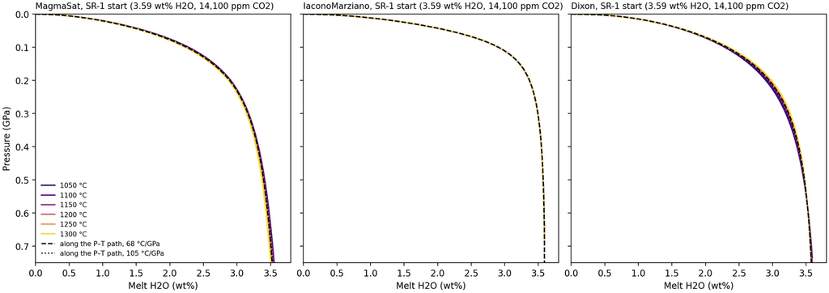

Figure 14.3: Temperature barely moves the shallow H2O loss: the SR-1 isotherms from 1050 to 1300 °C nearly coincide, and the paths that follow the P–T line lie on them. Melt H2O against pressure for the SR-1 start (3.59 wt% H2O, 14,100 ppm CO2) under MagmaSat (left), Iacono-Marziano (middle) and Dixon (right), closed system, at 1050–1300 °C (colors), with the T-consistent paths along straight P–T lines of 68 and 105 °C/GPa (black dashed and dotted). Temperature moves the CO2-controlled saturation pressure, not the shallow H2O loss.

Table 14.4: Saturation moves by up to 155 MPa across the isotherms, while the half-loss pressure and the shallow H2O move by a few percent at most (Figure 14.3). Temperature dependence of the SR-1 (CO2/Nb start) degassing path under three solubility models, 1050–1300 °C.

| SR-1 (CO2/Nb) start, closed | Saturation P, 1050 to 1300 °C (MPa) | P where half the H2O is lost (MPa) | H2O at 50 MPa (wt%) | H2O at 10 MPa (wt%) |
| --- | --- | --- | --- | --- |
| MagmaSat | 847 to 1002 | 60.3 to 63.8 | 1.63 to 1.58 | 0.683 to 0.669 |
| Iacono-Marziano | 648 to 683 | 34.7 (flat) | 2.16 to 2.17 | 0.918 to 0.919 |
| Dixon | 735 to 854 | 55.8 to 53.8 | 1.71 to 1.74 | 0.830 to 0.833 |

## 14.5 The equilibrium boundary at the measured rims

The boundary condition of the diffusion model is the mineral H2O in equilibrium with the melt, K times melt H2O. Comparing it with the measured xenolith rims shows where along the path each rim could have formed (Table 14.5; descriptive only: no diffusion is run).

Table 14.5: Olivine rims form in the last few MPa, opx rims in the last few tens of MPa, and cpx rims deeper. Where along the SR paths the equilibrium boundary falls to the measured xenolith exterior values (all-model ranges over the 286 SR paths at 1150–1200 °C; rows marked “wet SR-1” are for that start only; rows with the 2023 priors are the original comparison, the current-coefficient rows are recomputed). The WHT1 opx rim (158 ppm) is the median of the exterior rims; the outermost spot of the modeled grain is 96 ppm.

| Measured exterior value (ppm) | Partition coefficient | Melt H2O in equilibrium (wt%) | Pressure where the boundary reaches it, all models (MPa) | MagmaSat only (MPa) |
| --- | --- | --- | --- | --- |
| GCB1 olivine rim, 3.6 | 0.0009 (Towbin 2023) | 0.40 | 1.6–3.7 | 3.1–3.7 |
| GCB1 olivine core, 5.9 | 0.0009 | 0.65 | 4.0–9.5 | 7.9–9.5 |
| WHT1 opx rim, 158 | 0.009 (2023 prior) | 1.75 | 23–67 | 44–60 |
| WHT1 opx rim, 158 | 0.0118 (Novella × 0.93, current) | 1.34 | wet SR-1: 20 (Iacono-Marziano) | wet SR-1: 36 |
| GCB1 opx rim, 264 | 0.009 | 2.93 | 54–359 | 103–219 |
| WHT1 cpx rim, 261 | 0.012 (2023 prior) | 2.18 | 34–138 | 63–103 |
| WHT1 cpx rim, 261 | opx-anchored (opx × cpx/opx cores) | not tabulated | wet SR-1: 57 (Iacono-Marziano) | wet SR-1: 106 |

- **Olivine.** Every GCB1 olivine value sits far below equilibrium with undegassed melt (0.0009 × 3.55 wt% = 32 ppm). The rims (3.6–4.5 ppm) are reached only in the last 1.6–5.8 MPa and even the cores need melt with ≤ 0.75 wt% H2O. With the Peterson D_OH partitioning the rims are reached at 1.2–4.5 MPa, so the conclusion does not hinge on K.
- **Opx.** The WHT1 exterior rim is the strongest observed rim loss and forms only in the last few tens of MPa. It is robust to how the opx coefficient is set: 27–55 MPa (MagmaSat) or 15–31 MPa (Iacono-Marziano) across all strategies and batches.
- **Cpx.** The crossing depends on the coefficient strategy. With the experiment-based cpx coefficient the boundary starts below the measured rims, so the cpx would lose water from near saturation; opx-anchored or core-anchored, cpx rim loss starts at about 106–370 MPa (MagmaSat).
- **The deep interior cores** (WHT1 opx about 411 ppm, intact) are above the boundary at the start for the drier batches but match the wet start (the MiMiC and CO2/Nb starts both), which is the basis of the start choice.

The equivalent figure for the current coefficients is in Chapter 8. The “2023 prior” rows use the 2023 coefficients (opx 0.009, cpx 0.012) on mixed paths [CHECK: regenerate the 2023-prior rows and tabulate the cpx opx-anchored melt H2O with the opx-anchored K 117.7 on SR-1 if the table is kept in the paper].

## 14.6 CO2 and published rates

A side question is whether CO2 content orders the published rates, since most cinder cones carry much less CO2 than SR (Table 14.6).

Table 14.6: CO2 content does not order the published rates: the CO2-rich Etna 3930 BP is fast like SR, other CO2-rich eruptions are slow, and the CO2-poor Fuego is fast. Rates from H diffusion are final-ascent rates; whole-path averages (Fe–Mg, fluid inclusions) are not directly comparable. Velocities converted at 2800 kg/m³. Sources in `data/literature_ascent_rates/high_co2.csv`.

| Eruption | Maximum melt-inclusion CO2 (ppm) | Rate (MPa/s) | Method | Notes |
| --- | --- | --- | --- | --- |
| Sullivan Ranch (this study) | 9,079 (Ol23, bubble-corrected); primary start 8,529 (published MiMiC); second scenario 14,100 | 0.093 (0.055–0.154) | H in olivine (P–T path) | cinder cone with mantle xenoliths |
| Etna 3930 BP Fall Stratified (Barth 2024) | 9,600 (rehomogenized) | 0.47 (0.16–1.28) | H in olivine (Fo 90–91) | subplinian picrite |
| Fuego 1974 | 300–450 measured (a few above 500) | 0.38–0.45 | olivine H, embayments | subplinian arc basalt |
| Seguam 1977 | ~900 (model input) | 0.04–0.36 | olivine H, embayments | violent Strombolian |
| Kilauea Iki 1959 | ≤ 590 (rehomogenized; secondary) | 0.05 | olivine H, embayments | Hawaiian fountain |
| Cerro Negro 1992 / 1995 | 600–1,260 (model input / abstract) | 0.001–0.03 | olivine H, melt inclusions | arc cinder cone |
| Fogo (DeVitre 2023) | ~20,000 (secondary; bubble status unknown) | 0.0005–0.05 | melt inclusions | ocean-island basanite |
| Ross Island, Hut Point (Rasmussen 2017) | 2,000–18,000 (bubble-corrected) | ≥ 1 × 10⁻⁵ (authors’ minimum) | melt-inclusion H2O loss | basanite cones |
| La Palma Tajogaite 2021 (Zanon 2024) | ~14,000 (abstract) | ≈ 3 × 10⁻⁴ to 3 × 10⁻³ | fluid-inclusion barometry with seismicity | 85-day Strombolian/effusive eruption |
| Paricutin 1943 (Albert 2020) | not given | ≈ 0.002–0.03 | olivine Fe–Mg, Ni, P | whole-path average |

## 14.7 Methods and code

**Code and outputs.** `scripts/degassing_paths/` writes `data/degassing_paths_2026/` (`cases.csv`, `paths.parquet`, `metrics.csv`, `xenolith_boundary.csv`, `figures/`). The isotherms and the T-consistent refit are `scripts/decompression/solubility_t.py`. The starting-melt saturation pressures come from `scripts/original_volatiles/start_psat.py` and the MagmaSat runs from `queue_magmasat.py`, `run_magmasat.sh` and `scripts/original_volatiles/collect_magmasat.py` (control: 6814.82 bar reproduced). Tests: `tests/test_degassing_paths.py`.

**Compositions.** Anhydrous Plank & Forsyth (2016) analyses with FeO and Fe2O3 split at each vent’s Fe3+/FeT, normalized to 100 − H2O − CO2 (VESIcal “fixedvolatiles”). The original-volatiles starts use the oxides, Fe3+/FeT (0.167) and temperature in `data/original_volatiles_2026/starting_conditions.csv`. No composition is used for another volcano.

**Grid.** SR: three compositions (lava AZ09-UK01, scoria AZ09-GCB, inclusion mean) × H2O 2.6, 3.1, 3.55, 4.0, 4.5 wt% × CO2 3141, 5755, 9079 and 14,100 ppm at 1200 °C, plus three runs at 1166 °C and the original-volatiles starts. Cima and Vulcan’s Throne were run on their own compositions only (not used for rates). Pressure steps from the saturation pressure: 10 MPa above 200 MPa, 5 MPa to 20 MPa, 1 MPa to 1 MPa, then 0.5 and 0.1 MPa.

**Iacono-Marziano and Dixon** (`run_fast.py`). VESIcal 1.2.12 on the host. Closed system: `calculate_degassing_path(fractionate_vapor=0)`. Open system: one step at a time with CO2 below 1e-6 wt% set to zero, because VESIcal-Dixon can stall in its Redlich–Kwong volume loop once dissolved CO2 reaches about zero (a change of at most 2e-6 wt% H2O). Each path has a 300 s limit, and paths with missing steps are rejected (none occurred).

**MagmaSat** (`queue_magmasat.py`, `magmasat_path.py`, `run_magmasat.sh`). The ENKI ThermoEngine container (VESIcal 1.2.10), one subprocess per path with a 2 h limit and a per-path cache. Check: run on the exact 2023 pressure list (3.36 wt% H2O, 8528.8 ppm CO2, Fe3+/FeT 0.17, 1200 °C), MagmaSat reproduces the 2023 path file at all 202 rows to 1.1e-4 wt% H2O.

**MafiCH** (`run_mafich.py`). The authors’ supplement script, run through a driver copy, with temperature fixed at 1200 °C, 25 ppm CO2 steps and total Fe as FeO. Its paths stop at about 10 ppm CO2 (4–5 MPa closed, 80 MPa open), so they do not reach the final stage.

**Dixon normalization.** VESIcal’s Dixon model reads SiO2 as given. Scaling the oxides to 100 − H2O − CO2 lowers SiO2 by 1.4–3.0 wt%, which Dixon reads as a more alkaline melt, so the Dixon paths here (hydrous normalization) understate Dixon’s saturation pressures by 11–25 %. Dixon is a sensitivity case only, so this changes no result.

**Isotherms and the T-consistent path.** In a closed system melt H2O at (P, T) depends only on P, T and the bulk volatiles, so the path along $T(P) = 1330\ \mathrm{°C} - s\,(2.26\ \mathrm{GPa} - P)$ is the isotherms interpolated linearly in T at T(P) for each P. All 432 fast paths and all 10 new MagmaSat isotherms ran without failures. Control: the 1200 °C-path control reproduces the path fits (olivine 0.089 at 90.4 °C/GPa against 0.090 at 90 °C/GPa).

**Xenolith boundary.** Unflagged xenolith rows of `data/compiled/csv/T1_SIMS_NAMS.csv`, medians by xenolith, mineral, position and core or rim. For each path, the pressure at which K × melt H2O falls to the measured value is interpolated; the current-coefficient crossings are from `scripts/model_choices/anchoring.py`.

# 15 Data quality

This appendix documents how far the SIMS dataset can be trusted: the calibration lines, what uncertainty is reported and why, the detection limits, the one re-reduced analysis, the electron-microprobe coverage, the disagreements between the deposited text and the data, the checks on the compiled workbook, and the olivine Fo populations. The measurements and their use are in Chapter 4 and Chapter 5.

## 15.1 Calibration

The calibration question is whether the olivine data and the olivine/melt K that converts them to melt H2O are on the same scale. Scaling the olivine data by a factor s has the same effect on a fitted rate as using K/s, so a mismatch between them would bias the rate directly.

Each analysis is reduced as x = 16O1H/30Si × SiO2 (wt%) of the analysis, with no further division, and H2O (ppm) = slope × x + intercept. Each line is an orthogonal-distance regression of the session’s standards plus its blank rows, with the x error from the ratio scatter and the y error the accepted standard error, followed by a 5000-draw bootstrap.

Table 15.1: Six calibration lines carry every analysis; the detection limit is below 1 ppm only for the 2018 opx/olivine line. Calibration lines (30Si normalization) and H2O detection limits per session. Glass, olivine and 18O-normalized lines exist but are not applied to the SIMS dataset.

| Session and line | Applied to (analyses) | Slope (ppm per unit x) | Intercept (ppm) | R² | L_C / L_D / LoQ (ppm) |
| --- | --- | --- | --- | --- | --- |
| 6f 2013, opx | opx (2) and olivine (4) | 57 ± 2 | −6 ± 1 | 0.966 | 4.88 / 9.78 / 15.0 |
| 6f 2013, cpx | cpx (58) | 78 ± 6 | −7 ± 3 | 0.868 | 6.70 / 13.3 / 20.4 |
| 6f 2018, opx | opx (29) and olivine (54) | 53 ± 1 | 0 | 0.994 | 0.492 / 0.987 / 1.44 |
| 6f 2018, cpx | cpx (20) | 74 ± 2 | 0 | 0.962 | 0.683 / 1.38 / 2.54 |
| NanoSIMS 2020, opx | opx (38, including T1-216) | 126 ± 7 | −18 ± 5 | 0.921 | 7.62 / 17.1 / 21.8 |
| NanoSIMS 2020, cpx | cpx (79) | 128 ± 11 | −18 ± 3 | 0.945 | 7.53 / 17.4 / 37.3 |

The per-session standards (glass, olivine, opx and cpx reference materials, plus Suprasil and synthetic forsterite as blanks) are listed in the calibration table of the supplement; the text of the deposited chapter lists 2013-only standards among the 2018 ones [CHECK: per-session standard lists, supplement Table S6 block D]. The NanoSIMS glass line is printed as 143 on the calibration figure against 147.6 recomputed (an old label); the glass line is not used for minerals, so no action was taken.

## 15.2 Total 1σ against the deposited combined uncertainty

The deposited “combined uncertainty” is $\sqrt{((P_{95} - \mathrm{best})^2 + (\mathrm{best} - P_5)^2)/16 + s_{SIMS}^2}$. It reproduces every deposited value but it understates the calibration term: it carries about 0.58 of the calibration 1σ. The SIMS dataset therefore reports the total 1σ

$$\sigma_{tot} = \sqrt{\sigma_{cal}^2 + \sigma_{count}^2 + \sigma_0^2},
\tag{15.1}$$

where $\sigma_{cal}$ is the larger side of the 5–95 % calibration interval divided by 1.645, $\sigma_{count}$ the counting standard error and $\sigma_0$ the Suprasil blank scatter beyond counting statistics, times the slope. Examples: T1-181 (2.20 ppm) goes from 0.095 to 0.30 ppm, and T1-056 (206 ppm) from 10.5 to 18.8 ppm. The Ol-2 spots carry 0.31–0.43 ppm, and 2013 analyses, which had no uncertainty, now have one. The compiled data also keep the deposited column, renamed “as deposited”. The ascent fits do not read these uncertainties: each fit uses a fixed σ per profile (Section 12.3), so the change affects only the reported values. The 2023 edition of the supplement keeps the deposited values.

The calibration term is shared by all points of a session and line, so it acts like a scale (K) error rather than scatter; moving it into the K prior changes nothing visible in the rates (Section 12.3).

## 15.3 Detection limits

Three limits (Table 15.2) are quoted per session and line, computed from the Suprasil blank scatter in the same unit as the samples (x above), with blanks entering at their own SiO2. Suprasil is the near-blank (nominally 1 ± 1 ppm, likely 1–2 ppm); the NanoSIMS synthetic forsterite blank is probably SynFo70, which carries real H, and is not used.

Table 15.2: The detection limit is the lowest H2O that is distinguished from the blank 95 % of the time; the quantification limit is the lowest at which the total 1σ is a fifth of the value. Definitions used for the limits of the SIMS H2O data.

| Quantity | Definition |
| --- | --- |
| Background | Minus the intercept of the session line: the H2O equivalent of the x-intercept. The line removes it; it is a level, not a limit |
| L_C, decision limit | Hubaux & Vos (1970) with a prediction band: the 95th percentile of bootstrap x-intercepts plus one spot’s Suprasil scatter, read on the best line (one-sided α = 0.05) |
| L_D, detection limit | The lowest true H2O whose 5th-percentile reading reaches the L_C threshold (α = β = 0.05); equals Currie’s 3.29σ0 for a normal spread |
| LoQ, quantification limit | The lowest H2O with total 1σ / H2O ≤ 20 % |

Each analysis is tagged against L_D and LoQ and every measured value is kept (no substitution). The limits are in Table 15.1. Of the 284 analyses, six are below L_D: T1-039 and T1-040 (NanoSIMS cpx, CA18-05) and T1-158 to T1-161 (2013 Cima olivine); T1-135 and T1-136 (NanoSIMS pit cpx) lie between L_D and LoQ; 276 are quantified, including every 2018 olivine. For the 2018 olivine, L_D is 0.99 ppm and LoQ 1.44 ppm. Because the Cima olivine values are below L_D, the SR-to-Cima olivine ratio is not quoted.

The other volatiles are less certain. Blanks from the 6f sessions show that F in pyroxene and P are real signals, while S, Cl and CO2 in these minerals sit at or near the blank level, so their tabulated values are counting statistics only and carry no calibration or blank term. The supplement keeps H2O, F and P as the main volatiles and gives S, Cl and CO2 in one note.

## 15.4 T1-216 on the opx line

T1-216 (analysis CA18-05x-OPX_Core) is an opx analysis that was reduced at SiO2 55 and, as deposited, not on the opx line. The 2026 edition and the compiled data use its opx-line value, 129.70 ppm (90 % interval 119.93–139.09), from the opx columns of the 2023 processing sheet, against 131.26 ppm as deposited. It is the maximum of the Cima xenolith opx (35–130 ppm in the 2026 edition). The 2023 edition and the figure data keep 131.26.

## 15.5 Electron microprobe coverage

EMPA supplies the SiO2 used in the SIMS reduction, the Mg# and Cr of the pyroxenes, and the olivine Fo profiles. Coverage is uneven.

## 15.6 Disagreements between the deposited text and the data

A sweep of 65 quantitative claims in the deposited Chapter 3 against the final data found 33 consistent, 15 inconsistent and 17 that need model output to check. Table 15.3 groups the inconsistencies and the open questions about the SIMS dataset.

Table 15.3: Most disagreements are deposited-text values that predate the 2023 recalibration; the data themselves trace cleanly to the raw instrument files. Summary of the text-versus-data sweep and the issue list of the SIMS dataset.

[output not shown]

Inclusion-side data issues (the supplement table S9 row mismatch, GC2_ol6, GC2_ol4, the input changes between 2023 and 2026) are in Chapter 13.

## 15.7 Compiled-workbook checks

`scripts/build_compiled_workbook.py` builds the compiled workbook from the final chapter tables and the raw session files, `scripts/recalc.py` recalculates it and `scripts/verify_compiled.py` checks it. The SIMS dataset is copied verbatim from the 2023 chapter tables; cleaned columns (phase, locality, position, core/rim, flag, grain ID) are added beside the original ones, and the 2018 GCB1 EMPA is a separate table. The last full check gave:

- 284 rows with 0 cell differences from the source table;
- every row linked to a raw instrument row with the identical H2O value (64 rows from the 2013 6f session, 103 from 2018, 117 from NanoSIMS 2020); all 117 NanoSIMS rows also linked to a ratio row with no mismatch;
- 0 lookup mismatches in the data behind the regenerated chapter figures;
- 82 GCB1 EMPA points with 0 mismatches against the raw export, and 14 of 15 grains linked to SIMS grains.

[CHECK: this check predates the total 1σ columns, the detection-limit tags and the T1-216 re-reduction in the compiled data; rerun `verify_compiled.py` and report the new counts.]

## 15.8 Olivine Fo populations

The olivine Fo data separate the crystals by origin (Table 15.4) (`scripts/olivine_fo_populations.py`, `data/olivine_fo_populations/grains.csv`).

Table 15.4: The pit rims converge on lava equilibrium whatever the core, while every roadside grain ends below it. Core and rim Fo per population, from the EMPA master sheet with bad points removed.

| Grains | Profiles | Core Fo | Rim Fo |
| --- | --- | --- | --- |
| WHT06 phenocrysts (pit) | 11 | 83.0–88.2 (ol44 reverse-zoned, 75.9) | 83.3–85.8 (median 84.5) |
| WHT06 xenocrysts ol43, ol48 (pit) | 2 | 88.2–89.5 | 84.0–84.9 |
| GCB1 xenocrysts ol6, ol23 (roadside) | 3 | 90.5–90.6 | 81.5–83.0 |
| GCB1 Ol-2, the H2O profile grain (roadside) | 1 | 88.1 (plateau 88.0–88.3) | 80.7 at 5 µm |
| WHT1 exterior grains (roadside) | 3 | 89.5–89.7 | 80.7–83.9 |
| Melt-pocket overgrowths | 12 | 89.6–91.6 | 90.5–93.4 (rims rise; grown from the vein melt) |

## 15.9 Measurement methods

**EMPA.** Major elements were measured on the Cameca SX100 at the American Museum of Natural History in 2018 (GCB1) and on the Cameca Tactis in several sessions from summer 2020 to February 2022 (protocols as in Chapter 2). The GCB1 per-grain data were recovered from the July 2018 workbook and checked point by point against the raw instrument export. Phases were assigned by composition (cpx CaO ≥ 15 wt%; opx CaO < 3 and MgO 28–37 wt%); Mg# is molar with all Fe as FeO.

# 16 Decisions, crosswalk and reproducibility

This appendix is the record behind the report: the decisions taken and their evidence, the 41 claims of the deposited Chapter 3 against their 2026 status, the scripts that regenerate every number, and the dated working logs the chapters were written from. Dates and working-document names appear only here.

## 16.1 Decisions

Table 16.1 lists the choices behind the central rate and the report, sorted by date. Letter-number codes (A1, B4, D5) are the question numbers of the supplement question list; “plan answer” refers to the answers recorded for the summary workbook; “review section 9” is the set of decisions on the rebuilt report.

Table 16.1: Choices behind the central rate and the report, each with its evidence.

[output not shown]

The newest decisions change the framing more than the numbers. The headline is now the joint fit of olivine, opx and cpx on the P–T path (0.100 MPa/s, 0.050–0.200 over 46–120 °C/GPa, MiMiC start) rather than the olivine-only 0.093 MPa/s; continuous ascent is the best history at the central and steepest slopes (a 5-minute stall fits better only at 46 °C/GPa); the published MiMiC melt replaced the CO2/Nb start as the primary start on 2026-10-30; and the report leads with what changed since the 2023 chapter.

## 16.2 Crosswalk to the deposited Chapter 3

The deposited Chapter 3 (Testing the Fidelity of Peridotite Xenoliths as Records of Water in the Lithospheric Mantle) is the 2023 baseline. Table 16.2 lists its substantive claims, results and interpretations in the order of the chapter and gives each a status against the 2026 analyses:

- **Confirmed:** the 2026 work supports the point.
- **Revised:** the point stands in outline but the number or the method changed.
- **Superseded:** the 2026 work replaces it.
- **Extended:** the point stands and was tested further.
- **Not revisited:** the 2026 sources do not address it.

Statuses rest on the working logs in Section 16.4. The text-versus-data conflicts that predate this work (the olivine sentences read about 1.3 times the SIMS dataset values) are in Section 15.6. No value of the SIMS dataset was changed.

Table 16.2: Chapter 3 claims against the 2026 analyses. Of 41 points, 20 are revised, 7 confirmed, 7 extended, 2 superseded and 5 not revisited; the largest changes are the degassing onset, the starting melt and the ascent rate.

[output not shown]

**New in 2026 (not in Chapter 3).**

- **Temperature along the magma P–T path.** A straight path from 1330 ± 15 °C at 2.26 ± 0.10 GPa; the families (Towbin and Plank 2026, a fit through 12 SR inclusions, and the SR-wide envelope) give 1176 to 1107 °C at the surface and slow every rate by a common factor (Chapter 3, Chapter 8).
- **Localities and magma pulses.** Pit and roadside samples are probably different pulses; roadside inclusions are hotter at the same pressure (1148–1198 against 1139–1166 °C).
- **Fe–Mg residence times and Fo populations.** FORSTER times for Ol-2 (18 d) and the xenocrysts, rims in equilibrium with the lava, and the lower-MgO final melt that no measured inclusion samples (Section 12.10, Section 15.8).
- **MiMiC versions.** Original (reproduced exactly), 2026 baseline and modified (Duan & Zhang bubble CO2) runs; the version moves the ascent rates by 2 % or less and the P–T slope by 0.2 °C/GPa (Chapter 13).
- **Solubility temperature.** Evaluating MagmaSat along isotherms of 1050–1300 °C changes the rate by 3 % or less (Section 14.4).
- **Literature model temperatures.** Each published rate placed on its own model temperature, so the SR rate is compared like for like (Chapter 8).
- **Interior-core anchoring of the start.** Intact interior WHT1 opx cores fix the starting melt H2O at 3.48 wt%, within 2 % of the MiMiC start (3.549) and 3 % of SR-1; two grains flatten near 300–320 ppm, which is treated as a K or starting-H2O uncertainty (Chapter 9).
- **Joint fit with free pyroxene D, on the P–T path.** One continuous ascent fits olivine, opx and cpx at 0.100 MPa/s; no stall is needed at the central slope (Chapter 8, Section 12.9).
- **Uncertainty and detection limits.** Total 1σ, L_C, L_D and LoQ for every analysis; fixed fit σ kept (Chapter 15).
- **Barth edge effects on olivine.** Two-population models fit Ol-2 only if exchange is fast, and widening the final-pressure prior moves the isothermal rate only within 0.155–0.164 MPa/s on the CO2/Nb start (Section 12.8).
- **Alternative olivine laws and solubility models.** Peterson D_OH and power law, Barth laws, and Iacono-Marziano against MagmaSat (Chapter 12, Chapter 14).
- **Grain-boundary fits and mechanisms.** Coupled and nested grain-boundary fits on the joint-fit scenarios, buffering of the exterior grains, and the melt, grain-boundary and hybrid pathways (Chapter 8).
- **Cpx partitioning misfit and CO2/Nb.** The cpx cores hold 1.2–2.6 times the water the recalibrated experiments predict; the start CO2 is a CO2/Nb estimate (Chapter 9, Section 13.7).

## 16.3 Reproducibility: scripts, outputs, commands

One table per topic lists the script, what it does and where its output goes. All paths are relative to the repository root (`Ch3_Xenolith_SIMS_Clean`, private). Each script’s module docstring gives its command; the patterns are below. Scripts without a documented purpose, shared helpers and FTIR scripts (`scripts/ftir/`, out of scope) are not listed. The dated working documents that describe these runs are in Section 16.4.

The external code the scripts call is in Table 16.3.

**Environments.**

- **NAM environment (all decompression fits).** The posterior code lives in the H2O_Diffusion_NAM repository (public). Fit scripts in `scripts/decompression/` run as `PYTHONPATH=~/Projects/H2O_Diffusion_NAM uv run --project ~/Projects/H2O_Diffusion_NAM --with pyarrow --with scipy python scripts/decompression/<script>.py`. Plot-only scripts need only `uv run --with pandas --with matplotlib`.
- **MagmaSat degassing paths (container).** MagmaSat runs inside the ENKI ThermoEngine container (VESIcal 1.2.10). `scripts/degassing_paths/run_magmasat.sh [N]` starts N parallel containers (through colima and docker), skips cached paths, and writes JSON files to `data/degassing_paths_2026/magmasat/cache/`. The fast models (Iacono-Marziano, Dixon) run on the host with `--with VESIcal==1.2.12`.
- **MiMiC.** The vendored code in `scripts/mimic/vendor/` (Rasmussen et al. 2020) is unmodified (`PROVENANCE.md` records the upstream commit). `scripts/mimic/run_mimic.py` runs it with `uv run --no-project --python 3.13 --with numpy==2.2.6 --with scipy==1.16.3`.
- **Fe–Mg diffusion.** FORSTER, from the Olivine_Diffusion_FeMg repository: `uv run --project ~/Projects/Olivine_Diffusion_FeMg forster fit ...`.
- **Everything else** uses `uv run --with <packages>` or the project `.venv` as in each script’s docstring.

Table 16.3: External code that the scripts call. Unpublished Sullivan Ranch results stay in this private repository and are not copied to the public NAM repository.

[output not shown]

**Rebuild order for the numbers in the report.**

1. Data: `.venv/bin/python scripts/build_compiled_workbook.py`, then `scripts/recalc.py` (needs LibreOffice), `scripts/verify_compiled.py` and `scripts/export_csv.py`.
2. Supplement and summary workbook: `.venv/bin/python scripts/build_supplement.py 2026`, then `scripts/supplement/summary_workbook.py` (15 sheets, one CSV per sheet in `data/supplement/summary_csv/`) and `scripts/supplement/check_summary.py` (exits 1 on any failure).
3. Starting melts and degassing paths: `scripts/original_volatiles/`, `scripts/degassing_paths/` and `scripts/mimic/`.
4. Fits: `fit_wet_primary.py`, `fit_pt_path.py`, `joint_d_fit.py` (isothermal, then `--slope 46`, `82.8` and `120` on the P–T path), then the exchange scripts with `--path wet --rate 0.17783` (isothermal) and `--path wet_pt --slope S --rate R` for each joint-fit scenario.
5. The book: `cd report && python3 tools/check_links.py`, then `quarto render` and `python3 tools/build_pdf.py`.

### 16.3.1 Samples and data

The compiled data workbook, the supplement and the summary workbook are built by the scripts in Table 16.4. The SIMS dataset is never edited by hand; every change goes through these scripts (Chapter 15).

Table 16.4: Scripts that build, check and export the compiled data, the supplement and the summary workbook. The compiled workbook is checked by `scripts/verify_compiled.py`, and `scripts/annotate_table1.py` lists open issues of the SIMS dataset without changing it.

[output not shown]

### 16.3.2 Melt inclusions and MiMiC

Table 16.5 lists the MiMiC runners, the solubility-model checks and the inclusion figures behind Chapter 13.

Table 16.5: Scripts for melt-inclusion volatiles, MiMiC runs and solubility-model checks.

[output not shown]

### 16.3.3 Degassing paths

Table 16.6 lists the scripts behind Chapter 14. The MagmaSat paths run in a container; the other models run on the host.

Table 16.6: Scripts that compute and summarize the degassing paths and the starting-melt saturation pressures.

| Script (repo path) | What it does | Outputs |
| --- | --- | --- |
| `scripts/degassing_paths/queue_magmasat.py` | Write data/degassing_paths_2026/magmasat/queue.csv: the MagmaSat paths to run in the container (run_magmasat.sh). | data/degassing_paths_2026/magmasat/queue.csv |
| `scripts/degassing_paths/run_magmasat.sh` | Run the MagmaSat path queue in N parallel ThermoEngine containers (cached paths are skipped). | data/degassing_paths_2026/magmasat/cache/{key}.json (one per path); logs in magmasat/logs/ |
| `scripts/degassing_paths/magmasat_path.py` | MagmaSat degassing paths; runs INSIDE the ENKI ThermoEngine container (VESIcal 1.2.10). | the per-path JSON cache above (runs inside the container) |
| `scripts/degassing_paths/run_fast.py` | Fast-model degassing paths (VESIcal 1.2.12 on the host): Iacono-Marziano and Dixon, closed and open system. | data/degassing_paths_2026/paths_fast.parquet; cases_fast.csv |
| `scripts/degassing_paths/run_mafich.py` | MafiCH (Allison et al. 2022) degassing paths for 3 Sullivan Ranch cases (AZ09-UK01 lava). | data/degassing_paths_2026/mafich/{case}.csv; paths_mafich.parquet; cases_mafich.csv |
| `scripts/degassing_paths/build_paths.py` | Collect all degassing paths into one table and one case index. | data/degassing_paths_2026/cases.csv; paths.parquet; paths.csv.gz |
| `scripts/degassing_paths/metrics.py` | Per-path metrics and the xenolith boundary comparison. | data/degassing_paths_2026/metrics.csv; xenolith_measured.csv; xenolith_boundary.csv |
| `scripts/degassing_paths/plots.py` | Degassing-path figures (PNG, 170 dpi) in data/degassing_paths_2026/figures/. | data/degassing_paths_2026/figures/*.png |
| `scripts/model_choices/olivine_d.py` | Olivine/melt H2O partitioning options and their effect on the GCB1 olivine-rim comparison. | data/model_choices_2026/ (olivine partitioning tables) |
| `scripts/model_choices/px_d.py` | Pyroxene/melt D alternatives and the pressure at which D x melt H2O falls to measured Sullivan Ranch rims/cores. | data/model_choices_2026/pyroxene_crossings.csv |
| `scripts/model_choices/anchoring.py` | Pyroxene/melt D for re-equilibrated xenolith crystals: three ways to set D, and where each puts the melt-boundary (D x melt H2O along the degassing path) relative to the measured Sullivan Ranch pyroxe… | data/model_choices_2026/anchoring_D.csv; anchoring_boundary.csv; figures/fig9_anchoring.png |
| `scripts/original_volatiles/start_psat.py` | Saturation pressure and depth of every starting condition with four solubility models. | data/original_volatiles_2026/starting_conditions_psat.csv |
| `scripts/original_volatiles/collect_magmasat.py` | Collect the cached MagmaSat results and check the control point (fails loudly if it differs). | data/original_volatiles_2026/magmasat/magmasat_results.csv |

### 16.3.4 P–T path and crystal residence

Table 16.7 lists the scripts behind the P–T path and the Fe–Mg residence times.

Table 16.7: Scripts for the P–T path, olivine Fo populations and Fe–Mg residence times.

[output not shown]

### 16.3.5 Diffusion fits and ascent rates

Table 16.8 lists the fits, sensitivity runs, figures and model-choice scripts behind Chapter 12 and Chapter 8. All posterior fits run in the NAM environment.

Table 16.8: Scripts for diffusion fits, sensitivity runs and model choices (partitioning). The stall and scenario scripts produced the superseded 2023-diffusivity results summarized in Section 12.9.

[output not shown]

### 16.3.6 Xenolith exchange

Table 16.9 lists the grain-boundary and transport scripts behind the exchange model of Chapter 8.

Table 16.9: Scripts for the xenolith grain-boundary fits and transport estimates.

[output not shown]

### 16.3.7 Literature

Table 16.10 lists the scripts that compile and plot the published ascent rates.

Table 16.10: Scripts that compile and plot published ascent rates.

| Script (repo path) | What it does | Outputs |
| --- | --- | --- |
| `scripts/literature_ascent/compile.py` | Merge the literature ascent-rate transcriptions and put every rate on one scale (decompression rate, MPa/s). | data/literature_ascent_rates/compiled.csv |
| `scripts/literature_ascent/plot_set.py` | Curated comparison set: one entry per eruption x method x study, built from compiled.csv by explicit selections. | data/literature_ascent_rates/plot_set.csv |
| `scripts/literature_ascent/plot_comparison.py` | Forest plot: Sullivan Ranch decompression rates vs published rates. | results/literature_ascent/fig_ascent_rate_comparison.png |
| `scripts/literature_ascent/plot_best_comparison.py` | Forest plot: best like-for-like comparison of the Sullivan Ranch decompression rate with published rates from H2O diffusion that use a degassing boundary. | results/literature_ascent/fig_best_comparison.png |

### 16.3.8 Building this report

The book is a Quarto project in `report/` (Table 16.11). Figures are cited as `../assets/<repo-relative path>`; `report/tools/sync_assets.py` copies each cited PNG into `report/assets/` before rendering, so the rendered book is self-contained.

Table 16.11: The report build tools, run from `report/`. Quarto book projects do not support the Typst format directly, so the PDF script builds a single-document project in `report/_pdf/`.

| Tool | What it does | Command |
| --- | --- | --- |
| `report/tools/sync_assets.py` | Copy every image the book cites from outside the project into `report/assets/` | `python3 tools/sync_assets.py [--project DIR] [--root DIR] [--check]` |
| `report/tools/check_links.py` | Report missing images, broken relative links, unresolved or duplicate ids, and uncited figures and tables | `python3 tools/check_links.py [--project DIR] [--root DIR] [files...]` |
| `report/tools/build_pdf.py` | Concatenate the chapters in `_quarto.yml` order and render one PDF through Typst | `python3 tools/build_pdf.py [--project DIR] [--name report] [--no-render]` |

## 16.4 Working logs

The chapters of this report are the synthesis. The documents in Table 16.12 are the dated working logs they were written from: each records what was asked, what was run and what came out on a given day, and some were superseded by later ones. Where a log and a chapter disagree, the chapter and the later-dated log win. The logs are in the private repository and are linked by relative path. FTIR documents are left out (out of scope for this report). The scripts behind the logs are in Section 16.3.

Table 16.12: Dated working logs, supplement documents and fact sheets, one row per document (docs/, docs/agents/, docs/literature/, docs/open_questions/, docs/supplement/, data/*/SUMMARY.md for the two MiMiC output folders).

[output not shown]

# 17 Chapter 3 figures, deposited and recompiled

## 17.1 Figure 3: olivine cores and rims, and the olivine profiles

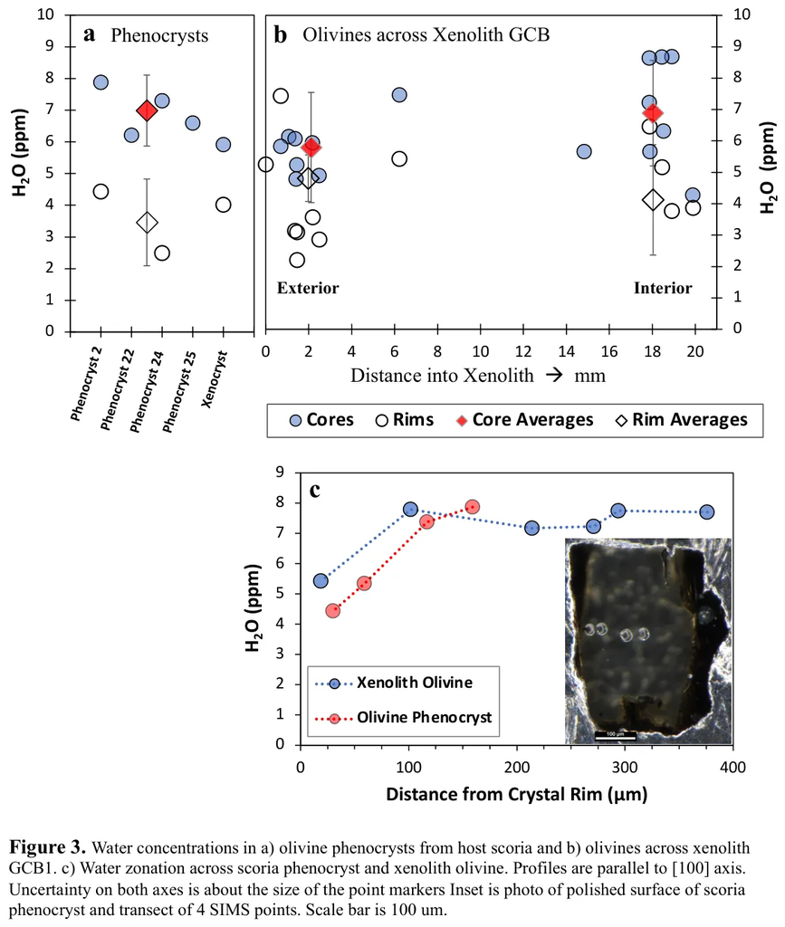

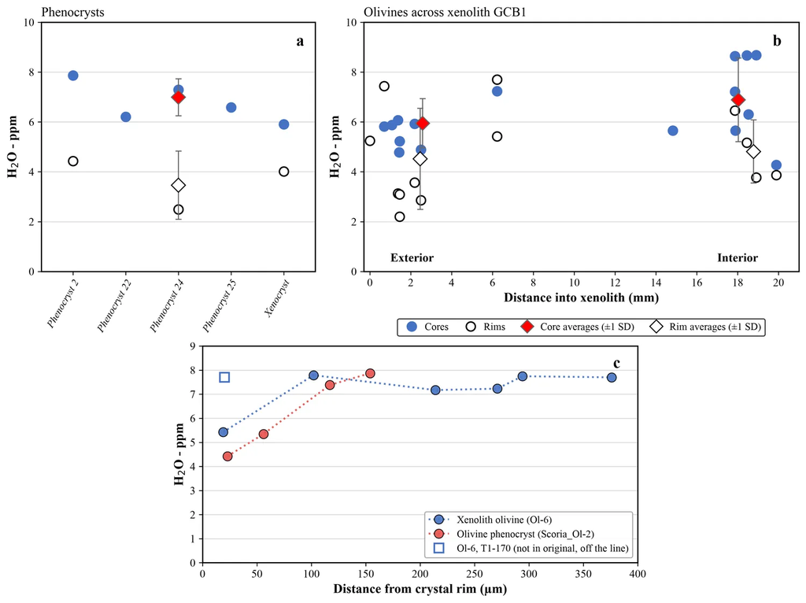

**Figure 3 (Chapter 3).** Left (a): as deposited (2023). Right (b): recompiled from the SIMS dataset.

Every plotted point is reproduced. The phenocryst core and rim means (6.99 and 3.46 ppm) match the deposited diamonds. Three differences: the deposited exterior means of panel b are not those of the data (rims differ by 0.3-0.6 ppm); one Ol-6 rim (T1-170, 7.70 ppm at 20 µm) is missing from the deposited panels b and c; and the error bars here are one standard deviation, which the deposited caption does not define.

## 17.2 Figure 5: pyroxene water against Mg number

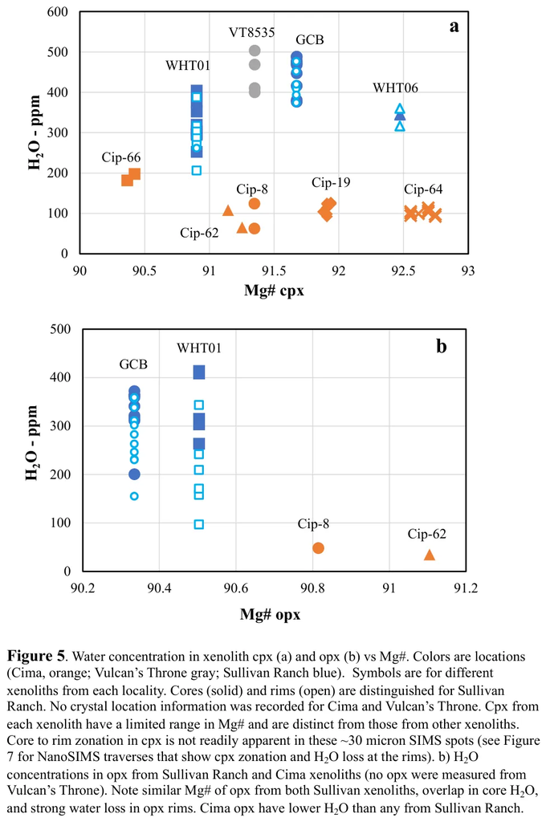

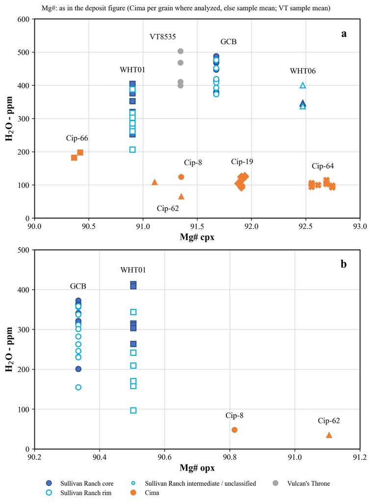

**Figure 5 (Chapter 3).** Left (a): as deposited (2023). Right (b): recompiled from the SIMS dataset and the EMPA table.

## 17.3 Figure 6: pyroxene water across the xenoliths

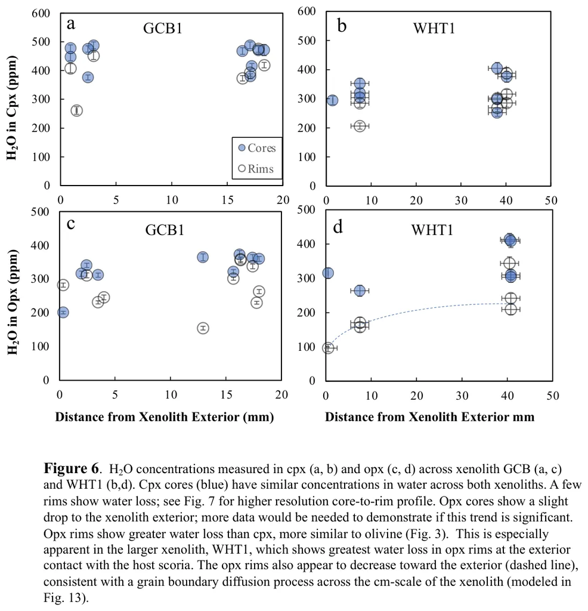

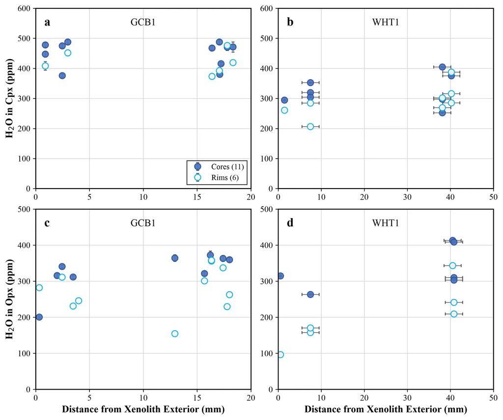

**Figure 6 (Chapter 3).** Left (a): as deposited (2023). Right (b): recompiled from the SIMS dataset.

## 17.4 Figure 7: pyroxene profiles

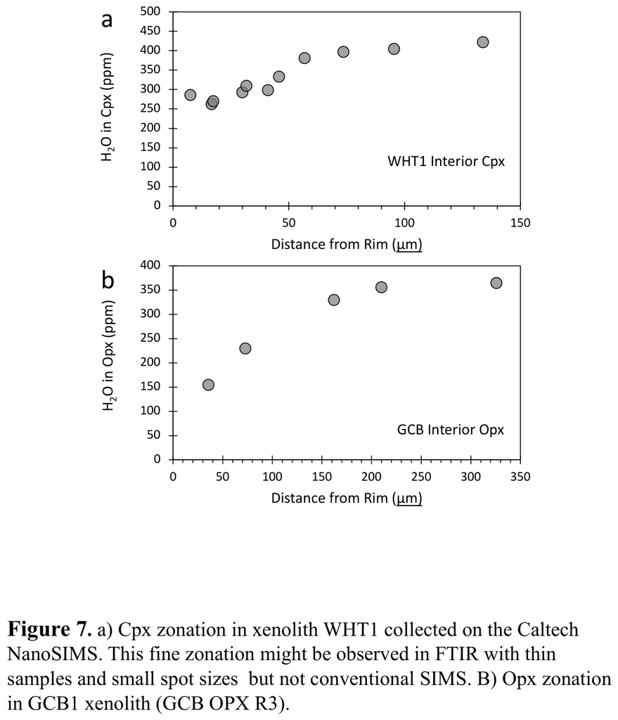

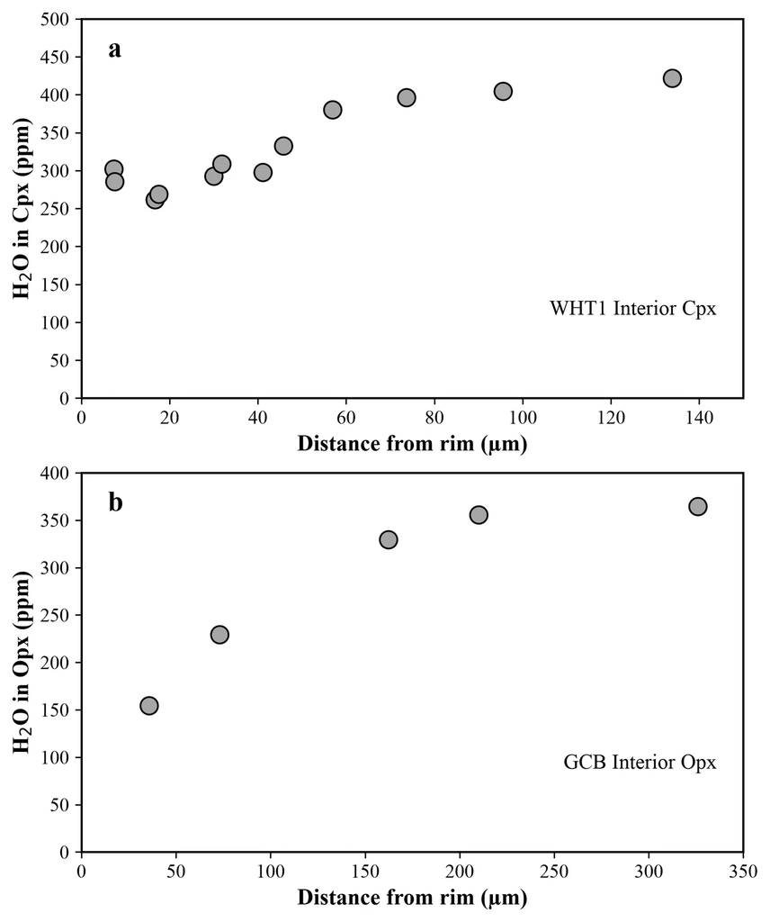

**Figure 7 (Chapter 3).** Left (a): as deposited (2023). Right (b): recompiled from the SIMS dataset.

The deposited file holds two versions of this figure; the final one is shown. The opx profile (b) matches point for point. The cpx profile (a) has 12 analyses; the deposited panel shows 11 (the 7.3 µm replicate, T1-076, is not on it).

## 17.5 Figure 8: melt-inclusion H2O, CO2 and saturation pressure

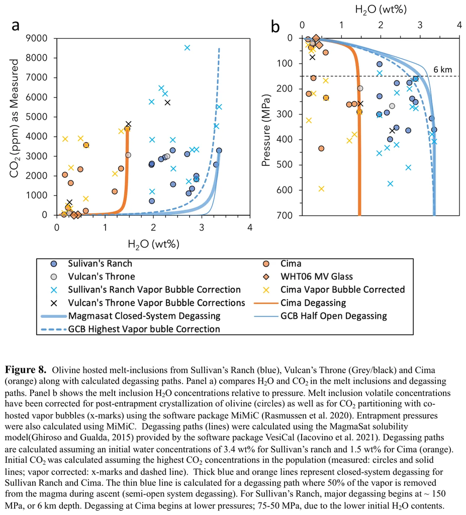

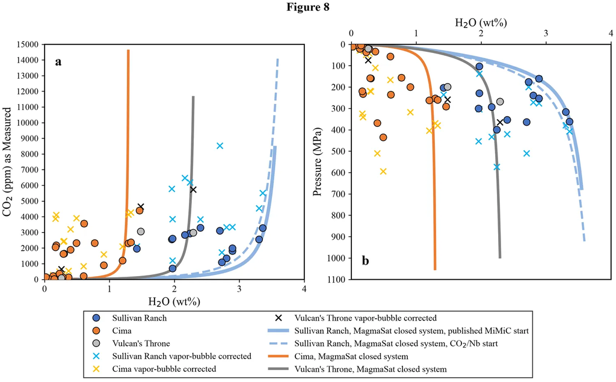

**Figure 8 (Chapter 3).** Left (a): as deposited (2023). Right (b): recompiled from the 2023 melt-inclusion table, with the 2026 degassing paths (MagmaSat, closed system): Sullivan Ranch from the published MiMiC start (solid) and from the CO2/Nb start (dashed), Cima and Vulcan’s Throne.

All 39 inclusion rows are plotted. The 2026 paths start deeper (682-1,057 MPa, 8,500-14,700 ppm CO2) than the deposited axes, so the axes run to 15,000 ppm and 1,100 MPa. Not reproduced: the WHT06 melt-vein glass, the half-open and largest-bubble-correction paths and the 150 MPa (6 km) line, which are not in the compiled data. The 2026 version of this comparison, with the production MiMiC values, is Figure 6.2.

## 17.6 Figure 9: melt-inclusion H2O and S against Cl and SiO2

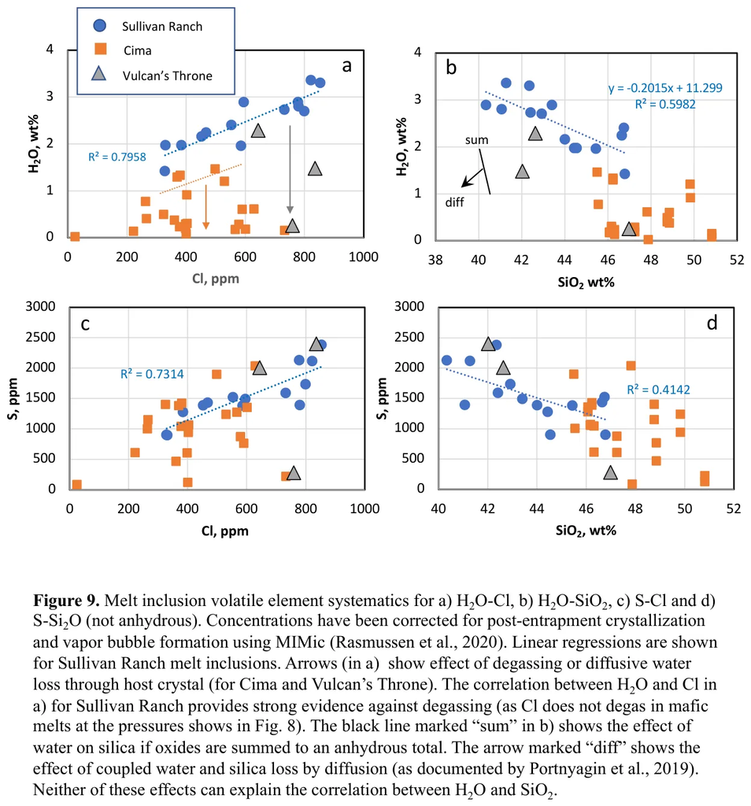

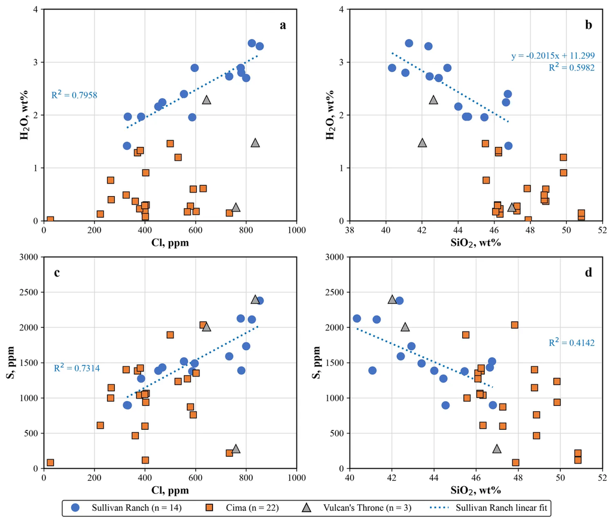

**Figure 9 (Chapter 3).** Left (a): as deposited (2023). Right (b): recompiled from the 2023 melt-inclusion table.

The four printed Sullivan Ranch fits are reproduced exactly from the 14 inclusions (H2O-Cl R² 0.796, H2O-SiO2 R² 0.598, S-Cl R² 0.731, S-SiO2 R² 0.414). The Cima fit line and the hand-drawn arrows are not redrawn.

## 17.7 Figure 11: decompression-rate fits

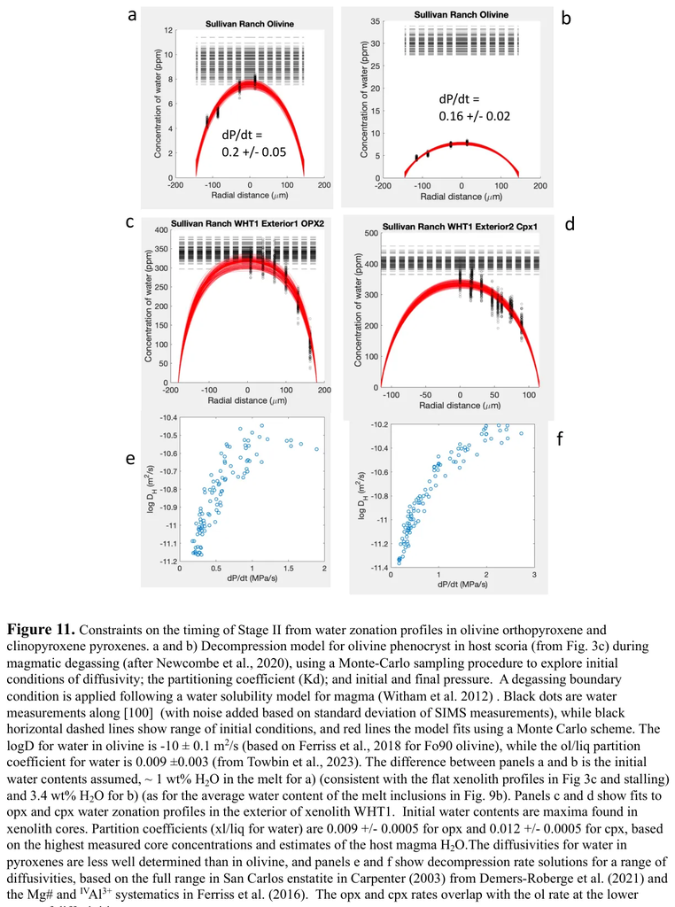

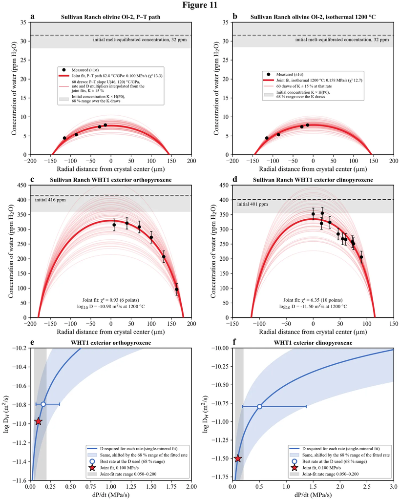

**Figure 11 (Chapter 3).** Left (a): as deposited (2023). Right (b): replica with the 2026 models, published MiMiC start: (a) Ol-2 with the joint fit on the P-T path (0.100 MPa/s at 82.8 °C/GPa; 46 and 120 °C/GPa dashed); (b) Ol-2 isothermal at 1200 °C (0.158 MPa/s); (c, d) WHT1 exterior opx and cpx with the same joint history; (e, f) the pyroxene diffusivity each rate needs (68 % envelope), with the joint fit as a star. Semi-transparent curves are 60 draws with the P-T slope uniform in 46-120 °C/GPa (rate and pyroxene diffusivity following the joint fits at that slope) and the partition coefficient within its prior (15 %); the band at the top is the starting concentration over the same draws (16-84 %).

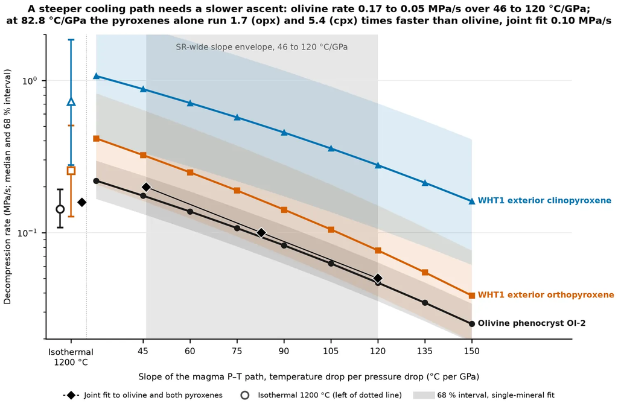

**Figure 11, 2026 form.** Single-mineral rates against the slope of the magma P-T path, with the joint fit.

The deposited panels a and b compared two olivine core assumptions; the 2026 work varies the temperature treatment instead, so a and b show the P-T path and the isothermal fit. The model curves reproduce the joint-fit χ² of every mineral (olivine 13.3, opx 0.93, cpx 6.35). Panels e and f are curves with a 68 % envelope, because the fitted rate scales exactly with the assumed diffusivity. The 2023 fits were isothermal on the 2023 degassing path and diffusivity brackets; the rates are in Chapter 8.

## 17.8 Figure 12: decompression rate against diffusivity

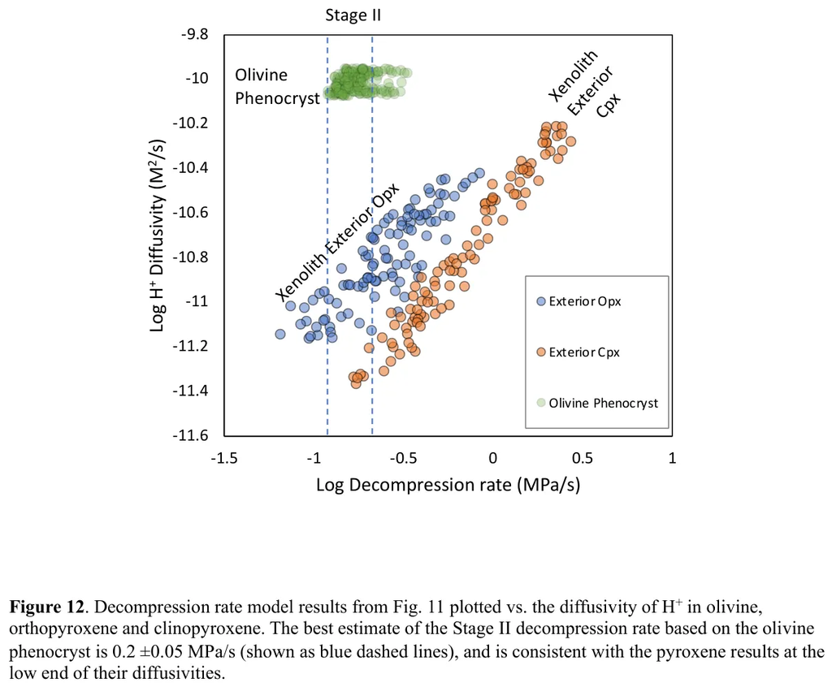

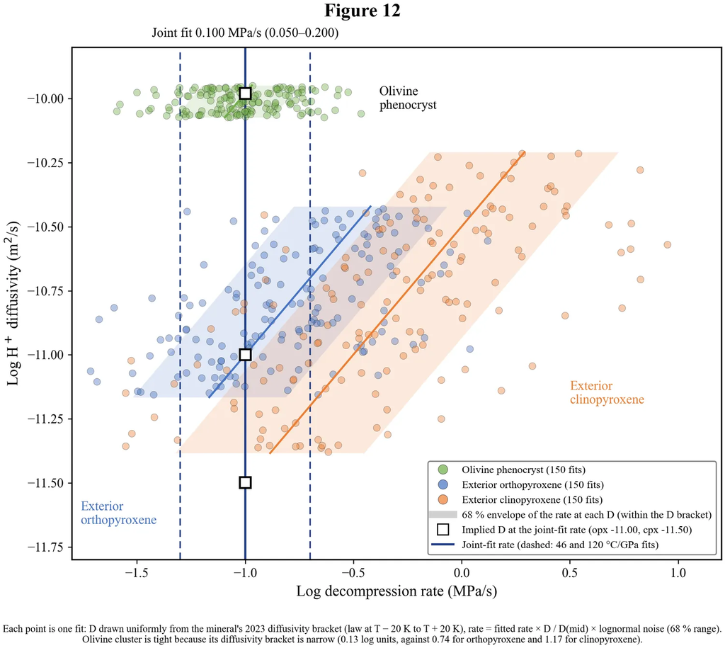

**Figure 12 (Chapter 3).** Left (a): as deposited (2023). Right (b): replica with the 2026 single-mineral fits (published MiMiC start, P-T path): log diffusivity against log decompression rate for olivine, opx and cpx. Each cloud is 150 draws, as in the deposited figure: the diffusivity uniform within the mineral’s diffusivity bracket (the laws at T − 20 K and T + 20 K) and the rate scaled from that mineral’s fit with its 68 % spread; shaded bands are the 68 % envelopes. The joint-fit rate (0.100 MPa/s) and the pyroxene diffusivities it implies (opx −11.00, cpx −11.50) are marked.

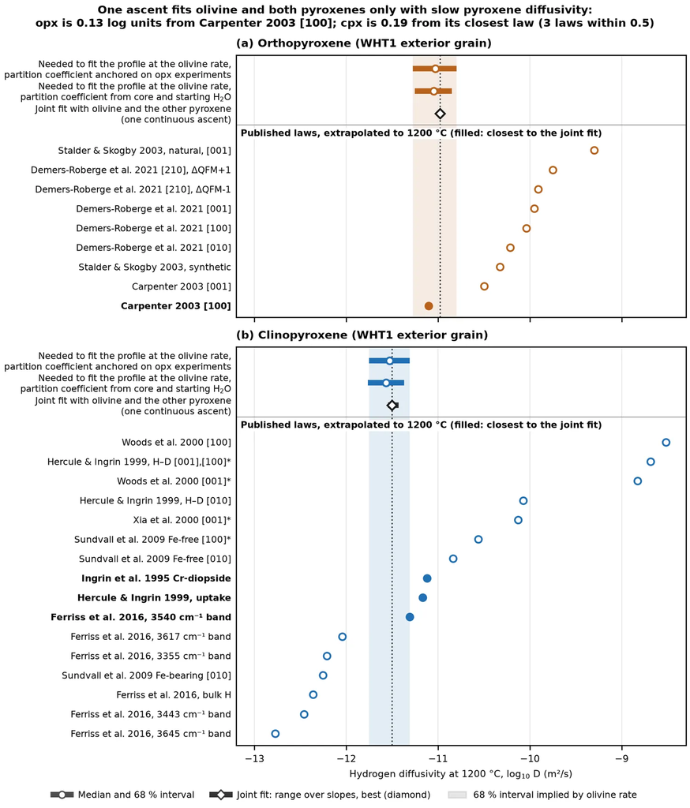

The olivine cloud is tight because its diffusivity bracket is narrow (0.13 log units, against 0.74 for opx and 1.17 for cpx), in 2023 as now. In 2023 each mineral gave its own rate for an assumed diffusivity. In 2026 the joint fit asks which diffusivities let one ascent history fit olivine, opx and cpx together (Chapter 8).

## 17.9 Figure 13: grain-boundary transport across WHT1

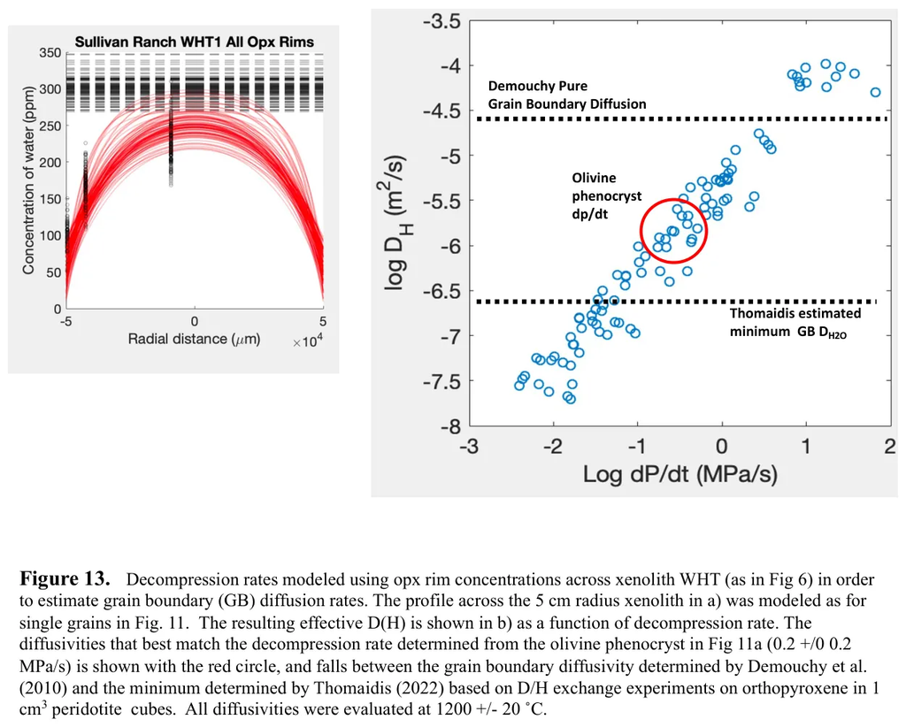

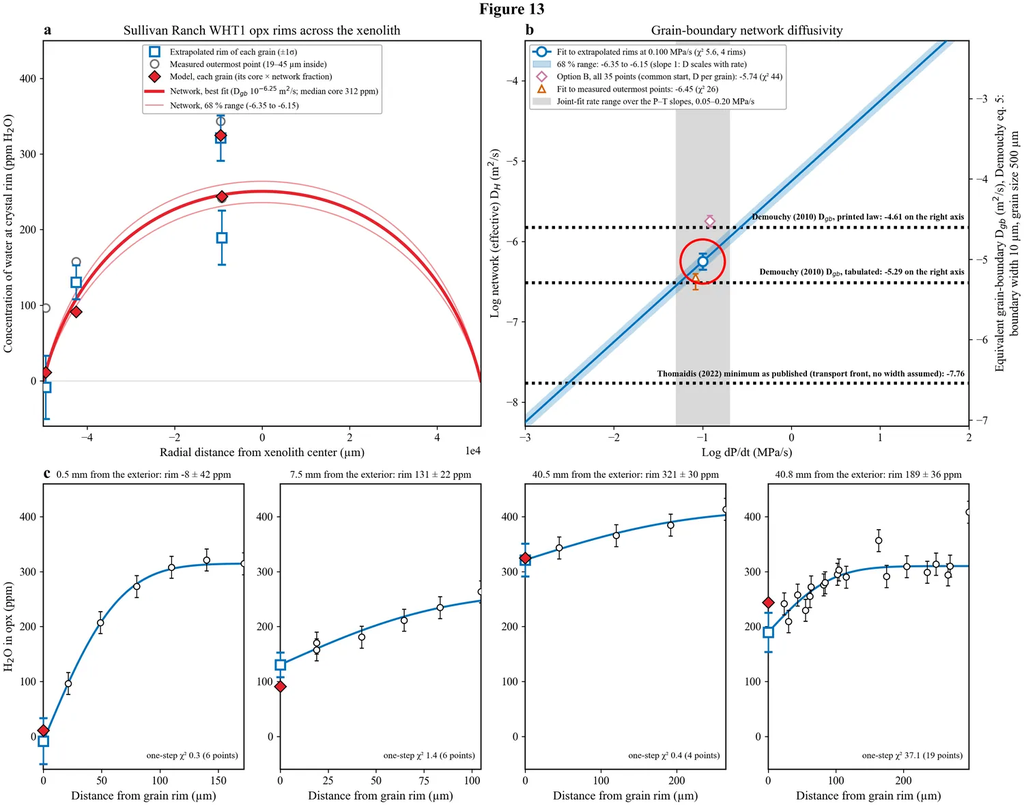

**Figure 13 (Chapter 3).** Left (a): as deposited (2023). Right (b): replica with the 2026 network fitted to each opx grain’s extrapolated rim (published MiMiC start, P–T path 82.8 °C/GPa, 0.100 MPa/s; edge follows the melt): (a) the extrapolated rims (squares, ±1σ), the measured outermost points (circles, 19–45 µm inside the grains) and the network at the end of ascent for the best fit and its 68 % range, scaled to the median opx core (312 ppm); diamonds are each grain’s prediction, its own core times the network’s remaining fraction; (b) the network diffusivity against rate for the two standard fits: the extrapolated rims (log D 10^−6.25, 68 %: −6.35 to −6.15, χ² 5.6 for 4 rims) and option B (all 35 points, one common start, an opx diffusivity per grain: −5.75, −5.81 to −5.68, χ² 44), with the fit to the measured outermost points (−6.45, χ² 26) for comparison, Demouchy et al. (2010) grain-boundary values on a right axis giving the equivalent grain-boundary D from their eq. 5 as the thesis used it (boundary width 10 µm, grain size 500 µm: +1.22 log units), and the Thomaidis (2022) minimum; (c) each grain’s profile with its one-step fit and extrapolated rim.

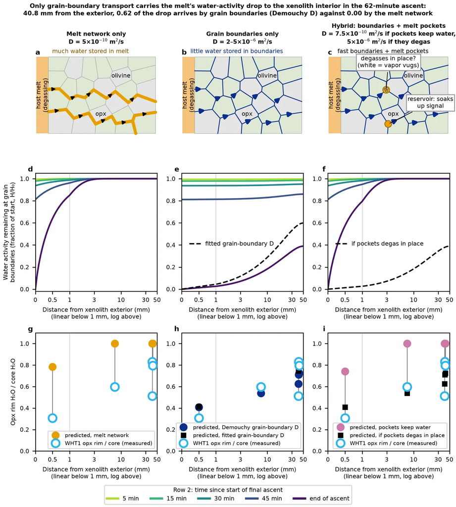

**Figure 13, 2026 form.** Transport mechanisms into the xenolith.

The 2023 test treated the measured outermost points as grain-boundary values; it cannot fit both the 0.5 mm and the 40.8 mm grains (χ² 26 for 4 grains). The replica instead extrapolates each grain’s own profile to its edge (`scripts/decompression/gb_rim_extrapolated.py`: a one-step profile Cb + (C0 − Cb) erf(x/L) with the core C0 held at the grain’s median, ±20 ppm per point), then fits the network to those edges: log D 10^−6.25 (−6.35 to −6.15), χ² 5.6 for 4 rims. Each grain’s prediction is its core (0.5 mm grain 315 ppm, 7.5 mm 264, 40.5 mm 413, 40.8 mm 310) times the network’s remaining fraction. The second standard fit, option B (`scripts/decompression/gb_aniso_halfwidth.py`), models diffusion inside every grain behind the network with one common start (388 ppm, 384–400) and one opx partition coefficient, and gives each grain its own opx diffusivity for anisotropy: 10^−5.75 (−5.81 to −5.68), χ² 43.8 for 35 points (Chapter 8). Per-grain opx log D: 0.5 mm −11.1, 7.5 mm −11.0, 40.5 mm −11.8, 40.8 mm −10.4. The earlier nested fit, each grain starting at its own measured core with one shared opx D, gave 10^−5.6 (χ² 63.3). A one-step profile treats the falling edge as constant, which biases the extrapolated value low, so the two standard fits bracket the network diffusivity.

**The cpx and a fit with every grain** (`scripts/decompression/gb_all_grains.py`, Table 17.1). The same extrapolation works poorly for the WHT1 cpx. The 1.45 mm and 40.2 mm grains show a drop at their outermost point only, so their edges are unconstrained. The 7.5 mm and 38.1 mm traverses scatter (one-step χ² 30 for 14 points and 68 for 11), and the 38.1 mm grain’s points labeled Core (298 ppm) sit below its deeper points (about 400). Where it can be read, the cpx rim drops less than the opx rim at the same depth: at 7.5 mm by 27 % against 50 %. Fitted alone, the cpx rims want a network more than ten times slower (−7.35). A full nested fit with all eight grains puts the cpx diffusivity at 10^−13.1, below every published cpx law at 1200 °C (the slowest is −12.77, Ferriss et al. 2016) and 1.6 log units below the joint fit’s −11.5; two scattered cpx traverses supply 148 of its χ² of 227. The cpx therefore do not add a usable constraint on the network, and Figure 13 uses the opx only.

Table 17.1: The opx alone constrain the network; the cpx rims want a slower network and, in the nested fit, a cpx diffusivity below every published law. Nested ranges within Δχ² = 2.3, extrapolated-rim ranges within Δχ² = 1; σ = 20 ppm per point.

| Fit (MiMiC start, P–T path, 0.100 MPa/s) | log D network (68 %) | log D opx / cpx | χ² (points) |
| --- | --- | --- | --- |
| Extrapolated rims, opx (Figure 13) | −6.25 (−6.35 to −6.15) | n/a | 5.6 (4 rims) |
| Extrapolated rims, cpx | −7.35 (−7.60 to −7.10) | n/a | 0.03 (4 rims, 2 unconstrained) |
| Extrapolated rims, opx + cpx | −6.50 (−6.75 to −6.40) | n/a | 18.5 (8 rims) |
| Nested, opx only | −5.65 (−5.90 to −5.50) | −11.6 / n/a | 63.1 (35) |
| Nested, cpx only | −6.45 (−6.80 to −6.20) | n/a / −12.7 | 154.8 (41) |
| Nested, all grains | −5.85 (−6.00 to −5.65) | −11.5 / −13.1 | 226.6 (76) |

**The cpx under option B, alone and with the opx** (`scripts/decompression/gb_cpx_option_b.py`, Table 17.2, Figure 17.1). Each phase gets one common start (its own absolute partition coefficient) and each grain its own diffusivity; the cpx boundary sees a fraction β of the network’s drop. With β = 1 the cpx fit poorly (χ² 178 for 41 points in the joint fit). With β free the joint opx + cpx fit picks β = 0.5 and a network of 10^−5.6 (χ² 141 for 76 points: cpx 93, opx 48, the opx 3.7 above their own best). Its common starts, 412 ppm for opx and 388 ppm for cpx, match the intact interior cores (411 and 390 ppm) without being told to. The exterior cpx (1.45 and 7.5 mm) and the exterior opx all need log D ≈ −11.0. The interior grains split as the opx do: the 40.2 mm cpx needs −12.6 and the 38.1 mm cpx −11.3. Fitted alone, the cpx cannot separate β from the network diffusivity (β 0.5 with the network at the top of the grid). Most of the remaining cpx misfit is in the scattered 7.5 and 38.1 mm traverses (χ² 33 and 40).

Table 17.2: With the cpx boundary seeing half the network’s drop, one network fits both pyroxenes, and the fitted common starts match the intact interior cores. Diffusivity per grain, half-widths fixed, σ = 20 ppm.

| Fit (option B, MiMiC start, P–T path, 0.100 MPa/s) | β | log D network | Common start, opx / cpx (ppm) | χ² (points) |
| --- | --- | --- | --- | --- |
| cpx alone | 1 | −6.4 | — / 342 | 162.5 (41) |
| cpx alone | 0.5 | −5.0 (grid limit) | — / 408 | 84.4 (41) |
| opx + cpx | 1 | −5.8 | 388 / 342 | 221.6 (76) |
| opx + cpx | 0.5 | −5.6 | 412 / 388 | 141.0 (76) |

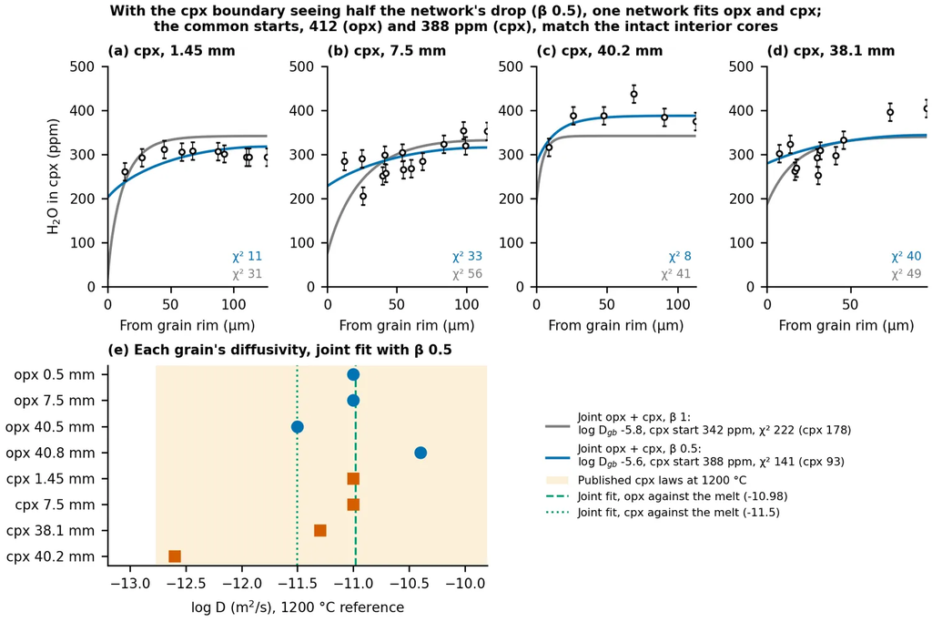

Figure 17.1: With the cpx boundary seeing half the network’s drop, one network fits opx and cpx, and the exterior grains of both phases share log D ≈ −11. (a–d) Each WHT1 cpx traverse with the joint opx + cpx option B fit for β = 1 (grey) and β free (blue, β 0.5). (e) Each grain’s diffusivity in the β-free joint fit, against the joint-fit pyroxene values and the range of published cpx laws at 1200 °C.

Not yet tested (Henry, 2026-10-31): a path-length factor on each grain’s distance to the exterior, which could make the 40.5 mm grain effectively deeper (it lost less than its depth predicts) but cannot explain the 40.8 mm grain (it lost more; docs/OPEN_QUESTIONS.md Q33).

**The 0.5 mm grain’s outermost point is modeled too high (152 against 96 ppm at 21 µm), and the edge value is not the cause.** At the end of ascent the network edge has already fallen to about 5 ppm opx-equivalent (98 % of the melt’s drop). Holding the edge at a floor of 50–100 ppm is allowed by the data (χ² 63.6–66.0 against 63.3; 68 % range of the floor 0–75 ppm) but raises the modeled point to 153–168 ppm. Giving that grain its own opx D does not fix it either (best 10^-11.5, modeled point 142 ppm). Its measured profile (96, 207, 273, 308, 321 ppm from 21 to 140 µm) drops more steeply at the rim than one diffusivity from a 315 ppm start allows. The joint fit’s opx D (10^-11.0) is not comparable, because it starts the grain at the 411 ppm interior cores. Holding the edge at a final pressure or a buffering fraction also converges to the unbuffered edge (best Pf = 0, 68 % 0–10 MPa; best f = 1.0, 0.97–1.0).

**Why the 2026 fit does not reproduce the deposited panel a.** The thesis model (`data/recovered/M14_ModelCode/.../WHT1 All opx Grain Bound/master_script_test.m`) differs in three choices. Table 17.3 reruns it with one choice changed at a time (`scripts/decompression/thesis_gb_repro.py`).

1. It treats the five rims (96, 158, 170, 209, 242 ppm) as the grain-boundary concentration itself, with no diffusion inside the grains. The 2026 nested fit puts each measured point 21–45 µm inside a grain that diffuses slowly.
2. Its edge follows the melt only down to a final pressure Pf drawn from 0–20 MPa, and the run stops there, so the edge ends at K × H(Pf): up to about 90 ppm at 20 MPa. The 2026 edge follows the melt to the surface (about 5 ppm).
3. It leaves out the 40.5 mm grain’s rim (343 ppm), which sits 100–130 ppm above the other two interior rims at the same depth; no one-dimensional slab can fit both.

The degassing path (VesiCal at 1200 °C in the thesis, MiMiC start now) changes nothing.

Table 17.3: The thesis panel is reproduced (rims 95, 145, 241 against 96, 158/170, 209/242) once the rims are treated as grain-boundary values and the edge stops near 20 MPa; the edge stopping at the surface or the 343 ppm rim is what breaks it. Thesis setup (rims as boundary values, K = 90 ppm per wt%, start 6350 bar, isothermal) on the thesis VesiCal path; χ² with σ = 20 ppm.

| Rims fitted | Edge stops at | Edge value (ppm) | Best log D_gb at 0.1 MPa/s | χ² | Modeled rims: 0.5, 7.5, 40.8 mm (ppm) |
| --- | --- | --- | --- | --- | --- |
| Thesis five | 20 MPa (thesis prior’s top) | 91 | −6.2 | 4.6 | 95, 145, 241 |
| Thesis five | 30 MPa | 114 | −6.0 | 3.5 | 117, 151, 224 |
| Thesis five | surface (2026) | 0 | −6.5 | 33.4 | 13, 127, 265 |
| Six (with 343) | 20 MPa | 91 | −6.4 | 24.9 | 97, 158, 262 |
| Six (with 343) | surface | 0 | −6.8 | 43.7 | 19, 158, 287 |

So the 96 ppm exterior rim fits only if the xenolith edge stopped exchanging with the melt at about 20–30 MPa, which leaves the edge at 90–115 ppm; the deposited curves end at 60–100 ppm. The nested fit reads the same rim differently: the edge goes to near zero and the grain lags behind it. That reading cannot reach 96 ppm at 21 µm, and it rejects an edge stopping above about 10 MPa.

**The 0.5 mm grain: two readings.** Every 2026 fit models this grain’s outermost point (96 ppm at 21 µm) too high, the only modeled point well above the data. Two ways to fix it fit about equally well (Table 17.4) and leave the network and opx diffusivities unchanged; Figure 17.2 compares them.

- **A, the rim as the boundary value** (`scripts/decompression/gb_rim_anchor.py`). The 96 ppm point is compared with the network concentration at 0.5 mm at the end of ascent; the grain’s inner points are still modeled behind that boundary. The data then prefer an edge that stops falling at about 100 ppm (68 %: 100–125 ppm), or that sees about 70 % of the melt’s drop: a buffered grain boundary.
- **B, time at a zero edge** (`scripts/decompression/exterior_grain_tests.py`). The grain’s six points form a one-step diffusion profile whose edge is −4 ± 43 ppm (χ² 0.2; ±20 ppm per point); holding that edge at 96 ppm worsens the fit (χ² 7.6) and puts the 21 µm point at 147 ppm. On the melt-controlled history the edge is below 50 ppm for only about 35 s before ascent ends; adding 240 s at a zero edge after ascent (1200 °C reference) fits the grain at the shared opx D. The hold reaches less than 1 mm into the network, so the other grains are unchanged.

Table 17.4: Both readings fit the 0.5 mm grain and leave the diffusivities where they were. Nested fit on the MiMiC start, P–T path 82.8 °C/GPa, 0.100 MPa/s; χ² with σ = 20 ppm. Reading B’s total replaces only that grain’s χ² (the hold was not refit jointly).

| Reading of the 0.5 mm grain | Edge | log D_gb / log D_opx | χ² of that grain | χ² total (35 points) |
| --- | --- | --- | --- | --- |
| Current nested fit | follows the melt to the surface | −5.6 / −11.6 | 11.1 | 63.3 |
| A: rim = boundary | buffered at 100 ppm (100–125) | −5.6 / −11.6 | 3.7 | 53.3 |
| A: rim = boundary | sees 70 % of the melt’s drop | −5.2 / −11.5 | 6.2 | 53.5 |
| B: nested + zero-edge hold | follows the melt, then 240 s at ~0 | −5.6 / −11.6 | 4.6 | about 57 |

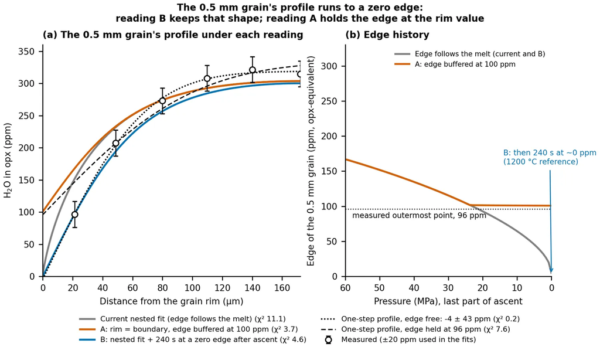

Figure 17.2: The 0.5 mm grain’s profile runs to a zero edge: reading B keeps that shape, while reading A holds the edge at the rim value. (a) The grain’s six SIMS points (±20 ppm, as used in the fits) against the current nested fit, reading A (rim compared with the boundary value, edge buffered at 100 ppm; its modeled profile is the line, its outermost point is scored at the edge), reading B (240 s at a zero edge after ascent), and one-step profiles with the edge free or held at 96 ppm. (b) The edge of that grain over the last 60 MPa of ascent for each reading. MiMiC start, P–T path 82.8 °C/GPa, 0.100 MPa/s, log D_gb −5.6, log D_opx −11.6.

Neither cause is tested yet. Reading A needs a buffer that holds the boundary near 100 ppm: exchange with melt in the veins, or a lag in the network. Reading B needs the grain’s edge to sit near zero for a few minutes at magmatic temperature. That could be hot residence after fragmentation before the bomb quenched (applied consistently, this would also act on the Ol-2 olivine). It could also be a traverse orientation about 0.6 log units faster than the other grains (within published opx anisotropy, e.g. Carpenter 2003 [001] against [100]), or an oblique section that stretches the profile.

## 17.10 Figure 14: time for a cpx to equilibrate with the host

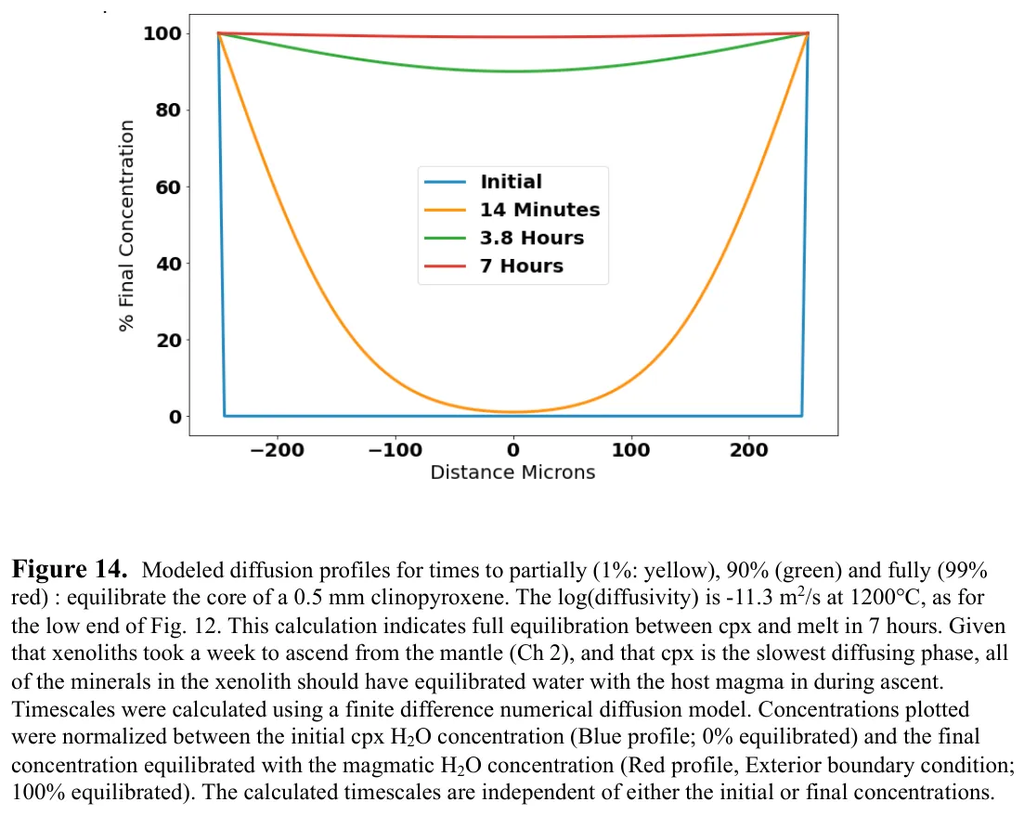

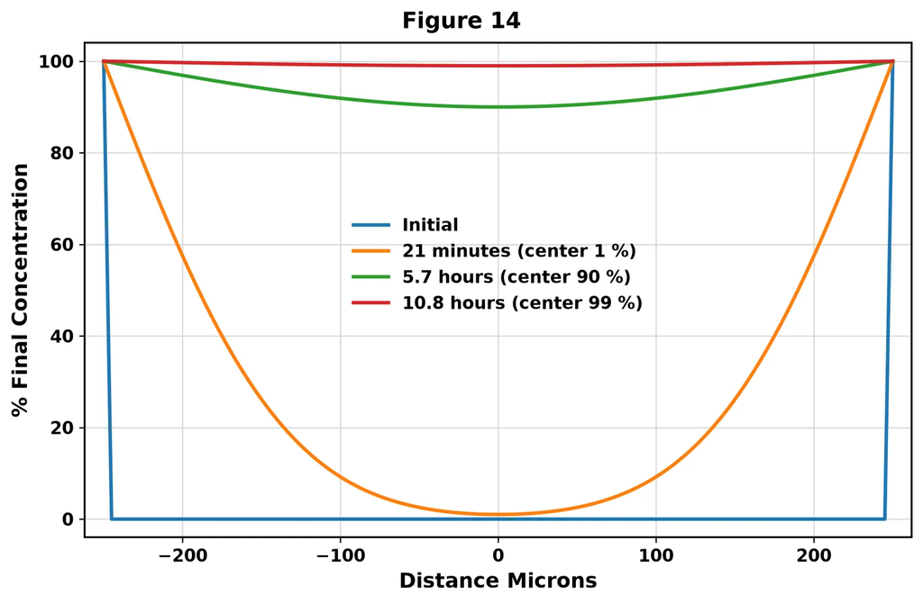

**Figure 14 (Chapter 3).** Left (a): as deposited (2023). Right (b): replica with the 2026 cpx diffusivity (joint fit, log10 D = −11.50 m²/s at 1200 °C), same 500 µm slab and analytic solution.

At the deposited diffusivity (log10 D = −11.3) the same calculation reproduces the deposited times (13 min and 6.8 h against 14 min and 7 h). With the slower 2026 cpx diffusivity the center reaches 1 % of the change in 21 min, 90 % in 5.7 h and 99 % in 10.8 h, about 1.6 times the deposited 7 h. Full equilibration still takes far less than the days of residence in the carrier (Chapter 9).

## 17.11 Figure 15: cpx cores against the host-magma water

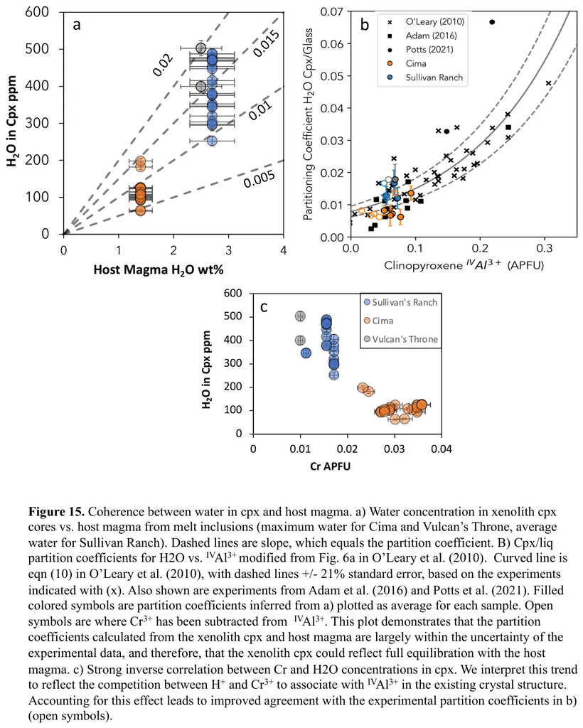

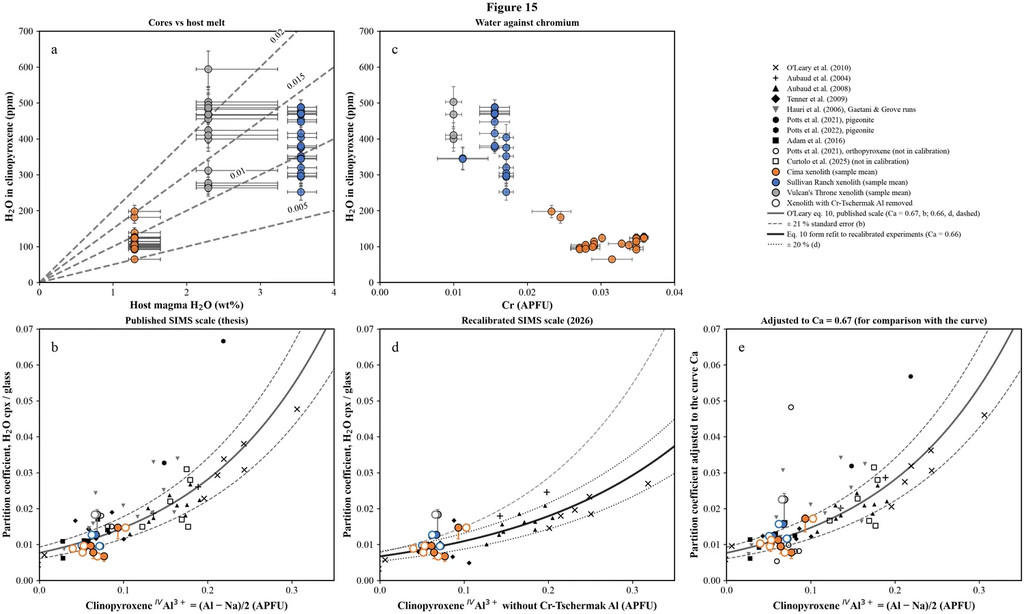

**Figure 15 (Chapter 3).** Left (a): as deposited (2023). Right (b): replica with the 2026 values: (a) cpx cores against the best melt H2O of each volcano (bars: best-estimate range) with lines of constant D; for Vulcan’s Throne and Cima the bar runs up to the soft maximum from literature H2O/Ce (upper value 265; Rasmussen 2017, Rowe 2015, Dixon 2017) times Ce: 3.23 wt% (Vulcan’s Throne, Ce 122 ppm in the olivine-corrected liquid) and 1.64 wt% (Cima, Ce proxy 62 ppm). The Sullivan Ranch inclusions support that range. Their H2O is close to undegassed: the deep CO2-rich vapor removes at most 0.2 wt%. Their H2O/Ce spans 149–416 (main group 149–331, median 215), which covers the literature range and extends above it, so 265 is not an extreme choice. One ratio times whole-rock Ce still does not predict Sullivan Ranch itself (265 × 85 ppm = 2.25 wt%, against 3.55), because there H2O varies with Cl, not Ce; (b) cpx/melt D against tetrahedral Al on the published scale, every study of the deposited panel (O’Leary 2010, Aubaud 2004 and 2008, Tenner 2009, Hauri 2006, Potts 2021 and 2022, Adam 2016; Curtolo 2025 open) with O’Leary eq. 10 at Ca = 0.67 (±21 %); (c) cpx core H2O against Cr (bars: total 1σ and the EMPA Cr standard deviation); (d) the 28 recalibrated experiments with the eq. 10 form refit to them (ln D = −4.19 + 4.92 IVAl − 1.24 Ca, ±20 %); (e) panel b with each D adjusted to the curve’s Ca, D × exp(−1.0 (0.67 − Ca)): adjusted values, for comparison with the curve.

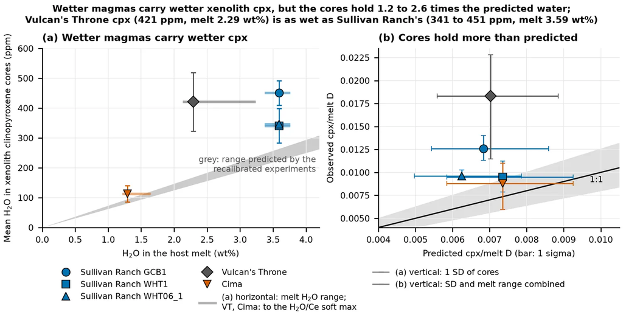

**Figure 15, 2026 form.** Mean cpx cores against melt H2O, and observed against predicted cpx/melt D (Figure 9.3). Bars for Vulcan’s Throne and Cima run to the H2O/Ce soft maximum (see above).

## 17.12 Figure 16: ascent timescales

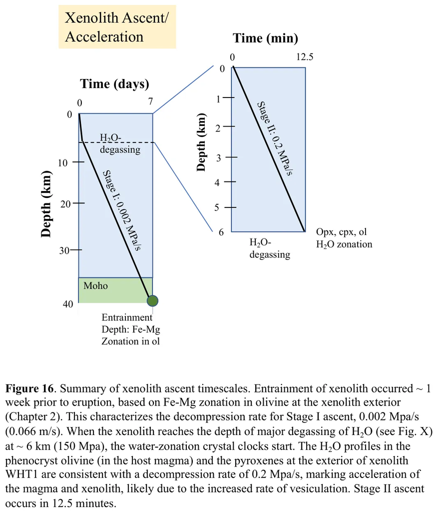

The deposited synthesis set the 2023 rate (about 0.2 MPa/s) against a week-long deep ascent. The 2026 comparison places the Sullivan Ranch rate among published diffusion-derived rates on each study’s own model temperature (Chapter 8).

Sources: `figures/COMPARISON.md` (point-by-point comparison of each recompiled figure), `figures/reference_pages/` (pages of the deposited figure file), `scripts/figures/` (recompiled figures), `scripts/figures/report2026/`.